# ANOVA test for segmentacao

Geiser C. Challco geiser@alumni.usp.br

- ANOVA: segmentacao ~ time
  - Data Preparation
  - Summary Statistics
  - ANOVA Computation
  - PairWise Computation
- ANOVA: segmentacao ~ time*gender + Error(id/time)
  - Data Preparation
    - Check assumptions: Identifying Outliers
    - Check assumptions: Normality Test
    - Summary Statistics
  - ANOVA Computation
  - ANOVA Computation after removing non.normal data
  - PairWise Computation
  - PairWise Computation after removing non.normal data
- ANOVA: segmentacao ~ time*localizacao + Error(id/time)
  - Data Preparation
    - Check assumptions: Identifying Outliers
    - Check assumptions: Normality Test
    - Summary Statistics
  - ANOVA Computation
  - ANOVA Computation after removing non.normal data
  - PairWise Computation
  - PairWise Computation after removing non.normal data
- ANOVA: segmentacao ~ time*regiao + Error(id/time)
  - Data Preparation
    - Check assumptions: Identifying Outliers
    - Check assumptions: Normality Test
    - Summary Statistics
  - ANOVA Computation
  - ANOVA Computation after removing non.normal data
  - PairWise Computation
  - PairWise Computation after removing non.normal data
- ANOVA: segmentacao ~ time*porte + Error(id/time)
  - Data Preparation
    - Check assumptions: Identifying Outliers
    - Check assumptions: Normality Test
    - Summary Statistics
  - ANOVA Computation
  - ANOVA Computation after removing non.normal data
  - PairWise Computation
  - PairWise Computation after removing non.normal data

```r
dat <- read_excel("../data/data.xlsx", sheet = "alunos_ef14")

escolas <- read_excel("../data/data.xlsx", sheet = "escolas")
edat <- merge(dat, escolas, by = "cod_escola", all.x = T)
```

# ANOVA: segmentacao ~ time

## Data Preparation

```r
data <- edat[,c("aluno_id","ciclo","segmentacao")]
data <- data[data$ciclo %in% c("Primeiro Ciclo","Segundo Ciclo","Terceiro Ciclo"),]
data$ciclo <- factor(data$ciclo, c("Primeiro Ciclo","Segundo Ciclo","Terceiro Ciclo"))
data <- unique(data)

wdat <- spread(data, ciclo, segmentacao)
wdat <- wdat[complete.cases(wdat),]
colnames(wdat) <- c("id","c1","c2","c3")

ldat <- gather(wdat, key = time, value = segmentacao, c1,c2,c3) %>%
  convert_as_factor(id, time)
ldat <- rshinystatistics::remove_group_data(ldat, "segmentacao", "time", n.limit = 30)
```

## Summary Statistics

```r
(sdat <- ldat %>% group_by(time) %>%
   get_summary_stats(segmentacao, type = "mean_sd"))
```

```
## # A tibble: 3 × 5
##   time  variable        n  mean    sd
##   <fct> <fct>       <dbl> <dbl> <dbl>
## 1 c1    segmentacao  2773  4.01 0.293
## 2 c2    segmentacao  2773  4.02 0.246
## 3 c3    segmentacao  2773  4.00 0.204
```

| time | variable | n | mean | sd |
| --- | --- | --- | --- | --- |
| c1 | segmentacao | 2773 | 4.013 | 0.293 |
| c2 | segmentacao | 2773 | 4.016 | 0.246 |
| c3 | segmentacao | 2773 | 3.997 | 0.204 |

## ANOVA Computation

```r
(res.aov <- anova_test(ldat, dv = segmentacao, wid = id, within = time))
```

```
## ANOVA Table (type III tests)
##
## $ANOVA
##   Effect DFn  DFd     F     p p<.05   ges
## 1   time   2 5544 5.024 0.007     * 0.001
##
## $`Mauchly's Test for Sphericity`
##   Effect     W                          p p<.05
## 1   time 0.965 0.000000000000000000000218     *
##
## $`Sphericity Corrections`
##   Effect   GGe        DF[GG] p[GG] p[GG]<.05   HFe        DF[HF] p[HF] p[HF]<.05
## 1   time 0.966 1.93, 5354.67 0.007         * 0.967 1.93, 5358.34 0.007         *
```

| Effect | DFn | DFd | F | p | p<.05 | ges |
| --- | --- | --- | --- | --- | --- | --- |
| time | 2 | 5544 | 5.024 | 0.007 | * | 0.001 |

| Effect | W | p | p<.05 |
| --- | --- | --- | --- |
| time | 0.965 | 0 | * |

| Effect | GGe | DF[GG] | p[GG] | p[GG]<.05 | HFe | DF[HF] | p[HF] | p[HF]<.05 |
| --- | --- | --- | --- | --- | --- | --- | --- | --- |
| time | 0.966 | 1.93, 5354.67 | 0.007 | * | 0.967 | 1.93, 5358.34 | 0.007 | * |

## PairWise Computation

```r
(pwc <- ldat %>% emmeans_test(segmentacao ~ time, detailed = T, p.adjust.method = "bonferroni"))
```

```
## # A tibble: 3 × 14
##   term  .y.         group1 group2 null.value estimate      se    df conf.low conf.high statistic       p  p.adj p.adj.signif
## * <chr> <chr>       <chr>  <chr>       <dbl>    <dbl>   <dbl> <dbl>    <dbl>     <dbl>     <dbl>   <dbl>  <dbl> <chr>
## 1 time  segmentacao c1     c2              0 -0.00288 0.00672  8316 -0.0161     0.0103    -0.429 0.668   1      ns
## 2 time  segmentacao c1     c3              0  0.0165  0.00672  8316  0.00335    0.0297     2.46  0.0139  0.0418 *
## 3 time  segmentacao c2     c3              0  0.0194  0.00672  8316  0.00624    0.0326     2.89  0.00388 0.0116 *
```

| term | .y. | group1 | group2 | null.value | estimate | se | df | conf.low | conf.high | statistic | p | p.adj | p.adj.signif |
| --- | --- | --- | --- | --- | --- | --- | --- | --- | --- | --- | --- | --- | --- |
| time | segmentacao | c1 | c2 | 0 | -0.003 | 0.007 | 8316 | -0.016 | 0.010 | -0.429 | 0.668 | 1.000 | ns |
| time | segmentacao | c1 | c3 | 0 | 0.017 | 0.007 | 8316 | 0.003 | 0.030 | 2.459 | 0.014 | 0.042 | * |
| time | segmentacao | c2 | c3 | 0 | 0.019 | 0.007 | 8316 | 0.006 | 0.033 | 2.888 | 0.004 | 0.012 | * |

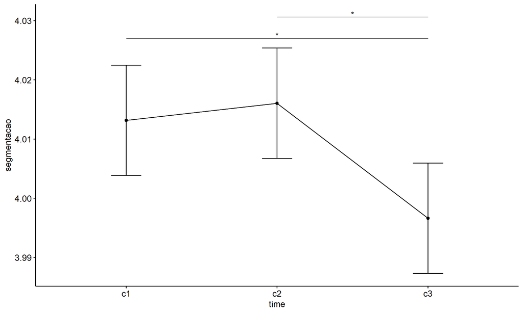

```r
pwc <- add_xy_position(pwc, x = "time", fun = "mean_se")
ggline(get_emmeans(pwc), x = "time", y = "emmean", ylab = "segmentacao") +
  geom_errorbar(aes(ymin = conf.low, ymax = conf.high), width = 0.2) +
  stat_pvalue_manual(pwc, hide.ns = T, tip.length = F)
```

# ANOVA: segmentacao ~ time*gender + Error(id/time)

## Data Preparation

```r
data <- edat[,c("aluno_id","gender","ciclo","segmentacao")]
data <- data[data$ciclo %in% c("Primeiro Ciclo","Segundo Ciclo","Terceiro Ciclo"),]
data$ciclo <- factor(data$ciclo, c("Primeiro Ciclo","Segundo Ciclo","Terceiro Ciclo"))
data <- unique(data)

wdat <- spread(data, ciclo, segmentacao)
wdat <- wdat[complete.cases(wdat),]
colnames(wdat) <- c("id","gender","c1","c2","c3")

ldat <- gather(wdat, key = time, value = segmentacao, c1,c2,c3) %>%
  convert_as_factor(id, time)
ldat <- remove_group_data(ldat, "segmentacao", c("time", "gender"), n.limit = 30)
ldat$gender <- factor(ldat$gender, sort(unique(ldat$gender)))
```

### Check assumptions: Identifying Outliers

```r
outliers <- identify_outliers(group_by(ldat, time, gender), segmentacao)
(outliers <- outliers[outliers$is.extreme == T,])
```

```
## # A tibble: 824 × 6
##    gender time  id                   segmentacao is.outlier is.extreme
##    <fct>  <fct> <fct>                      <dbl> <lgl>      <lgl>
##  1 Female c1    0lMdjGzxsk7DwxFyTSwj         5   TRUE       TRUE
##  2 Female c1    1Ao7d6oeWOGn5CkNSJxn         4.5 TRUE       TRUE
##  3 Female c1    1rGKIQ7fdZBOxxGdPFrp         5   TRUE       TRUE
##  4 Female c1    1yYDJt2kOHTqKvv3pTkn         4.5 TRUE       TRUE
##  5 Female c1    2DvDBlRadL6QdD6eJdDP         5   TRUE       TRUE
##  6 Female c1    2DxCaxzV0AiikIoPOoCv         3   TRUE       TRUE
##  7 Female c1    2J9JedcFZ89AanZm27bY         5   TRUE       TRUE
##  8 Female c1    2JRv4aJX5ZiAWFd1UXo7         3.5 TRUE       TRUE
##  9 Female c1    2qbgEyCWhU8ChVoKwmf5         5   TRUE       TRUE
## 10 Female c1    3uYupr8T88FfksOyXDBI         5   TRUE       TRUE
## # ℹ 814 more rows
```

| gender | time | id | segmentacao | is.outlier | is.extreme |
| --- | --- | --- | --- | --- | --- |
| Female | c1 | 0lMdjGzxsk7DwxFyTSwj | 5.000 | TRUE | TRUE |
| Female | c1 | 1Ao7d6oeWOGn5CkNSJxn | 4.500 | TRUE | TRUE |
| Female | c1 | 1rGKIQ7fdZBOxxGdPFrp | 5.000 | TRUE | TRUE |
| Female | c1 | 1yYDJt2kOHTqKvv3pTkn | 4.500 | TRUE | TRUE |
| Female | c1 | 2DvDBlRadL6QdD6eJdDP | 5.000 | TRUE | TRUE |
| Female | c1 | 2DxCaxzV0AiikIoPOoCv | 3.000 | TRUE | TRUE |
| Female | c1 | 2J9JedcFZ89AanZm27bY | 5.000 | TRUE | TRUE |
| Female | c1 | 2JRv4aJX5ZiAWFd1UXo7 | 3.500 | TRUE | TRUE |
| Female | c1 | 2qbgEyCWhU8ChVoKwmf5 | 5.000 | TRUE | TRUE |
| Female | c1 | 3uYupr8T88FfksOyXDBI | 5.000 | TRUE | TRUE |
| Female | c1 | 45PghDWZsLPMFF4IumMG | 4.500 | TRUE | TRUE |
| Female | c1 | 46nUNvt4sDOPsC9jnkiG | 3.500 | TRUE | TRUE |
| Female | c1 | 4AM4nonwJ45LiMy6b4lp | 4.500 | TRUE | TRUE |
| Female | c1 | 4HW3bQquvKh2NSEqfBcz | 4.500 | TRUE | TRUE |
| Female | c1 | 4tC0rHbjrsSU8gnHaaJ3 | 3.500 | TRUE | TRUE |
| Female | c1 | 4tkeMKZn4I9ZqCsB9HtZ | 4.500 | TRUE | TRUE |
| Female | c1 | 4uGbHDfm5mReIAb5vtDP | 5.000 | TRUE | TRUE |
| Female | c1 | 5AeP0IQ84CerIQVenp2G | 4.500 | TRUE | TRUE |
| Female | c1 | 5aLGVYNAMR84kxneNKFw | 3.000 | TRUE | TRUE |
| Female | c1 | 5QtCqrFr3U8v5JZWaJI1 | 5.000 | TRUE | TRUE |
| Female | c1 | 5WOchSZgUhx0OWTzb7cj | 3.000 | TRUE | TRUE |
| Female | c1 | 6xuH64H6bPGdvHqYeZaQ | 5.000 | TRUE | TRUE |
| Female | c1 | 7gtD7rVOhPW09r7N8pGt | 5.000 | TRUE | TRUE |
| Female | c1 | 7YMayZh0mClXMucg1uN5 | 3.000 | TRUE | TRUE |
| Female | c1 | 8J6zVzXwczhDoIz6ZH9H | 4.500 | TRUE | TRUE |
| Female | c1 | 8sNNEBfY9FXrwwecC4pS | 3.000 | TRUE | TRUE |
| Female | c1 | a5sw5iYN8OPtR8ZDu56L | 3.000 | TRUE | TRUE |
| Female | c1 | AcPM8yalCG1JwgFkGEUa | 5.000 | TRUE | TRUE |
| Female | c1 | aJ6Y4X4FHjiRTSS4hFqt | 5.000 | TRUE | TRUE |
| Female | c1 | aOGxFSPrreKjHqmQIKKA | 4.500 | TRUE | TRUE |

[output cut: 794 more lines]

### Check assumptions: Normality Test

```r
(normality.df <- normality.test.per.groups(ldat, "segmentacao", c("time", "gender")))
```

```
##           var    variable time gender    n   skewness  kurtosis symmetry statistic     method p p.signif normality
## 1 segmentacao segmentacao   c1 Female 1363  0.1696146  7.488230       NO  216.0084 D'Agostino 0     ****         -
## 2 segmentacao segmentacao   c1   Male 1240 -0.2659331  6.356722       NO  186.0147 D'Agostino 0     ****         -
## 3 segmentacao segmentacao   c2 Female 1363  0.7324088 11.437886       NO  368.6593 D'Agostino 0     ****         -
## 4 segmentacao segmentacao   c2   Male 1240  0.4674825 10.074466       NO  270.7199 D'Agostino 0     ****         -
## 5 segmentacao segmentacao   c3 Female 1363 -0.4843705 17.684866       NO  380.0831 D'Agostino 0     ****         -
## 6 segmentacao segmentacao   c3   Male 1240 -0.7650447 13.902908       NO  369.2483 D'Agostino 0     ****         -
```

| var | variable | time | gender | n | skewness | kurtosis | symmetry | statistic | method | p | p.signif | normality |
| --- | --- | --- | --- | --- | --- | --- | --- | --- | --- | --- | --- | --- |
| segmentacao | segmentacao | c1 | Female | 1363 | 0.170 | 7.488 | NO | 216.008 | D’Agostino | 0 | **** | - |
| segmentacao | segmentacao | c1 | Male | 1240 | -0.266 | 6.357 | NO | 186.015 | D’Agostino | 0 | **** | - |
| segmentacao | segmentacao | c2 | Female | 1363 | 0.732 | 11.438 | NO | 368.659 | D’Agostino | 0 | **** | - |
| segmentacao | segmentacao | c2 | Male | 1240 | 0.467 | 10.074 | NO | 270.720 | D’Agostino | 0 | **** | - |
| segmentacao | segmentacao | c3 | Female | 1363 | -0.484 | 17.685 | NO | 380.083 | D’Agostino | 0 | **** | - |
| segmentacao | segmentacao | c3 | Male | 1240 | -0.765 | 13.903 | NO | 369.248 | D’Agostino | 0 | **** | - |

```r
(non.ids <- unique(do.call(
  c, lapply(which(normality.df$normality == 'NO'), FUN = function(i) {
  idx = which(ldat$time == normality.df$time[i] &
                ldat$gender == normality.df$gender[i])
  getNonNormal(ldat$"segmentacao"[idx], ldat$id[idx])
}))))
```

```r
if (length(non.ids) > 0)
  ldat2 <- ldat[!ldat$id %in% non.ids,]
```

### Summary Statistics

```r
(sdat <- ldat %>% group_by(time, gender) %>%
   get_summary_stats(segmentacao, type = "mean_sd"))
```

```
## # A tibble: 6 × 6
##   gender time  variable        n  mean    sd
##   <fct>  <fct> <fct>       <dbl> <dbl> <dbl>
## 1 Female c1    segmentacao  1363  4.02 0.286
## 2 Male   c1    segmentacao  1240  4.00 0.301
## 3 Female c2    segmentacao  1363  4.02 0.234
## 4 Male   c2    segmentacao  1240  4.01 0.257
## 5 Female c3    segmentacao  1363  4.00 0.197
## 6 Male   c3    segmentacao  1240  3.99 0.214
```

| gender | time | variable | n | mean | sd |
| --- | --- | --- | --- | --- | --- |
| Female | c1 | segmentacao | 1363 | 4.023 | 0.286 |
| Male | c1 | segmentacao | 1240 | 4.001 | 0.301 |
| Female | c2 | segmentacao | 1363 | 4.022 | 0.234 |
| Male | c2 | segmentacao | 1240 | 4.012 | 0.257 |
| Female | c3 | segmentacao | 1363 | 4.001 | 0.197 |
| Male | c3 | segmentacao | 1240 | 3.987 | 0.214 |

```r
if (length(non.ids) > 0)
  (sdat <- ldat2 %>% group_by(time, gender) %>%
      get_summary_stats(segmentacao, type = "mean_sd"))
```

| gender | time | variable | n | mean | sd |
| --- | --- | --- | --- | --- | --- |
| Female | c1 | segmentacao | 1363 | 4.023 | 0.286 |
| Male | c1 | segmentacao | 1240 | 4.001 | 0.301 |
| Female | c2 | segmentacao | 1363 | 4.022 | 0.234 |
| Male | c2 | segmentacao | 1240 | 4.012 | 0.257 |
| Female | c3 | segmentacao | 1363 | 4.001 | 0.197 |
| Male | c3 | segmentacao | 1240 | 3.987 | 0.214 |

## ANOVA Computation

```r
(res.aov <- anova_test(ldat, dv = segmentacao, wid = id, between = gender, within = time))
```

```
## ANOVA Table (type III tests)
##
## $ANOVA
##        Effect DFn  DFd     F     p p<.05      ges
## 1      gender   1 2601 6.903 0.009     * 0.000942
## 2        time   2 5202 6.176 0.002     * 0.002000
## 3 gender:time   2 5202 0.451 0.637       0.000112
##
## $`Mauchly's Test for Sphericity`
##        Effect     W                         p p<.05
## 1        time 0.964 0.00000000000000000000213     *
## 2 gender:time 0.964 0.00000000000000000000213     *
##
## $`Sphericity Corrections`
##        Effect   GGe        DF[GG] p[GG] p[GG]<.05   HFe        DF[HF] p[HF] p[HF]<.05
## 1        time 0.965 1.93, 5021.47 0.002         * 0.966 1.93, 5025.13 0.002         *
## 2 gender:time 0.965 1.93, 5021.47 0.630           0.966 1.93, 5025.13 0.630
```

| Effect | DFn | DFd | F | p | p<.05 | ges |
| --- | --- | --- | --- | --- | --- | --- |
| gender | 1 | 2601 | 6.903 | 0.009 | * | 0.001 |
| time | 2 | 5202 | 6.176 | 0.002 | * | 0.002 |
| gender:time | 2 | 5202 | 0.451 | 0.637 |  | 0.000 |

| Effect | W | p | p<.05 |
| --- | --- | --- | --- |
| time | 0.964 | 0 | * |
| gender:time | 0.964 | 0 | * |

| Effect | GGe | DF[GG] | p[GG] | p[GG]<.05 | HFe | DF[HF] | p[HF] | p[HF]<.05 |
| --- | --- | --- | --- | --- | --- | --- | --- | --- |
| time | 0.965 | 1.93, 5021.47 | 0.002 | * | 0.966 | 1.93, 5025.13 | 0.002 | * |
| gender:time | 0.965 | 1.93, 5021.47 | 0.630 |  | 0.966 | 1.93, 5025.13 | 0.630 |  |

## ANOVA Computation after removing non.normal data

```r
if (length(non.ids) > 0)
  (res.aov2 <- anova_test(ldat2, dv = segmentacao, wid = id, between = gender , within = time))
```

## PairWise Computation

```r
(pwc <- ldat %>% group_by(time) %>%
   emmeans_test(segmentacao ~ gender, detailed = T, p.adjust.method = "bonferroni"))
```

```
## # A tibble: 3 × 15
##   time  term   .y.       group1 group2 null.value estimate      se    df conf.low conf.high statistic      p  p.adj p.adj.signif
## * <fct> <chr>  <chr>     <chr>  <chr>       <dbl>    <dbl>   <dbl> <dbl>    <dbl>     <dbl>     <dbl>  <dbl>  <dbl> <chr>
## 1 c1    gender segmenta… Female Male            0   0.0227 0.00983  7803  0.00339    0.0419      2.31 0.0212 0.0212 *
## 2 c2    gender segmenta… Female Male            0   0.0102 0.00983  7803 -0.00910    0.0295      1.03 0.301  0.301  ns
## 3 c3    gender segmenta… Female Male            0   0.0134 0.00983  7803 -0.00592    0.0326      1.36 0.174  0.174  ns
```

| time | term | .y. | group1 | group2 | null.value | estimate | se | df | conf.low | conf.high | statistic | p | p.adj | p.adj.signif |
| --- | --- | --- | --- | --- | --- | --- | --- | --- | --- | --- | --- | --- | --- | --- |
| c1 | gender | segmentacao | Female | Male | 0 | 0.023 | 0.01 | 7803 | 0.003 | 0.042 | 2.305 | 0.021 | 0.021 | * |
| c2 | gender | segmentacao | Female | Male | 0 | 0.010 | 0.01 | 7803 | -0.009 | 0.029 | 1.035 | 0.301 | 0.301 | ns |
| c3 | gender | segmentacao | Female | Male | 0 | 0.013 | 0.01 | 7803 | -0.006 | 0.033 | 1.358 | 0.174 | 0.174 | ns |

```r
(emms <- get_emmeans(pwc))
```

```
## # A tibble: 6 × 8
##   time  gender emmean      se    df conf.low conf.high method
##   <fct> <fct>   <dbl>   <dbl> <dbl>    <dbl>     <dbl> <chr>
## 1 c1    Female   4.02 0.00679  7803     4.01      4.04 Emmeans test
## 2 c1    Male     4.00 0.00712  7803     3.99      4.01 Emmeans test
## 3 c2    Female   4.02 0.00679  7803     4.01      4.04 Emmeans test
## 4 c2    Male     4.01 0.00712  7803     4.00      4.03 Emmeans test
## 5 c3    Female   4.00 0.00679  7803     3.99      4.01 Emmeans test
## 6 c3    Male     3.99 0.00712  7803     3.97      4.00 Emmeans test
```

| time | gender | emmean | se | df | conf.low | conf.high | method |
| --- | --- | --- | --- | --- | --- | --- | --- |
| c1 | Female | 4.023 | 0.007 | 7803 | 4.010 | 4.037 | Emmeans test |
| c1 | Male | 4.001 | 0.007 | 7803 | 3.987 | 4.015 | Emmeans test |
| c2 | Female | 4.022 | 0.007 | 7803 | 4.009 | 4.035 | Emmeans test |
| c2 | Male | 4.012 | 0.007 | 7803 | 3.998 | 4.026 | Emmeans test |
| c3 | Female | 4.001 | 0.007 | 7803 | 3.988 | 4.014 | Emmeans test |
| c3 | Male | 3.988 | 0.007 | 7803 | 3.974 | 4.001 | Emmeans test |

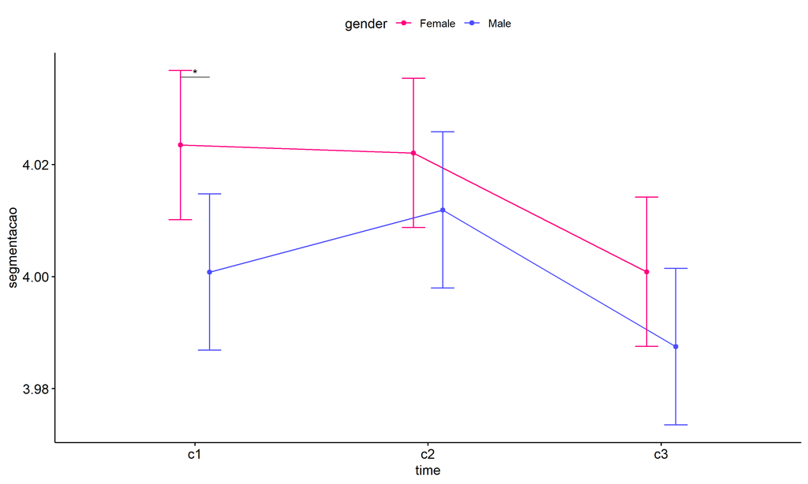

```r
pwc <- add_xy_position(pwc, x = "time", fun = "mean_se", dodge = 0.25)
pd <- position_dodge(width = 0.25)
ggline(emms, x = "time", y = "emmean", color = "gender",
       palette = c("#FF007F","#4D4DFF"),
       position = pd, ylab = "segmentacao") +
  geom_errorbar(aes(ymin = conf.low, ymax = conf.high, color = gender),
                position = pd, width = 0.2) +
  stat_pvalue_manual(pwc, hide.ns = T, tip.length = F, linetype = 1)
```

```r
(pwc <- ldat %>% group_by(gender) %>%
    emmeans_test(segmentacao ~ time, detailed = T, p.adjust.method = "bonferroni"))
```

```
## # A tibble: 6 × 15
##   gender term  .y.       group1 group2 null.value estimate      se    df conf.low conf.high statistic      p  p.adj p.adj.signif
## * <fct>  <chr> <chr>     <chr>  <chr>       <dbl>    <dbl>   <dbl> <dbl>    <dbl>     <dbl>     <dbl>  <dbl>  <dbl> <chr>
## 1 Female time  segmenta… c1     c2              0  0.00141 0.00960  7803 -0.0174    0.0202      0.147 0.884  1      ns
## 2 Female time  segmenta… c1     c3              0  0.0226  0.00960  7803  0.00381   0.0414      2.36  0.0185 0.0554 ns
## 3 Female time  segmenta… c2     c3              0  0.0212  0.00960  7803  0.00240   0.0400      2.21  0.0271 0.0813 ns
## 4 Male   time  segmenta… c1     c2              0 -0.0111  0.0101   7803 -0.0308    0.00864    -1.10  0.271  0.812  ns
## 5 Male   time  segmenta… c1     c3              0  0.0133  0.0101   7803 -0.00642   0.0330      1.32  0.186  0.558  ns
## 6 Male   time  segmenta… c2     c3              0  0.0244  0.0101   7803  0.00467   0.0441      2.42  0.0154 0.0461 *
```

| gender | term | .y. | group1 | group2 | null.value | estimate | se | df | conf.low | conf.high | statistic | p | p.adj | p.adj.signif |
| --- | --- | --- | --- | --- | --- | --- | --- | --- | --- | --- | --- | --- | --- | --- |
| Female | time | segmentacao | c1 | c2 | 0 | 0.001 | 0.01 | 7803 | -0.017 | 0.020 | 0.147 | 0.884 | 1.000 | ns |
| Female | time | segmentacao | c1 | c3 | 0 | 0.023 | 0.01 | 7803 | 0.004 | 0.041 | 2.357 | 0.018 | 0.055 | ns |
| Female | time | segmentacao | c2 | c3 | 0 | 0.021 | 0.01 | 7803 | 0.002 | 0.040 | 2.210 | 0.027 | 0.081 | ns |
| Male | time | segmentacao | c1 | c2 | 0 | -0.011 | 0.01 | 7803 | -0.031 | 0.009 | -1.102 | 0.271 | 0.812 | ns |
| Male | time | segmentacao | c1 | c3 | 0 | 0.013 | 0.01 | 7803 | -0.006 | 0.033 | 1.322 | 0.186 | 0.558 | ns |
| Male | time | segmentacao | c2 | c3 | 0 | 0.024 | 0.01 | 7803 | 0.005 | 0.044 | 2.424 | 0.015 | 0.046 | * |

```r
(emms <- get_emmeans(pwc))
```

```
## # A tibble: 6 × 8
##   gender time  emmean      se    df conf.low conf.high method
##   <fct>  <fct>  <dbl>   <dbl> <dbl>    <dbl>     <dbl> <chr>
## 1 Female c1      4.02 0.00679  7803     4.01      4.04 Emmeans test
## 2 Female c2      4.02 0.00679  7803     4.01      4.04 Emmeans test
## 3 Female c3      4.00 0.00679  7803     3.99      4.01 Emmeans test
## 4 Male   c1      4.00 0.00712  7803     3.99      4.01 Emmeans test
## 5 Male   c2      4.01 0.00712  7803     4.00      4.03 Emmeans test
## 6 Male   c3      3.99 0.00712  7803     3.97      4.00 Emmeans test
```

| gender | time | emmean | se | df | conf.low | conf.high | method |
| --- | --- | --- | --- | --- | --- | --- | --- |
| Female | c1 | 4.023 | 0.007 | 7803 | 4.010 | 4.037 | Emmeans test |
| Female | c2 | 4.022 | 0.007 | 7803 | 4.009 | 4.035 | Emmeans test |
| Female | c3 | 4.001 | 0.007 | 7803 | 3.988 | 4.014 | Emmeans test |
| Male | c1 | 4.001 | 0.007 | 7803 | 3.987 | 4.015 | Emmeans test |
| Male | c2 | 4.012 | 0.007 | 7803 | 3.998 | 4.026 | Emmeans test |
| Male | c3 | 3.988 | 0.007 | 7803 | 3.974 | 4.001 | Emmeans test |

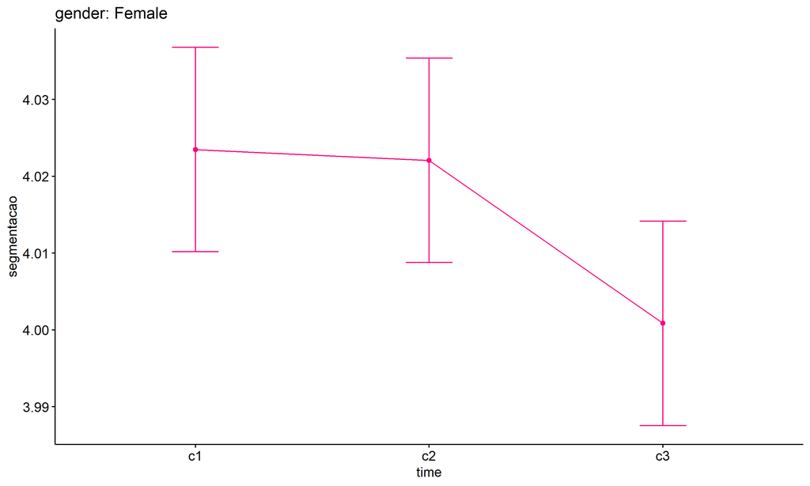

```r
emms.gg <- emms[which(emms$gender == "Female"),]
if (nrow(emms.gg) > 0)
  ggline(emms.gg, x = "time", y = "emmean", color = "#FF007F", ylab = "segmentacao") +
    geom_errorbar(aes(ymin = conf.low, ymax = conf.high),
                  width = 0.2, color = "#FF007F") +
    stat_pvalue_manual(
      add_xy_position(pwc[which(pwc$gender == "Female"),],
                      x = "time", fun = "mean_se"),
      hide.ns = T, color = "#FF007F", tip.length = F) +
    labs(title = "gender: Female")+
    theme(legend.text = element_blank())
```

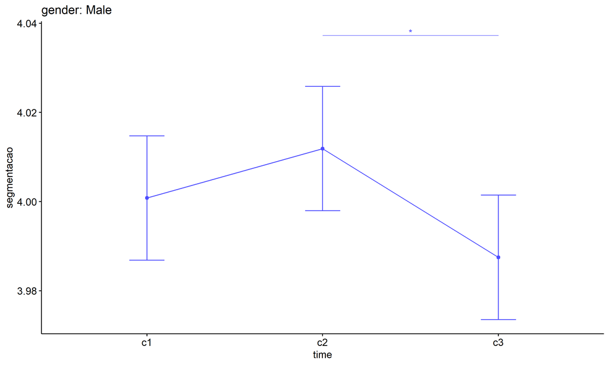

```r
emms.gg <- emms[which(emms$gender == "Male"),]
if (nrow(emms.gg) > 0)
  ggline(emms.gg, x = "time", y = "emmean", color = "#4D4DFF", ylab = "segmentacao") +
    geom_errorbar(aes(ymin = conf.low, ymax = conf.high),
                  width = 0.2, color = "#4D4DFF") +
    stat_pvalue_manual(
      add_xy_position(pwc[which(pwc$gender == "Male"),],
                      x = "time", fun = "mean_se"),
      hide.ns = T, color = "#4D4DFF", tip.length = F) +
    labs(title = "gender: Male")+
    theme(legend.text = element_blank())
```

## PairWise Computation after removing non.normal data

```r
if (length(non.ids) > 0)
  (pwc2 <- ldat2 %>% group_by(time) %>%
     emmeans_test(segmentacao ~ gender, detailed = T, p.adjust.method = "bonferroni"))
```

```r
if (length(non.ids) > 0)
  (emms2 <- get_emmeans(pwc2))
```

```r
if (length(non.ids) > 0) {
  pwc2 <- add_xy_position(pwc2, x = "time", fun = "mean_se", dodge = 0.25)
  pd2 <- position_dodge(width = 0.25)

  ggline(emms2, x = "time", y = "emmean", color = "gender",
         palette = c("#FF007F","#4D4DFF"),
         position = pd, ylab = "segmentacao") +
    geom_errorbar(aes(ymin = conf.low, ymax = conf.high, color = gender),
                position = pd, width = 0.2) +
    stat_pvalue_manual(pwc2, hide.ns = T, tip.length = F, linetype = 1)
}
```

```r
if (length(non.ids) > 0)
  (pwc2 <- ldat2 %>% group_by(gender) %>%
     emmeans_test(segmentacao ~ time, detailed = T, p.adjust.method = "bonferroni"))
```

```r
if (length(non.ids) > 0)
  (emms2 <- get_emmeans(pwc2))
```

```r
if (length(non.ids) > 0) {
  emms.gg <- emms2[which(emms2$gender == "Female"),]
  if (nrow(emms.gg) > 0)
    ggline(emms.gg, x = "time", y = "emmean", color = "#FF007F", ylab = "segmentacao") +
    geom_errorbar(aes(ymin = conf.low, ymax = conf.high),
                  width = 0.2, color = "#FF007F") +
    stat_pvalue_manual(
      add_xy_position(pwc[which(pwc$gender == "Female"),],
                      x = "time", fun = "mean_se"),
      hide.ns = T, color = "#FF007F", tip.length = F) +
    labs(title = "gender: Female") +
    theme(legend.text = element_blank())
}
```

```r
if (length(non.ids) > 0) {
  emms.gg <- emms2[which(emms2$gender == "Male"),]
  if (nrow(emms.gg) > 0)
    ggline(emms.gg, x = "time", y = "emmean", color = "#4D4DFF", ylab = "segmentacao") +
    geom_errorbar(aes(ymin = conf.low, ymax = conf.high),
                  width = 0.2, color = "#4D4DFF") +
    stat_pvalue_manual(
      add_xy_position(pwc[which(pwc$gender == "Male"),],
                      x = "time", fun = "mean_se"),
      hide.ns = T, color = "#4D4DFF", tip.length = F) +
    labs(title = "gender: Male") +
    theme(legend.text = element_blank())
}
```

# ANOVA: segmentacao ~ time*localizacao + Error(id/time)

## Data Preparation

```r
data <- edat[,c("aluno_id","localizacao","ciclo","segmentacao")]
data <- data[data$ciclo %in% c("Primeiro Ciclo","Segundo Ciclo","Terceiro Ciclo"),]
data$ciclo <- factor(data$ciclo, c("Primeiro Ciclo","Segundo Ciclo","Terceiro Ciclo"))
data <- unique(data)

wdat <- spread(data, ciclo, segmentacao)
wdat <- wdat[complete.cases(wdat),]
colnames(wdat) <- c("id","localizacao","c1","c2","c3")

ldat <- gather(wdat, key = time, value = segmentacao, c1,c2,c3) %>%
  convert_as_factor(id, time)
ldat <- remove_group_data(ldat, "segmentacao", c("time", "localizacao"), n.limit = 30)
ldat$localizacao <- factor(ldat$localizacao, sort(unique(ldat$localizacao)))
```

### Check assumptions: Identifying Outliers

```r
outliers <- identify_outliers(group_by(ldat, time, localizacao), segmentacao)
(outliers <- outliers[outliers$is.extreme == T,])
```

```
## # A tibble: 871 × 6
##    localizacao time  id                   segmentacao is.outlier is.extreme
##    <fct>       <fct> <fct>                      <dbl> <lgl>      <lgl>
##  1 Rural       c1    1Ao7d6oeWOGn5CkNSJxn         4.5 TRUE       TRUE
##  2 Rural       c1    2J9JedcFZ89AanZm27bY         5   TRUE       TRUE
##  3 Rural       c1    2wBgWJVF1mK6rnsBiZ99         3   TRUE       TRUE
##  4 Rural       c1    3Mz5zcTWFm69K4uSHzbM         3   TRUE       TRUE
##  5 Rural       c1    45PghDWZsLPMFF4IumMG         4.5 TRUE       TRUE
##  6 Rural       c1    47982aWE9x4sBhPIFY0I         3   TRUE       TRUE
##  7 Rural       c1    4IlR2rfPre42Z5XA3t90         3   TRUE       TRUE
##  8 Rural       c1    5QtCqrFr3U8v5JZWaJI1         5   TRUE       TRUE
##  9 Rural       c1    7AsCrRYMyhVRQHX4kZdc         3   TRUE       TRUE
## 10 Rural       c1    8sNNEBfY9FXrwwecC4pS         3   TRUE       TRUE
## # ℹ 861 more rows
```

| localizacao | time | id | segmentacao | is.outlier | is.extreme |
| --- | --- | --- | --- | --- | --- |
| Rural | c1 | 1Ao7d6oeWOGn5CkNSJxn | 4.500 | TRUE | TRUE |
| Rural | c1 | 2J9JedcFZ89AanZm27bY | 5.000 | TRUE | TRUE |
| Rural | c1 | 2wBgWJVF1mK6rnsBiZ99 | 3.000 | TRUE | TRUE |
| Rural | c1 | 3Mz5zcTWFm69K4uSHzbM | 3.000 | TRUE | TRUE |
| Rural | c1 | 45PghDWZsLPMFF4IumMG | 4.500 | TRUE | TRUE |
| Rural | c1 | 47982aWE9x4sBhPIFY0I | 3.000 | TRUE | TRUE |
| Rural | c1 | 4IlR2rfPre42Z5XA3t90 | 3.000 | TRUE | TRUE |
| Rural | c1 | 5QtCqrFr3U8v5JZWaJI1 | 5.000 | TRUE | TRUE |
| Rural | c1 | 7AsCrRYMyhVRQHX4kZdc | 3.000 | TRUE | TRUE |
| Rural | c1 | 8sNNEBfY9FXrwwecC4pS | 3.000 | TRUE | TRUE |
| Rural | c1 | 9Xwyihw9e1060vCTC4vd | 4.500 | TRUE | TRUE |
| Rural | c1 | a5sw5iYN8OPtR8ZDu56L | 3.000 | TRUE | TRUE |
| Rural | c1 | aONYcyIz9jdWo9UGBKG0 | 5.000 | TRUE | TRUE |
| Rural | c1 | AyZ6yHnjXfeT5KinmIxC | 4.500 | TRUE | TRUE |
| Rural | c1 | BcQGlB6ZORM7EMpuhJEB | 3.000 | TRUE | TRUE |
| Rural | c1 | bkSG2ELC7LzImsiQ1CtG | 4.500 | TRUE | TRUE |
| Rural | c1 | CBjbMGhWFUocJQM5DDq9 | 3.000 | TRUE | TRUE |
| Rural | c1 | ccet9e00qRV3dmuDE6n5 | 4.500 | TRUE | TRUE |
| Rural | c1 | D3zCmRj97N1xSw2RGyIX | 4.500 | TRUE | TRUE |
| Rural | c1 | dXqscP5m7ztZm54TXJDJ | 5.000 | TRUE | TRUE |
| Rural | c1 | ETyWmmt6JYMQVyYo8Byu | 3.000 | TRUE | TRUE |
| Rural | c1 | eZv0l7xLjFTyM8DBKWXs | 3.000 | TRUE | TRUE |
| Rural | c1 | fETGhIde8enSW1EPqWMS | 3.000 | TRUE | TRUE |
| Rural | c1 | frOYRQ1Z4xGe172raTPv | 5.000 | TRUE | TRUE |
| Rural | c1 | GRXCU0bF6TElSKj1QNCL | 4.500 | TRUE | TRUE |
| Rural | c1 | HlYt1MeazKgOy2zfPN5n | 4.500 | TRUE | TRUE |
| Rural | c1 | hruSgzhJbTGT2UHE0CPK | 4.500 | TRUE | TRUE |
| Rural | c1 | hUdYnYUAHQZnpWcANrgG | 5.000 | TRUE | TRUE |
| Rural | c1 | ifbY0Qn05cb73G89bxbW | 4.500 | TRUE | TRUE |
| Rural | c1 | iHdUtQKKo3HR4GIuXQh9 | 4.500 | TRUE | TRUE |

[output cut: 841 more lines]

### Check assumptions: Normality Test

```r
(normality.df <- normality.test.per.groups(ldat, "segmentacao", c("time", "localizacao")))
```

```
##           var    variable time localizacao    n   skewness  kurtosis symmetry statistic     method p p.signif normality
## 1 segmentacao segmentacao   c1       Rural  656 -0.3164420  8.571087       NO  126.6560 D'Agostino 0     ****         -
## 2 segmentacao segmentacao   c1      Urbana 2117  0.0178853  6.550070       NO  292.1938 D'Agostino 0     ****         -
## 3 segmentacao segmentacao   c2       Rural  656  0.1132292 10.318649       NO  130.5729 D'Agostino 0     ****         -
## 4 segmentacao segmentacao   c2      Urbana 2117  0.6626859 10.955369       NO  530.6413 D'Agostino 0     ****         -
## 5 segmentacao segmentacao   c3       Rural  656 -0.8972107 17.100558       NO  234.0589 D'Agostino 0     ****         -
## 6 segmentacao segmentacao   c3      Urbana 2117 -0.2891220 15.689347       NO  507.2206 D'Agostino 0     ****         -
```

| var | variable | time | localizacao | n | skewness | kurtosis | symmetry | statistic | method | p | p.signif | normality |
| --- | --- | --- | --- | --- | --- | --- | --- | --- | --- | --- | --- | --- |
| segmentacao | segmentacao | c1 | Rural | 656 | -0.316 | 8.571 | NO | 126.656 | D’Agostino | 0 | **** | - |
| segmentacao | segmentacao | c1 | Urbana | 2117 | 0.018 | 6.550 | NO | 292.194 | D’Agostino | 0 | **** | - |
| segmentacao | segmentacao | c2 | Rural | 656 | 0.113 | 10.319 | NO | 130.573 | D’Agostino | 0 | **** | - |
| segmentacao | segmentacao | c2 | Urbana | 2117 | 0.663 | 10.955 | NO | 530.641 | D’Agostino | 0 | **** | - |
| segmentacao | segmentacao | c3 | Rural | 656 | -0.897 | 17.101 | NO | 234.059 | D’Agostino | 0 | **** | - |
| segmentacao | segmentacao | c3 | Urbana | 2117 | -0.289 | 15.689 | NO | 507.221 | D’Agostino | 0 | **** | - |

```r
(non.ids <- unique(do.call(
  c, lapply(which(normality.df$normality == 'NO'), FUN = function(i) {
  idx = which(ldat$time == normality.df$time[i] &
                ldat$localizacao == normality.df$localizacao[i])
  getNonNormal(ldat$"segmentacao"[idx], ldat$id[idx])
}))))
```

```r
if (length(non.ids) > 0)
  ldat2 <- ldat[!ldat$id %in% non.ids,]
```

### Summary Statistics

```r
(sdat <- ldat %>% group_by(time, localizacao) %>%
   get_summary_stats(segmentacao, type = "mean_sd"))
```

```
## # A tibble: 6 × 6
##   localizacao time  variable        n  mean    sd
##   <fct>       <fct> <fct>       <dbl> <dbl> <dbl>
## 1 Rural       c1    segmentacao   656  4.01 0.276
## 2 Urbana      c1    segmentacao  2117  4.01 0.298
## 3 Rural       c2    segmentacao   656  4.01 0.248
## 4 Urbana      c2    segmentacao  2117  4.02 0.245
## 5 Rural       c3    segmentacao   656  3.99 0.203
## 6 Urbana      c3    segmentacao  2117  4    0.205
```

| localizacao | time | variable | n | mean | sd |
| --- | --- | --- | --- | --- | --- |
| Rural | c1 | segmentacao | 656 | 4.009 | 0.276 |
| Urbana | c1 | segmentacao | 2117 | 4.014 | 0.298 |
| Rural | c2 | segmentacao | 656 | 4.009 | 0.248 |
| Urbana | c2 | segmentacao | 2117 | 4.018 | 0.245 |
| Rural | c3 | segmentacao | 656 | 3.986 | 0.203 |
| Urbana | c3 | segmentacao | 2117 | 4.000 | 0.205 |

```r
if (length(non.ids) > 0)
  (sdat <- ldat2 %>% group_by(time, localizacao) %>%
      get_summary_stats(segmentacao, type = "mean_sd"))
```

| localizacao | time | variable | n | mean | sd |
| --- | --- | --- | --- | --- | --- |
| Rural | c1 | segmentacao | 656 | 4.009 | 0.276 |
| Urbana | c1 | segmentacao | 2117 | 4.014 | 0.298 |
| Rural | c2 | segmentacao | 656 | 4.009 | 0.248 |
| Urbana | c2 | segmentacao | 2117 | 4.018 | 0.245 |
| Rural | c3 | segmentacao | 656 | 3.986 | 0.203 |
| Urbana | c3 | segmentacao | 2117 | 4.000 | 0.205 |

## ANOVA Computation

```r
(res.aov <- anova_test(ldat, dv = segmentacao, wid = id, between = localizacao, within = time))
```

```
## ANOVA Table (type III tests)
##
## $ANOVA
##             Effect DFn  DFd     F     p p<.05       ges
## 1      localizacao   1 2771 1.942 0.164       0.0002490
## 2             time   2 5542 4.290 0.014     * 0.0009970
## 3 localizacao:time   2 5542 0.143 0.867       0.0000332
##
## $`Mauchly's Test for Sphericity`
##             Effect     W                          p p<.05
## 1             time 0.965 0.000000000000000000000221     *
## 2 localizacao:time 0.965 0.000000000000000000000221     *
##
## $`Sphericity Corrections`
##             Effect   GGe        DF[GG] p[GG] p[GG]<.05   HFe        DF[HF] p[HF] p[HF]<.05
## 1             time 0.966 1.93, 5352.72 0.015         * 0.967 1.93, 5356.39 0.015         *
## 2 localizacao:time 0.966 1.93, 5352.72 0.860           0.967 1.93, 5356.39 0.860
```

| Effect | DFn | DFd | F | p | p<.05 | ges |
| --- | --- | --- | --- | --- | --- | --- |
| localizacao | 1 | 2771 | 1.942 | 0.164 |  | 0.000 |
| time | 2 | 5542 | 4.290 | 0.014 | * | 0.001 |
| localizacao:time | 2 | 5542 | 0.143 | 0.867 |  | 0.000 |

| Effect | W | p | p<.05 |
| --- | --- | --- | --- |
| time | 0.965 | 0 | * |
| localizacao:time | 0.965 | 0 | * |

| Effect | GGe | DF[GG] | p[GG] | p[GG]<.05 | HFe | DF[HF] | p[HF] | p[HF]<.05 |
| --- | --- | --- | --- | --- | --- | --- | --- | --- |
| time | 0.966 | 1.93, 5352.72 | 0.015 | * | 0.967 | 1.93, 5356.39 | 0.015 | * |
| localizacao:time | 0.966 | 1.93, 5352.72 | 0.860 |  | 0.967 | 1.93, 5356.39 | 0.860 |  |

## ANOVA Computation after removing non.normal data

```r
if (length(non.ids) > 0)
  (res.aov2 <- anova_test(ldat2, dv = segmentacao, wid = id, between = localizacao , within = time))
```

## PairWise Computation

```r
(pwc <- ldat %>% group_by(time) %>%
   emmeans_test(segmentacao ~ localizacao, detailed = T, p.adjust.method = "bonferroni"))
```

```
## # A tibble: 3 × 15
##   time  term        .y.     group1 group2 null.value estimate     se    df conf.low conf.high statistic     p p.adj p.adj.signif
## * <fct> <chr>       <chr>   <chr>  <chr>       <dbl>    <dbl>  <dbl> <dbl>    <dbl>     <dbl>     <dbl> <dbl> <dbl> <chr>
## 1 c1    localizacao segmen… Rural  Urbana          0 -0.00526 0.0112  8313  -0.0272   0.0167     -0.470 0.638 0.638 ns
## 2 c2    localizacao segmen… Rural  Urbana          0 -0.00904 0.0112  8313  -0.0310   0.0129     -0.808 0.419 0.419 ns
## 3 c3    localizacao segmen… Rural  Urbana          0 -0.0136  0.0112  8313  -0.0355   0.00836    -1.21  0.225 0.225 ns
```

| time | term | .y. | group1 | group2 | null.value | estimate | se | df | conf.low | conf.high | statistic | p | p.adj | p.adj.signif |
| --- | --- | --- | --- | --- | --- | --- | --- | --- | --- | --- | --- | --- | --- | --- |
| c1 | localizacao | segmentacao | Rural | Urbana | 0 | -0.005 | 0.011 | 8313 | -0.027 | 0.017 | -0.470 | 0.638 | 0.638 | ns |
| c2 | localizacao | segmentacao | Rural | Urbana | 0 | -0.009 | 0.011 | 8313 | -0.031 | 0.013 | -0.808 | 0.419 | 0.419 | ns |
| c3 | localizacao | segmentacao | Rural | Urbana | 0 | -0.014 | 0.011 | 8313 | -0.035 | 0.008 | -1.213 | 0.225 | 0.225 | ns |

```r
(emms <- get_emmeans(pwc))
```

```
## # A tibble: 6 × 8
##   time  localizacao emmean      se    df conf.low conf.high method
##   <fct> <fct>        <dbl>   <dbl> <dbl>    <dbl>     <dbl> <chr>
## 1 c1    Rural         4.01 0.00977  8313     3.99      4.03 Emmeans test
## 2 c1    Urbana        4.01 0.00544  8313     4.00      4.03 Emmeans test
## 3 c2    Rural         4.01 0.00977  8313     3.99      4.03 Emmeans test
## 4 c2    Urbana        4.02 0.00544  8313     4.01      4.03 Emmeans test
## 5 c3    Rural         3.99 0.00977  8313     3.97      4.01 Emmeans test
## 6 c3    Urbana        4.00 0.00544  8313     3.99      4.01 Emmeans test
```

| time | localizacao | emmean | se | df | conf.low | conf.high | method |
| --- | --- | --- | --- | --- | --- | --- | --- |
| c1 | Rural | 4.009 | 0.010 | 8313 | 3.990 | 4.028 | Emmeans test |
| c1 | Urbana | 4.014 | 0.005 | 8313 | 4.004 | 4.025 | Emmeans test |
| c2 | Rural | 4.009 | 0.010 | 8313 | 3.990 | 4.028 | Emmeans test |
| c2 | Urbana | 4.018 | 0.005 | 8313 | 4.008 | 4.029 | Emmeans test |
| c3 | Rural | 3.986 | 0.010 | 8313 | 3.967 | 4.005 | Emmeans test |
| c3 | Urbana | 4.000 | 0.005 | 8313 | 3.989 | 4.011 | Emmeans test |

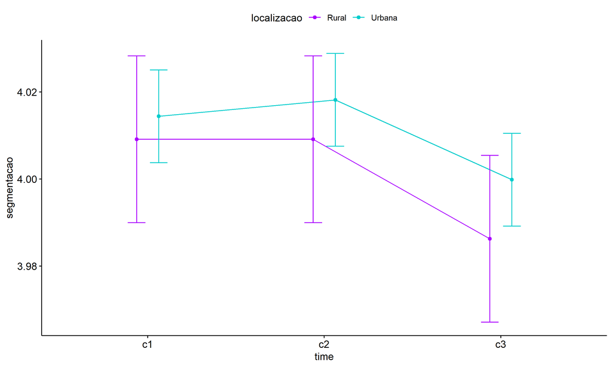

```r
pwc <- add_xy_position(pwc, x = "time", fun = "mean_se", dodge = 0.25)
pd <- position_dodge(width = 0.25)
ggline(emms, x = "time", y = "emmean", color = "localizacao",
       palette = c("#AA00FF","#00CCCC"),
       position = pd, ylab = "segmentacao") +
  geom_errorbar(aes(ymin = conf.low, ymax = conf.high, color = localizacao),
                position = pd, width = 0.2) +
  stat_pvalue_manual(pwc, hide.ns = T, tip.length = F, linetype = 1)
```

```r
(pwc <- ldat %>% group_by(localizacao) %>%
    emmeans_test(segmentacao ~ time, detailed = T, p.adjust.method = "bonferroni"))
```

```
## # A tibble: 6 × 15
##   localizacao term  .y.         group1 group2 null.value  estimate      se    df  conf.low conf.high statistic      p  p.adj
## * <fct>       <chr> <chr>       <chr>  <chr>       <dbl>     <dbl>   <dbl> <dbl>     <dbl>     <dbl>     <dbl>  <dbl>  <dbl>
## 1 Rural       time  segmentacao c1     c2              0 -2.58e-15 0.0138   8313 -0.0271      0.0271 -1.87e-13 1.00   1
## 2 Rural       time  segmentacao c1     c3              0  2.29e- 2 0.0138   8313 -0.00422     0.0500  1.65e+ 0 0.0980 0.294
## 3 Rural       time  segmentacao c2     c3              0  2.29e- 2 0.0138   8313 -0.00422     0.0500  1.65e+ 0 0.0980 0.294
## 4 Urbana      time  segmentacao c1     c2              0 -3.78e- 3 0.00769  8313 -0.0189      0.0113 -4.91e- 1 0.623  1
## 5 Urbana      time  segmentacao c1     c3              0  1.46e- 2 0.00769  8313 -0.000515    0.0296  1.89e+ 0 0.0583 0.175
## 6 Urbana      time  segmentacao c2     c3              0  1.83e- 2 0.00769  8313  0.00326     0.0334  2.38e+ 0 0.0171 0.0514
## # ℹ 1 more variable: p.adj.signif <chr>
```

| localizacao | term | .y. | group1 | group2 | null.value | estimate | se | df | conf.low | conf.high | statistic | p | p.adj | p.adj.signif |
| --- | --- | --- | --- | --- | --- | --- | --- | --- | --- | --- | --- | --- | --- | --- |
| Rural | time | segmentacao | c1 | c2 | 0 | 0.000 | 0.014 | 8313 | -0.027 | 0.027 | 0.000 | 1.000 | 1.000 | ns |
| Rural | time | segmentacao | c1 | c3 | 0 | 0.023 | 0.014 | 8313 | -0.004 | 0.050 | 1.655 | 0.098 | 0.294 | ns |
| Rural | time | segmentacao | c2 | c3 | 0 | 0.023 | 0.014 | 8313 | -0.004 | 0.050 | 1.655 | 0.098 | 0.294 | ns |
| Urbana | time | segmentacao | c1 | c2 | 0 | -0.004 | 0.008 | 8313 | -0.019 | 0.011 | -0.491 | 0.623 | 1.000 | ns |
| Urbana | time | segmentacao | c1 | c3 | 0 | 0.015 | 0.008 | 8313 | -0.001 | 0.030 | 1.893 | 0.058 | 0.175 | ns |
| Urbana | time | segmentacao | c2 | c3 | 0 | 0.018 | 0.008 | 8313 | 0.003 | 0.033 | 2.385 | 0.017 | 0.051 | ns |

```r
(emms <- get_emmeans(pwc))
```

```
## # A tibble: 6 × 8
##   localizacao time  emmean      se    df conf.low conf.high method
##   <fct>       <fct>  <dbl>   <dbl> <dbl>    <dbl>     <dbl> <chr>
## 1 Rural       c1      4.01 0.00977  8313     3.99      4.03 Emmeans test
## 2 Rural       c2      4.01 0.00977  8313     3.99      4.03 Emmeans test
## 3 Rural       c3      3.99 0.00977  8313     3.97      4.01 Emmeans test
## 4 Urbana      c1      4.01 0.00544  8313     4.00      4.03 Emmeans test
## 5 Urbana      c2      4.02 0.00544  8313     4.01      4.03 Emmeans test
## 6 Urbana      c3      4.00 0.00544  8313     3.99      4.01 Emmeans test
```

| localizacao | time | emmean | se | df | conf.low | conf.high | method |
| --- | --- | --- | --- | --- | --- | --- | --- |
| Rural | c1 | 4.009 | 0.010 | 8313 | 3.990 | 4.028 | Emmeans test |
| Rural | c2 | 4.009 | 0.010 | 8313 | 3.990 | 4.028 | Emmeans test |
| Rural | c3 | 3.986 | 0.010 | 8313 | 3.967 | 4.005 | Emmeans test |
| Urbana | c1 | 4.014 | 0.005 | 8313 | 4.004 | 4.025 | Emmeans test |
| Urbana | c2 | 4.018 | 0.005 | 8313 | 4.008 | 4.029 | Emmeans test |
| Urbana | c3 | 4.000 | 0.005 | 8313 | 3.989 | 4.011 | Emmeans test |

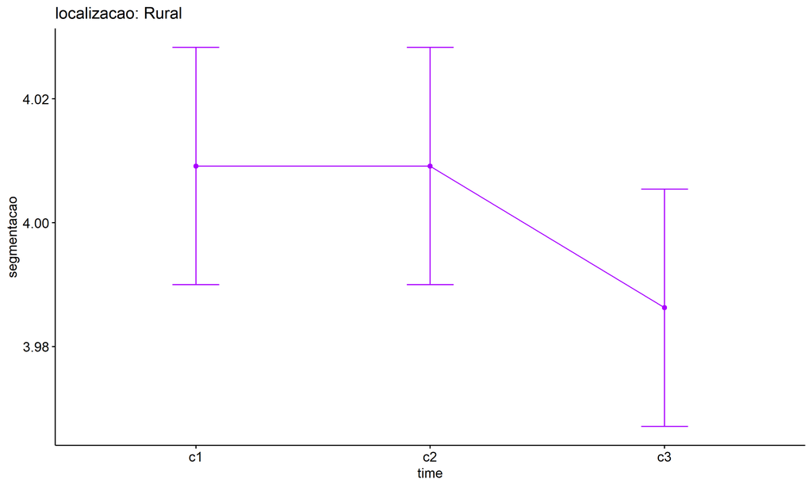

```r
emms.gg <- emms[which(emms$localizacao == "Rural"),]
if (nrow(emms.gg) > 0)
  ggline(emms.gg, x = "time", y = "emmean", color = "#AA00FF", ylab = "segmentacao") +
    geom_errorbar(aes(ymin = conf.low, ymax = conf.high),
                  width = 0.2, color = "#AA00FF") +
    stat_pvalue_manual(
      add_xy_position(pwc[which(pwc$localizacao == "Rural"),],
                      x = "time", fun = "mean_se"),
      hide.ns = T, color = "#AA00FF", tip.length = F) +
    labs(title = "localizacao: Rural")+
    theme(legend.text = element_blank())
```

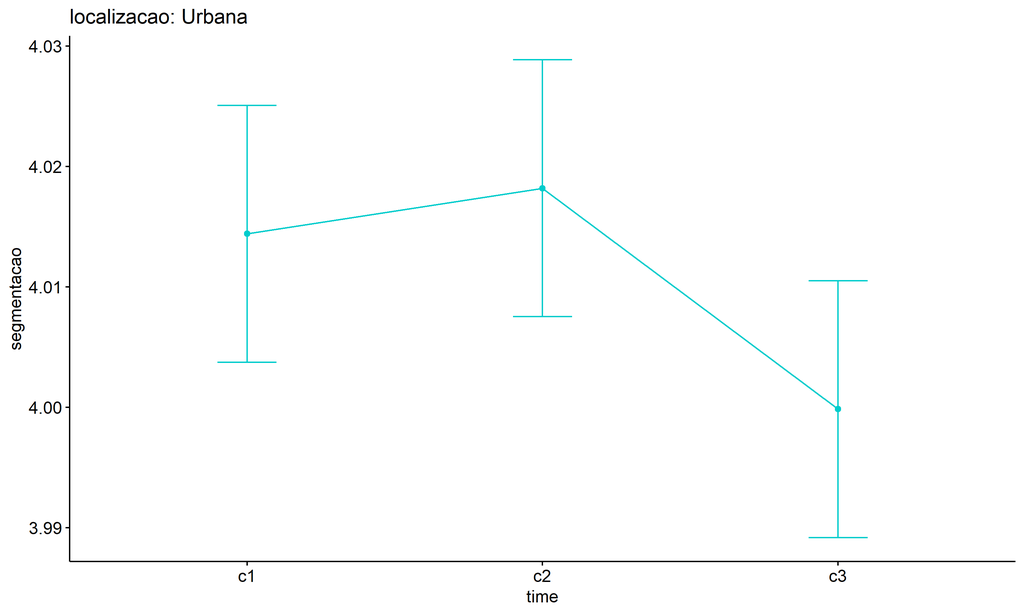

```r
emms.gg <- emms[which(emms$localizacao == "Urbana"),]
if (nrow(emms.gg) > 0)
  ggline(emms.gg, x = "time", y = "emmean", color = "#00CCCC", ylab = "segmentacao") +
    geom_errorbar(aes(ymin = conf.low, ymax = conf.high),
                  width = 0.2, color = "#00CCCC") +
    stat_pvalue_manual(
      add_xy_position(pwc[which(pwc$localizacao == "Urbana"),],
                      x = "time", fun = "mean_se"),
      hide.ns = T, color = "#00CCCC", tip.length = F) +
    labs(title = "localizacao: Urbana")+
    theme(legend.text = element_blank())
```

## PairWise Computation after removing non.normal data

```r
if (length(non.ids) > 0)
  (pwc2 <- ldat2 %>% group_by(time) %>%
     emmeans_test(segmentacao ~ localizacao, detailed = T, p.adjust.method = "bonferroni"))
```

```r
if (length(non.ids) > 0)
  (emms2 <- get_emmeans(pwc2))
```

```r
if (length(non.ids) > 0) {
  pwc2 <- add_xy_position(pwc2, x = "time", fun = "mean_se", dodge = 0.25)
  pd2 <- position_dodge(width = 0.25)

  ggline(emms2, x = "time", y = "emmean", color = "localizacao",
         palette = c("#AA00FF","#00CCCC"),
         position = pd, ylab = "segmentacao") +
    geom_errorbar(aes(ymin = conf.low, ymax = conf.high, color = localizacao),
                position = pd, width = 0.2) +
    stat_pvalue_manual(pwc2, hide.ns = T, tip.length = F, linetype = 1)
}
```

```r
if (length(non.ids) > 0)
  (pwc2 <- ldat2 %>% group_by(localizacao) %>%
     emmeans_test(segmentacao ~ time, detailed = T, p.adjust.method = "bonferroni"))
```

```r
if (length(non.ids) > 0)
  (emms2 <- get_emmeans(pwc2))
```

```r
if (length(non.ids) > 0) {
  emms.gg <- emms2[which(emms2$localizacao == "Rural"),]
  if (nrow(emms.gg) > 0)
    ggline(emms.gg, x = "time", y = "emmean", color = "#AA00FF", ylab = "segmentacao") +
    geom_errorbar(aes(ymin = conf.low, ymax = conf.high),
                  width = 0.2, color = "#AA00FF") +
    stat_pvalue_manual(
      add_xy_position(pwc[which(pwc$localizacao == "Rural"),],
                      x = "time", fun = "mean_se"),
      hide.ns = T, color = "#AA00FF", tip.length = F) +
    labs(title = "localizacao: Rural") +
    theme(legend.text = element_blank())
}
```

```r
if (length(non.ids) > 0) {
  emms.gg <- emms2[which(emms2$localizacao == "Urbana"),]
  if (nrow(emms.gg) > 0)
    ggline(emms.gg, x = "time", y = "emmean", color = "#00CCCC", ylab = "segmentacao") +
    geom_errorbar(aes(ymin = conf.low, ymax = conf.high),
                  width = 0.2, color = "#00CCCC") +
    stat_pvalue_manual(
      add_xy_position(pwc[which(pwc$localizacao == "Urbana"),],
                      x = "time", fun = "mean_se"),
      hide.ns = T, color = "#00CCCC", tip.length = F) +
    labs(title = "localizacao: Urbana") +
    theme(legend.text = element_blank())
}
```

# ANOVA: segmentacao ~ time*regiao + Error(id/time)

## Data Preparation

```r
data <- edat[,c("aluno_id","regiao","ciclo","segmentacao")]
data <- data[data$ciclo %in% c("Primeiro Ciclo","Segundo Ciclo","Terceiro Ciclo"),]
data$ciclo <- factor(data$ciclo, c("Primeiro Ciclo","Segundo Ciclo","Terceiro Ciclo"))
data <- unique(data)

wdat <- spread(data, ciclo, segmentacao)
wdat <- wdat[complete.cases(wdat),]
colnames(wdat) <- c("id","regiao","c1","c2","c3")

ldat <- gather(wdat, key = time, value = segmentacao, c1,c2,c3) %>%
  convert_as_factor(id, time)
ldat <- remove_group_data(ldat, "segmentacao", c("time", "regiao"), n.limit = 30)
ldat$regiao <- factor(ldat$regiao, sort(unique(ldat$regiao)))
```

### Check assumptions: Identifying Outliers

```r
outliers <- identify_outliers(group_by(ldat, time, regiao), segmentacao)
(outliers <- outliers[outliers$is.extreme == T,])
```

```
## # A tibble: 871 × 6
##    regiao       time  id                   segmentacao is.outlier is.extreme
##    <fct>        <fct> <fct>                      <dbl> <lgl>      <lgl>
##  1 Centro-Oeste c1    7YMayZh0mClXMucg1uN5         3   TRUE       TRUE
##  2 Centro-Oeste c1    8J6zVzXwczhDoIz6ZH9H         4.5 TRUE       TRUE
##  3 Centro-Oeste c1    9GpNQKRqFgCZSRQwdi13         5   TRUE       TRUE
##  4 Centro-Oeste c1    9jd1C85ixCoJf3EINYfx         5   TRUE       TRUE
##  5 Centro-Oeste c1    A2dPKqbrD2yInm50Jwiu         3.5 TRUE       TRUE
##  6 Centro-Oeste c1    aOGxFSPrreKjHqmQIKKA         4.5 TRUE       TRUE
##  7 Centro-Oeste c1    atydp19vM0PjiOQCWemR         5   TRUE       TRUE
##  8 Centro-Oeste c1    b53oZp9kciii7CaLT2b0         4.5 TRUE       TRUE
##  9 Centro-Oeste c1    cztImgQlVojWbCx6odTk         4.5 TRUE       TRUE
## 10 Centro-Oeste c1    GWOo8wrk6V8uRCPAvb8O         4.5 TRUE       TRUE
## # ℹ 861 more rows
```

| regiao | time | id | segmentacao | is.outlier | is.extreme |
| --- | --- | --- | --- | --- | --- |
| Centro-Oeste | c1 | 7YMayZh0mClXMucg1uN5 | 3.000 | TRUE | TRUE |
| Centro-Oeste | c1 | 8J6zVzXwczhDoIz6ZH9H | 4.500 | TRUE | TRUE |
| Centro-Oeste | c1 | 9GpNQKRqFgCZSRQwdi13 | 5.000 | TRUE | TRUE |
| Centro-Oeste | c1 | 9jd1C85ixCoJf3EINYfx | 5.000 | TRUE | TRUE |
| Centro-Oeste | c1 | A2dPKqbrD2yInm50Jwiu | 3.500 | TRUE | TRUE |
| Centro-Oeste | c1 | aOGxFSPrreKjHqmQIKKA | 4.500 | TRUE | TRUE |
| Centro-Oeste | c1 | atydp19vM0PjiOQCWemR | 5.000 | TRUE | TRUE |
| Centro-Oeste | c1 | b53oZp9kciii7CaLT2b0 | 4.500 | TRUE | TRUE |
| Centro-Oeste | c1 | cztImgQlVojWbCx6odTk | 4.500 | TRUE | TRUE |
| Centro-Oeste | c1 | GWOo8wrk6V8uRCPAvb8O | 4.500 | TRUE | TRUE |
| Centro-Oeste | c1 | HSX3YOtyIg0ZOh76zqlN | 4.500 | TRUE | TRUE |
| Centro-Oeste | c1 | IxjAoAer0KtYtbC6FF9j | 3.500 | TRUE | TRUE |
| Centro-Oeste | c1 | jTp5Uco52t3AcrsTI4MJ | 3.000 | TRUE | TRUE |
| Centro-Oeste | c1 | kxgVSkWgUMuhBuLVsqVJ | 3.000 | TRUE | TRUE |
| Centro-Oeste | c1 | LC1uBEBe3hZn8Q1mQe7A | 4.500 | TRUE | TRUE |
| Centro-Oeste | c1 | NGCQanKdT1it8UlBNgmW | 3.500 | TRUE | TRUE |
| Centro-Oeste | c1 | nrctDKnNeBPAy3FWmN34 | 4.500 | TRUE | TRUE |
| Centro-Oeste | c1 | oB5KNHL8aUZyGZK3jNIP | 4.500 | TRUE | TRUE |
| Centro-Oeste | c1 | oc2vuNVHO2aEnJA2p1LU | 4.500 | TRUE | TRUE |
| Centro-Oeste | c1 | oEJ6BXIBwT3f8YeFfVhw | 4.500 | TRUE | TRUE |
| Centro-Oeste | c1 | q1RelulkOweB4lCMWfxy | 4.500 | TRUE | TRUE |
| Centro-Oeste | c1 | Q2zIqpZTrvVCMOaKQlNf | 4.500 | TRUE | TRUE |
| Centro-Oeste | c1 | q7qFgPldgJeYuCPBjp4P | 4.500 | TRUE | TRUE |
| Centro-Oeste | c1 | ScTMK6tLs91Uic7qY4rP | 4.500 | TRUE | TRUE |
| Centro-Oeste | c1 | SoGp0lIq4pc911ctmbB1 | 4.500 | TRUE | TRUE |
| Centro-Oeste | c1 | SvekTKBTsDABPXeAyVVa | 5.000 | TRUE | TRUE |
| Centro-Oeste | c1 | Td2jjdjfN2w4cYYkd3EM | 4.500 | TRUE | TRUE |
| Centro-Oeste | c1 | TupwpKp0mSf2xCyx7nhJ | 4.500 | TRUE | TRUE |
| Centro-Oeste | c1 | w9TINZ7XLSBvZflVyyoz | 3.000 | TRUE | TRUE |
| Centro-Oeste | c1 | wSTeItj2YyZhZQ0kiCqW | 4.500 | TRUE | TRUE |

[output cut: 841 more lines]

### Check assumptions: Normality Test

```r
(normality.df <- normality.test.per.groups(ldat, "segmentacao", c("time", "regiao")))
```

```
##            var    variable time       regiao    n    skewness  kurtosis symmetry statistic     method                        p
## 1  segmentacao segmentacao   c1 Centro-Oeste  216  0.07040064  7.129192       NO  41.27632 D'Agostino 0.0000000010888313584090
## 2  segmentacao segmentacao   c1     Nordeste 1499  0.22625433  7.014386       NO 232.30606 D'Agostino 0.0000000000000000000000
## 3  segmentacao segmentacao   c1        Norte  202 -0.82144952  3.377137       NO  41.41976 D'Agostino 0.0000000010134751926572
## 4  segmentacao segmentacao   c1      Sudeste  693 -0.22294951  6.906963       NO 111.88224 D'Agostino 0.0000000000000000000000
## 5  segmentacao segmentacao   c1          Sul  163  0.53573946 16.235121       NO  60.68987 D'Agostino 0.0000000000000662803146
## 6  segmentacao segmentacao   c2 Centro-Oeste  216  0.07551275 20.054079       NO  71.20356 D'Agostino 0.0000000000000003330669
## 7  segmentacao segmentacao   c2     Nordeste 1499  0.94430375 11.442234       NO 458.99569 D'Agostino 0.0000000000000000000000
## 8  segmentacao segmentacao   c2        Norte  202  0.29727961  5.503235       NO  35.76272 D'Agostino 0.0000000171484387800902
## 9  segmentacao segmentacao   c2      Sudeste  693  0.75275287 10.169135       NO 188.59696 D'Agostino 0.0000000000000000000000
## 10 segmentacao segmentacao   c2          Sul  163 -2.80573407  7.936470       NO 116.42088 D'Agostino 0.0000000000000000000000
## 11 segmentacao segmentacao   c3 Centro-Oeste  216  2.21822255 11.236612       NO 134.12315 D'Agostino 0.0000000000000000000000
## 12 segmentacao segmentacao   c3     Nordeste 1499 -0.33240551 15.905371       NO 372.45749 D'Agostino 0.0000000000000000000000
## 13 segmentacao segmentacao   c3        Norte  202 -0.95635361 13.238399       NO  80.66128 D'Agostino 0.0000000000000000000000
## 14 segmentacao segmentacao   c3      Sudeste  693 -1.80916599 16.557623       NO 360.49247 D'Agostino 0.0000000000000000000000
```

[output cut: 17 more lines]

| var | variable | time | regiao | n | skewness | kurtosis | symmetry | statistic | method | p | p.signif | normality |
| --- | --- | --- | --- | --- | --- | --- | --- | --- | --- | --- | --- | --- |
| segmentacao | segmentacao | c1 | Centro-Oeste | 216 | 0.070 | 7.129 | NO | 41.276 | D’Agostino | 0 | **** | - |
| segmentacao | segmentacao | c1 | Nordeste | 1499 | 0.226 | 7.014 | NO | 232.306 | D’Agostino | 0 | **** | - |
| segmentacao | segmentacao | c1 | Norte | 202 | -0.821 | 3.377 | NO | 41.420 | D’Agostino | 0 | **** | - |
| segmentacao | segmentacao | c1 | Sudeste | 693 | -0.223 | 6.907 | NO | 111.882 | D’Agostino | 0 | **** | - |
| segmentacao | segmentacao | c1 | Sul | 163 | 0.536 | 16.235 | NO | 60.690 | D’Agostino | 0 | **** | QQ |
| segmentacao | segmentacao | c2 | Centro-Oeste | 216 | 0.076 | 20.054 | NO | 71.204 | D’Agostino | 0 | **** | - |
| segmentacao | segmentacao | c2 | Nordeste | 1499 | 0.944 | 11.442 | NO | 458.996 | D’Agostino | 0 | **** | - |
| segmentacao | segmentacao | c2 | Norte | 202 | 0.297 | 5.503 | NO | 35.763 | D’Agostino | 0 | **** | - |
| segmentacao | segmentacao | c2 | Sudeste | 693 | 0.753 | 10.169 | NO | 188.597 | D’Agostino | 0 | **** | - |
| segmentacao | segmentacao | c2 | Sul | 163 | -2.806 | 7.936 | NO | 116.421 | D’Agostino | 0 | **** | QQ |
| segmentacao | segmentacao | c3 | Centro-Oeste | 216 | 2.218 | 11.237 | NO | 134.123 | D’Agostino | 0 | **** | - |
| segmentacao | segmentacao | c3 | Nordeste | 1499 | -0.332 | 15.905 | NO | 372.457 | D’Agostino | 0 | **** | - |
| segmentacao | segmentacao | c3 | Norte | 202 | -0.956 | 13.238 | NO | 80.661 | D’Agostino | 0 | **** | - |
| segmentacao | segmentacao | c3 | Sudeste | 693 | -1.809 | 16.558 | NO | 360.492 | D’Agostino | 0 | **** | - |
| segmentacao | segmentacao | c3 | Sul | 163 | 0.000 | 0.000 | few data | NA | NA | 1 | NA | NO |

```r
(non.ids <- unique(do.call(
  c, lapply(which(normality.df$normality == 'NO'), FUN = function(i) {
  idx = which(ldat$time == normality.df$time[i] &
                ldat$regiao == normality.df$regiao[i])
  getNonNormal(ldat$"segmentacao"[idx], ldat$id[idx])
}))))
```

```r
if (length(non.ids) > 0)
  ldat2 <- ldat[!ldat$id %in% non.ids,]
```

### Summary Statistics

```r
(sdat <- ldat %>% group_by(time, regiao) %>%
   get_summary_stats(segmentacao, type = "mean_sd"))
```

```
## # A tibble: 15 × 6
##    regiao       time  variable        n  mean    sd
##    <fct>        <fct> <fct>       <dbl> <dbl> <dbl>
##  1 Centro-Oeste c1    segmentacao   216  4.04 0.268
##  2 Nordeste     c1    segmentacao  1499  4.03 0.294
##  3 Norte        c1    segmentacao   202  3.95 0.358
##  4 Sudeste      c1    segmentacao   693  4.00 0.29
##  5 Sul          c1    segmentacao   163  4.01 0.219
##  6 Centro-Oeste c2    segmentacao   216  4.01 0.174
##  7 Nordeste     c2    segmentacao  1499  4.03 0.239
##  8 Norte        c2    segmentacao   202  4.01 0.326
##  9 Sudeste      c2    segmentacao   693  4.02 0.248
## 10 Sul          c2    segmentacao   163  3.93 0.253
## 11 Centro-Oeste c3    segmentacao   216  4.04 0.231
## 12 Nordeste     c3    segmentacao  1499  4.00 0.206
## 13 Norte        c3    segmentacao   202  3.99 0.231
## 14 Sudeste      c3    segmentacao   693  3.99 0.197
## 15 Sul          c3    segmentacao   163  4    0.124
```

| regiao | time | variable | n | mean | sd |
| --- | --- | --- | --- | --- | --- |
| Centro-Oeste | c1 | segmentacao | 216 | 4.039 | 0.268 |
| Nordeste | c1 | segmentacao | 1499 | 4.025 | 0.294 |
| Norte | c1 | segmentacao | 202 | 3.948 | 0.358 |
| Sudeste | c1 | segmentacao | 693 | 3.999 | 0.290 |
| Sul | c1 | segmentacao | 163 | 4.009 | 0.219 |
| Centro-Oeste | c2 | segmentacao | 216 | 4.007 | 0.174 |
| Nordeste | c2 | segmentacao | 1499 | 4.025 | 0.239 |
| Norte | c2 | segmentacao | 202 | 4.012 | 0.326 |
| Sudeste | c2 | segmentacao | 693 | 4.021 | 0.248 |
| Sul | c2 | segmentacao | 163 | 3.934 | 0.253 |
| Centro-Oeste | c3 | segmentacao | 216 | 4.035 | 0.231 |
| Nordeste | c3 | segmentacao | 1499 | 3.996 | 0.206 |
| Norte | c3 | segmentacao | 202 | 3.993 | 0.231 |
| Sudeste | c3 | segmentacao | 693 | 3.986 | 0.197 |
| Sul | c3 | segmentacao | 163 | 4.000 | 0.124 |

```r
if (length(non.ids) > 0)
  (sdat <- ldat2 %>% group_by(time, regiao) %>%
      get_summary_stats(segmentacao, type = "mean_sd"))
```

| regiao | time | variable | n | mean | sd |
| --- | --- | --- | --- | --- | --- |
| Centro-Oeste | c1 | segmentacao | 216 | 4.039 | 0.268 |
| Nordeste | c1 | segmentacao | 1499 | 4.025 | 0.294 |
| Norte | c1 | segmentacao | 202 | 3.948 | 0.358 |
| Sudeste | c1 | segmentacao | 693 | 3.999 | 0.290 |
| Sul | c1 | segmentacao | 163 | 4.009 | 0.219 |
| Centro-Oeste | c2 | segmentacao | 216 | 4.007 | 0.174 |
| Nordeste | c2 | segmentacao | 1499 | 4.025 | 0.239 |
| Norte | c2 | segmentacao | 202 | 4.012 | 0.326 |
| Sudeste | c2 | segmentacao | 693 | 4.021 | 0.248 |
| Sul | c2 | segmentacao | 163 | 3.934 | 0.253 |
| Centro-Oeste | c3 | segmentacao | 216 | 4.035 | 0.231 |
| Nordeste | c3 | segmentacao | 1499 | 3.996 | 0.206 |
| Norte | c3 | segmentacao | 202 | 3.993 | 0.231 |
| Sudeste | c3 | segmentacao | 693 | 3.986 | 0.197 |
| Sul | c3 | segmentacao | 163 | 4.000 | 0.124 |

## ANOVA Computation

```r
(res.aov <- anova_test(ldat, dv = segmentacao, wid = id, between = regiao, within = time))
```

```
## ANOVA Table (type III tests)
##
## $ANOVA
##        Effect DFn  DFd     F        p p<.05       ges
## 1      regiao   4 2768 4.743 0.000817     * 0.0020000
## 2        time   2 5536 0.116 0.890000       0.0000271
## 3 regiao:time   8 5536 3.662 0.000288     * 0.0030000
##
## $`Mauchly's Test for Sphericity`
##        Effect     W                          p p<.05
## 1        time 0.964 0.000000000000000000000158     *
## 2 regiao:time 0.964 0.000000000000000000000158     *
##
## $`Sphericity Corrections`
##        Effect   GGe        DF[GG]    p[GG] p[GG]<.05   HFe        DF[HF]    p[HF] p[HF]<.05
## 1        time 0.966 1.93, 5345.51 0.884000           0.966 1.93, 5349.17 0.884000
## 2 regiao:time 0.966 7.72, 5345.51 0.000352         * 0.966 7.73, 5349.17 0.000351         *
```

| Effect | DFn | DFd | F | p | p<.05 | ges |
| --- | --- | --- | --- | --- | --- | --- |
| regiao | 4 | 2768 | 4.743 | 0.001 | * | 0.002 |
| time | 2 | 5536 | 0.116 | 0.890 |  | 0.000 |
| regiao:time | 8 | 5536 | 3.662 | 0.000 | * | 0.003 |

| Effect | W | p | p<.05 |
| --- | --- | --- | --- |
| time | 0.964 | 0 | * |
| regiao:time | 0.964 | 0 | * |

| Effect | GGe | DF[GG] | p[GG] | p[GG]<.05 | HFe | DF[HF] | p[HF] | p[HF]<.05 |
| --- | --- | --- | --- | --- | --- | --- | --- | --- |
| time | 0.966 | 1.93, 5345.51 | 0.884 |  | 0.966 | 1.93, 5349.17 | 0.884 |  |
| regiao:time | 0.966 | 7.72, 5345.51 | 0.000 | * | 0.966 | 7.73, 5349.17 | 0.000 | * |

## ANOVA Computation after removing non.normal data

```r
if (length(non.ids) > 0)
  (res.aov2 <- anova_test(ldat2, dv = segmentacao, wid = id, between = regiao , within = time))
```

## PairWise Computation

```r
(pwc <- ldat %>% group_by(time) %>%
   emmeans_test(segmentacao ~ regiao, detailed = T, p.adjust.method = "bonferroni"))
```

[output not shown]

```r
(emms <- get_emmeans(pwc))
```

```
## # A tibble: 15 × 8
##    time  regiao       emmean      se    df conf.low conf.high method
##    <fct> <fct>         <dbl>   <dbl> <dbl>    <dbl>     <dbl> <chr>
##  1 c1    Centro-Oeste   4.04 0.0170   8304     4.01      4.07 Emmeans test
##  2 c1    Nordeste       4.03 0.00645  8304     4.01      4.04 Emmeans test
##  3 c1    Norte          3.95 0.0176   8304     3.91      3.98 Emmeans test
##  4 c1    Sudeste        4.00 0.00949  8304     3.98      4.02 Emmeans test
##  5 c1    Sul            4.01 0.0196   8304     3.97      4.05 Emmeans test
##  6 c2    Centro-Oeste   4.01 0.0170   8304     3.97      4.04 Emmeans test
##  7 c2    Nordeste       4.02 0.00645  8304     4.01      4.04 Emmeans test
##  8 c2    Norte          4.01 0.0176   8304     3.98      4.05 Emmeans test
##  9 c2    Sudeste        4.02 0.00949  8304     4.00      4.04 Emmeans test
## 10 c2    Sul            3.93 0.0196   8304     3.90      3.97 Emmeans test
## 11 c3    Centro-Oeste   4.03 0.0170   8304     4.00      4.07 Emmeans test
## 12 c3    Nordeste       4.00 0.00645  8304     3.98      4.01 Emmeans test
## 13 c3    Norte          3.99 0.0176   8304     3.96      4.03 Emmeans test
## 14 c3    Sudeste        3.99 0.00949  8304     3.97      4.00 Emmeans test
## 15 c3    Sul            4.00 0.0196   8304     3.96      4.04 Emmeans test
```

| time | regiao | emmean | se | df | conf.low | conf.high | method |
| --- | --- | --- | --- | --- | --- | --- | --- |
| c1 | Centro-Oeste | 4.039 | 0.017 | 8304 | 4.006 | 4.073 | Emmeans test |
| c1 | Nordeste | 4.025 | 0.006 | 8304 | 4.013 | 4.038 | Emmeans test |
| c1 | Norte | 3.948 | 0.018 | 8304 | 3.914 | 3.982 | Emmeans test |
| c1 | Sudeste | 3.999 | 0.009 | 8304 | 3.980 | 4.017 | Emmeans test |
| c1 | Sul | 4.009 | 0.020 | 8304 | 3.971 | 4.048 | Emmeans test |
| c2 | Centro-Oeste | 4.007 | 0.017 | 8304 | 3.973 | 4.040 | Emmeans test |
| c2 | Nordeste | 4.025 | 0.006 | 8304 | 4.012 | 4.037 | Emmeans test |
| c2 | Norte | 4.012 | 0.018 | 8304 | 3.978 | 4.046 | Emmeans test |
| c2 | Sudeste | 4.021 | 0.009 | 8304 | 4.002 | 4.040 | Emmeans test |
| c2 | Sul | 3.934 | 0.020 | 8304 | 3.896 | 3.972 | Emmeans test |
| c3 | Centro-Oeste | 4.035 | 0.017 | 8304 | 4.001 | 4.068 | Emmeans test |
| c3 | Nordeste | 3.996 | 0.006 | 8304 | 3.984 | 4.009 | Emmeans test |
| c3 | Norte | 3.993 | 0.018 | 8304 | 3.958 | 4.027 | Emmeans test |
| c3 | Sudeste | 3.986 | 0.009 | 8304 | 3.967 | 4.004 | Emmeans test |
| c3 | Sul | 4.000 | 0.020 | 8304 | 3.962 | 4.038 | Emmeans test |

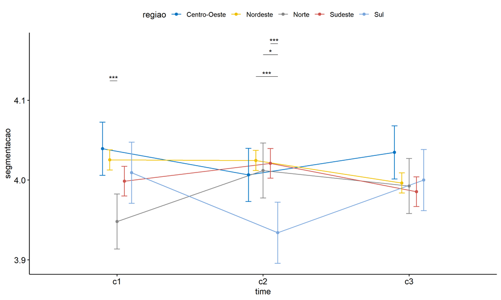

```r
pwc <- add_xy_position(pwc, x = "time", fun = "mean_se", dodge = 0.25)
pd <- position_dodge(width = 0.25)
ggline(emms, x = "time", y = "emmean", color = "regiao",
       palette = c("#0073C2FF","#EFC000FF","#868686FF","#CD534CFF","#7AA6DCFF"),
       position = pd, ylab = "segmentacao") +
  geom_errorbar(aes(ymin = conf.low, ymax = conf.high, color = regiao),
                position = pd, width = 0.2) +
  stat_pvalue_manual(pwc, hide.ns = T, tip.length = F, linetype = 1)
```

```r
(pwc <- ldat %>% group_by(regiao) %>%
    emmeans_test(segmentacao ~ time, detailed = T, p.adjust.method = "bonferroni"))
```

```
## # A tibble: 15 × 15
##    regiao  term  .y.   group1 group2 null.value estimate      se    df conf.low conf.high statistic       p   p.adj p.adj.signif
##  * <fct>   <chr> <chr> <chr>  <chr>       <dbl>    <dbl>   <dbl> <dbl>    <dbl>     <dbl>     <dbl>   <dbl>   <dbl> <chr>
##  1 Centro… time  segm… c1     c2              0  3.28e-2 0.0240   8304 -0.0143    0.0799     1.36   0.172   0.517   ns
##  2 Centro… time  segm… c1     c3              0  4.63e-3 0.0240   8304 -0.0425    0.0517     0.193  0.847   1       ns
##  3 Centro… time  segm… c2     c3              0 -2.82e-2 0.0240   8304 -0.0753    0.0189    -1.17   0.241   0.724   ns
##  4 Nordes… time  segm… c1     c2              0  7.23e-4 0.00912  8304 -0.0172    0.0186     0.0792 0.937   1       ns
##  5 Nordes… time  segm… c1     c3              0  2.89e-2 0.00912  8304  0.0110    0.0468     3.17   0.00153 0.00460 **
##  6 Nordes… time  segm… c2     c3              0  2.82e-2 0.00912  8304  0.0103    0.0461     3.09   0.00201 0.00602 **
##  7 Norte   time  segm… c1     c2              0 -6.39e-2 0.0248   8304 -0.113    -0.0152    -2.57   0.0101  0.0303  *
##  8 Norte   time  segm… c1     c3              0 -4.46e-2 0.0248   8304 -0.0933    0.00415   -1.79   0.0730  0.219   ns
##  9 Norte   time  segm… c2     c3              0  1.94e-2 0.0248   8304 -0.0293    0.0681     0.780  0.435   1       ns
## 10 Sudeste time  segm… c1     c2              0 -2.24e-2 0.0134   8304 -0.0487    0.00393   -1.67   0.0955  0.287   ns
## 11 Sudeste time  segm… c1     c3              0  1.30e-2 0.0134   8304 -0.0133    0.0393     0.968  0.333   0.999   ns
## 12 Sudeste time  segm… c2     c3              0  3.54e-2 0.0134   8304  0.00906   0.0617     2.64   0.00842 0.0253  *
## 13 Sul     time  segm… c1     c2              0  7.52e-2 0.0277   8304  0.0209    0.129      2.72   0.00660 0.0198  *
## 14 Sul     time  segm… c1     c3              0  9.20e-3 0.0277   8304 -0.0450    0.0634     0.333  0.739   1       ns
## 15 Sul     time  segm… c2     c3              0 -6.60e-2 0.0277   8304 -0.120    -0.0117    -2.38   0.0171  0.0514  ns
```

| regiao | term | .y. | group1 | group2 | null.value | estimate | se | df | conf.low | conf.high | statistic | p | p.adj | p.adj.signif |
| --- | --- | --- | --- | --- | --- | --- | --- | --- | --- | --- | --- | --- | --- | --- |
| Centro-Oeste | time | segmentacao | c1 | c2 | 0 | 0.033 | 0.024 | 8304 | -0.014 | 0.080 | 1.365 | 0.172 | 0.517 | ns |
| Centro-Oeste | time | segmentacao | c1 | c3 | 0 | 0.005 | 0.024 | 8304 | -0.042 | 0.052 | 0.193 | 0.847 | 1.000 | ns |
| Centro-Oeste | time | segmentacao | c2 | c3 | 0 | -0.028 | 0.024 | 8304 | -0.075 | 0.019 | -1.172 | 0.241 | 0.724 | ns |
| Nordeste | time | segmentacao | c1 | c2 | 0 | 0.001 | 0.009 | 8304 | -0.017 | 0.019 | 0.079 | 0.937 | 1.000 | ns |
| Nordeste | time | segmentacao | c1 | c3 | 0 | 0.029 | 0.009 | 8304 | 0.011 | 0.047 | 3.169 | 0.002 | 0.005 | ** |
| Nordeste | time | segmentacao | c2 | c3 | 0 | 0.028 | 0.009 | 8304 | 0.010 | 0.046 | 3.090 | 0.002 | 0.006 | ** |
| Norte | time | segmentacao | c1 | c2 | 0 | -0.064 | 0.025 | 8304 | -0.113 | -0.015 | -2.573 | 0.010 | 0.030 | * |
| Norte | time | segmentacao | c1 | c3 | 0 | -0.045 | 0.025 | 8304 | -0.093 | 0.004 | -1.793 | 0.073 | 0.219 | ns |
| Norte | time | segmentacao | c2 | c3 | 0 | 0.019 | 0.025 | 8304 | -0.029 | 0.068 | 0.780 | 0.435 | 1.000 | ns |
| Sudeste | time | segmentacao | c1 | c2 | 0 | -0.022 | 0.013 | 8304 | -0.049 | 0.004 | -1.667 | 0.096 | 0.287 | ns |
| Sudeste | time | segmentacao | c1 | c3 | 0 | 0.013 | 0.013 | 8304 | -0.013 | 0.039 | 0.968 | 0.333 | 0.999 | ns |
| Sudeste | time | segmentacao | c2 | c3 | 0 | 0.035 | 0.013 | 8304 | 0.009 | 0.062 | 2.635 | 0.008 | 0.025 | * |
| Sul | time | segmentacao | c1 | c2 | 0 | 0.075 | 0.028 | 8304 | 0.021 | 0.129 | 2.717 | 0.007 | 0.020 | * |
| Sul | time | segmentacao | c1 | c3 | 0 | 0.009 | 0.028 | 8304 | -0.045 | 0.063 | 0.333 | 0.739 | 1.000 | ns |
| Sul | time | segmentacao | c2 | c3 | 0 | -0.066 | 0.028 | 8304 | -0.120 | -0.012 | -2.384 | 0.017 | 0.051 | ns |

```r
(emms <- get_emmeans(pwc))
```

```
## # A tibble: 15 × 8
##    regiao       time  emmean      se    df conf.low conf.high method
##    <fct>        <fct>  <dbl>   <dbl> <dbl>    <dbl>     <dbl> <chr>
##  1 Centro-Oeste c1      4.04 0.0170   8304     4.01      4.07 Emmeans test
##  2 Centro-Oeste c2      4.01 0.0170   8304     3.97      4.04 Emmeans test
##  3 Centro-Oeste c3      4.03 0.0170   8304     4.00      4.07 Emmeans test
##  4 Nordeste     c1      4.03 0.00645  8304     4.01      4.04 Emmeans test
##  5 Nordeste     c2      4.02 0.00645  8304     4.01      4.04 Emmeans test
##  6 Nordeste     c3      4.00 0.00645  8304     3.98      4.01 Emmeans test
##  7 Norte        c1      3.95 0.0176   8304     3.91      3.98 Emmeans test
##  8 Norte        c2      4.01 0.0176   8304     3.98      4.05 Emmeans test
##  9 Norte        c3      3.99 0.0176   8304     3.96      4.03 Emmeans test
## 10 Sudeste      c1      4.00 0.00949  8304     3.98      4.02 Emmeans test
## 11 Sudeste      c2      4.02 0.00949  8304     4.00      4.04 Emmeans test
## 12 Sudeste      c3      3.99 0.00949  8304     3.97      4.00 Emmeans test
## 13 Sul          c1      4.01 0.0196   8304     3.97      4.05 Emmeans test
## 14 Sul          c2      3.93 0.0196   8304     3.90      3.97 Emmeans test
## 15 Sul          c3      4.00 0.0196   8304     3.96      4.04 Emmeans test
```

| regiao | time | emmean | se | df | conf.low | conf.high | method |
| --- | --- | --- | --- | --- | --- | --- | --- |
| Centro-Oeste | c1 | 4.039 | 0.017 | 8304 | 4.006 | 4.073 | Emmeans test |
| Centro-Oeste | c2 | 4.007 | 0.017 | 8304 | 3.973 | 4.040 | Emmeans test |
| Centro-Oeste | c3 | 4.035 | 0.017 | 8304 | 4.001 | 4.068 | Emmeans test |
| Nordeste | c1 | 4.025 | 0.006 | 8304 | 4.013 | 4.038 | Emmeans test |
| Nordeste | c2 | 4.025 | 0.006 | 8304 | 4.012 | 4.037 | Emmeans test |
| Nordeste | c3 | 3.996 | 0.006 | 8304 | 3.984 | 4.009 | Emmeans test |
| Norte | c1 | 3.948 | 0.018 | 8304 | 3.914 | 3.982 | Emmeans test |
| Norte | c2 | 4.012 | 0.018 | 8304 | 3.978 | 4.046 | Emmeans test |
| Norte | c3 | 3.993 | 0.018 | 8304 | 3.958 | 4.027 | Emmeans test |
| Sudeste | c1 | 3.999 | 0.009 | 8304 | 3.980 | 4.017 | Emmeans test |
| Sudeste | c2 | 4.021 | 0.009 | 8304 | 4.002 | 4.040 | Emmeans test |
| Sudeste | c3 | 3.986 | 0.009 | 8304 | 3.967 | 4.004 | Emmeans test |
| Sul | c1 | 4.009 | 0.020 | 8304 | 3.971 | 4.048 | Emmeans test |
| Sul | c2 | 3.934 | 0.020 | 8304 | 3.896 | 3.972 | Emmeans test |
| Sul | c3 | 4.000 | 0.020 | 8304 | 3.962 | 4.038 | Emmeans test |

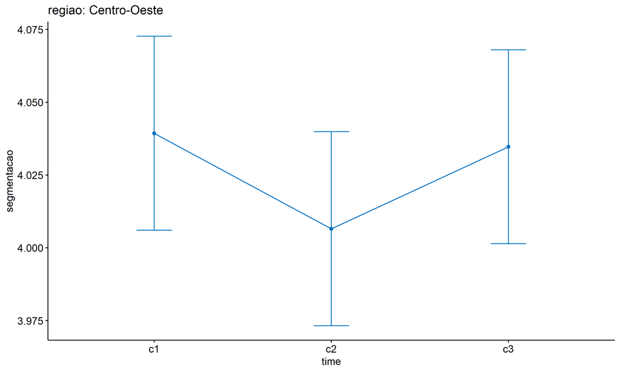

```r
emms.gg <- emms[which(emms$regiao == "Centro-Oeste"),]
if (nrow(emms.gg) > 0)
  ggline(emms.gg, x = "time", y = "emmean", color = "#0073C2FF", ylab = "segmentacao") +
    geom_errorbar(aes(ymin = conf.low, ymax = conf.high),
                  width = 0.2, color = "#0073C2FF") +
    stat_pvalue_manual(
      add_xy_position(pwc[which(pwc$regiao == "Centro-Oeste"),],
                      x = "time", fun = "mean_se"),
      hide.ns = T, color = "#0073C2FF", tip.length = F) +
    labs(title = "regiao: Centro-Oeste")+
    theme(legend.text = element_blank())
```

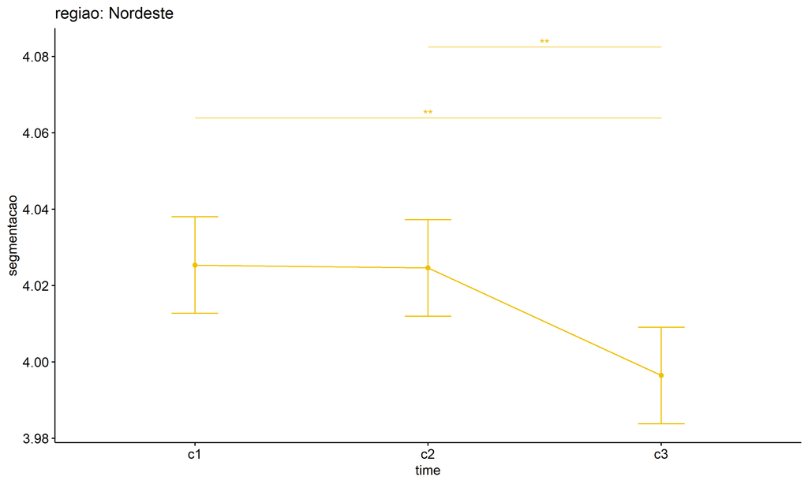

```r
emms.gg <- emms[which(emms$regiao == "Nordeste"),]
if (nrow(emms.gg) > 0)
  ggline(emms.gg, x = "time", y = "emmean", color = "#EFC000FF", ylab = "segmentacao") +
    geom_errorbar(aes(ymin = conf.low, ymax = conf.high),
                  width = 0.2, color = "#EFC000FF") +
    stat_pvalue_manual(
      add_xy_position(pwc[which(pwc$regiao == "Nordeste"),],
                      x = "time", fun = "mean_se"),
      hide.ns = T, color = "#EFC000FF", tip.length = F) +
    labs(title = "regiao: Nordeste")+
    theme(legend.text = element_blank())
```

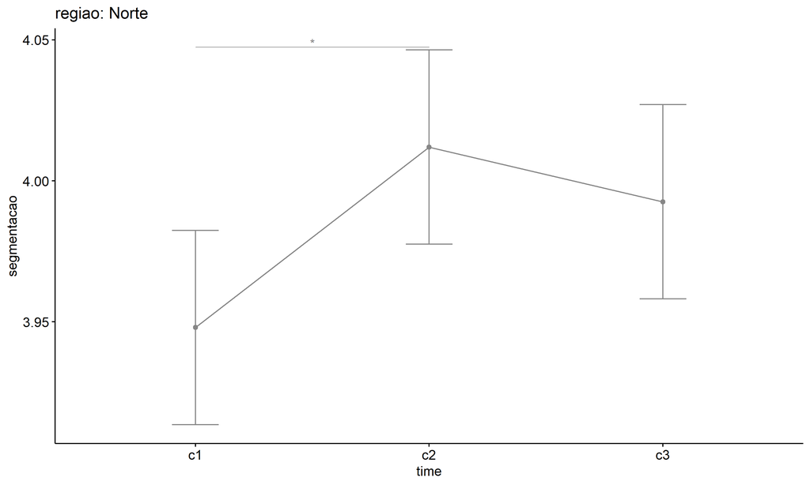

```r
emms.gg <- emms[which(emms$regiao == "Norte"),]
if (nrow(emms.gg) > 0)
  ggline(emms.gg, x = "time", y = "emmean", color = "#868686FF", ylab = "segmentacao") +
    geom_errorbar(aes(ymin = conf.low, ymax = conf.high),
                  width = 0.2, color = "#868686FF") +
    stat_pvalue_manual(
      add_xy_position(pwc[which(pwc$regiao == "Norte"),],
                      x = "time", fun = "mean_se"),
      hide.ns = T, color = "#868686FF", tip.length = F) +
    labs(title = "regiao: Norte")+
    theme(legend.text = element_blank())
```

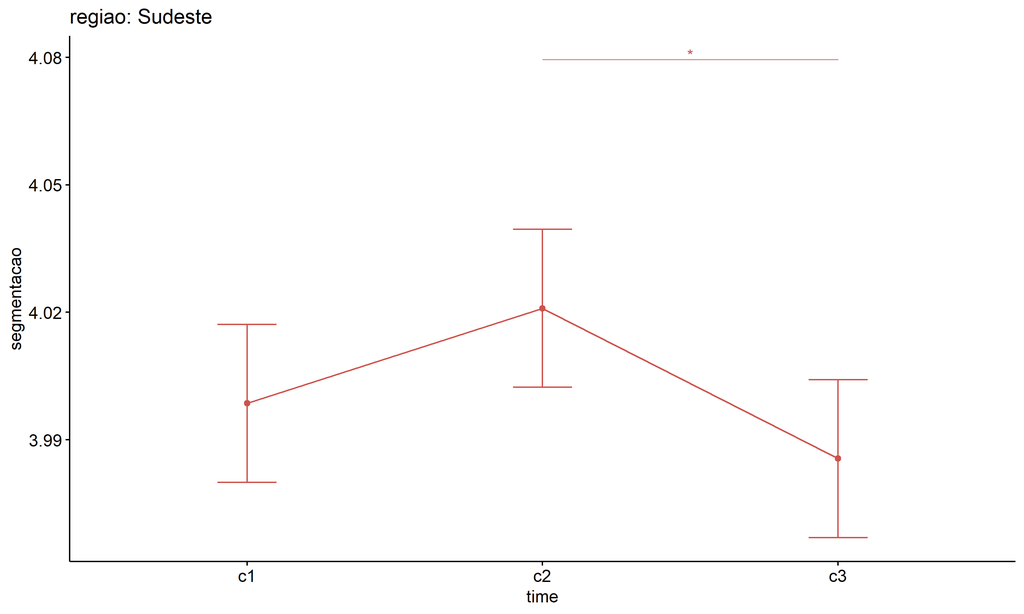

```r
emms.gg <- emms[which(emms$regiao == "Sudeste"),]
if (nrow(emms.gg) > 0)
  ggline(emms.gg, x = "time", y = "emmean", color = "#CD534CFF", ylab = "segmentacao") +
    geom_errorbar(aes(ymin = conf.low, ymax = conf.high),
                  width = 0.2, color = "#CD534CFF") +
    stat_pvalue_manual(
      add_xy_position(pwc[which(pwc$regiao == "Sudeste"),],
                      x = "time", fun = "mean_se"),
      hide.ns = T, color = "#CD534CFF", tip.length = F) +
    labs(title = "regiao: Sudeste")+
    theme(legend.text = element_blank())
```

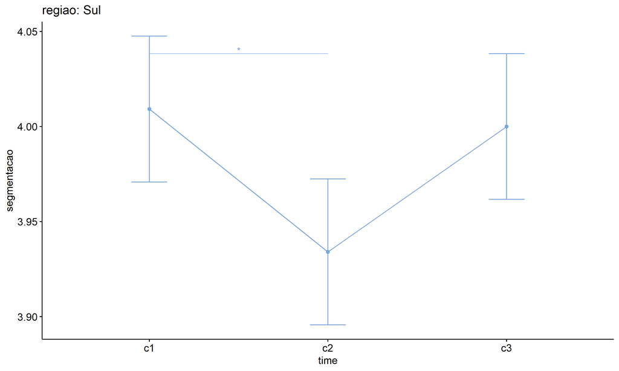

```r
emms.gg <- emms[which(emms$regiao == "Sul"),]
if (nrow(emms.gg) > 0)
  ggline(emms.gg, x = "time", y = "emmean", color = "#7AA6DCFF", ylab = "segmentacao") +
    geom_errorbar(aes(ymin = conf.low, ymax = conf.high),
                  width = 0.2, color = "#7AA6DCFF") +
    stat_pvalue_manual(
      add_xy_position(pwc[which(pwc$regiao == "Sul"),],
                      x = "time", fun = "mean_se"),
      hide.ns = T, color = "#7AA6DCFF", tip.length = F) +
    labs(title = "regiao: Sul")+
    theme(legend.text = element_blank())
```

## PairWise Computation after removing non.normal data

```r
if (length(non.ids) > 0)
  (pwc2 <- ldat2 %>% group_by(time) %>%
     emmeans_test(segmentacao ~ regiao, detailed = T, p.adjust.method = "bonferroni"))
```

```r
if (length(non.ids) > 0)
  (emms2 <- get_emmeans(pwc2))
```

```r
if (length(non.ids) > 0) {
  pwc2 <- add_xy_position(pwc2, x = "time", fun = "mean_se", dodge = 0.25)
  pd2 <- position_dodge(width = 0.25)

  ggline(emms2, x = "time", y = "emmean", color = "regiao",
         palette = c("#0073C2FF","#EFC000FF","#868686FF","#CD534CFF","#7AA6DCFF"),
         position = pd, ylab = "segmentacao") +
    geom_errorbar(aes(ymin = conf.low, ymax = conf.high, color = regiao),
                position = pd, width = 0.2) +
    stat_pvalue_manual(pwc2, hide.ns = T, tip.length = F, linetype = 1)
}
```

```r
if (length(non.ids) > 0)
  (pwc2 <- ldat2 %>% group_by(regiao) %>%
     emmeans_test(segmentacao ~ time, detailed = T, p.adjust.method = "bonferroni"))
```

```r
if (length(non.ids) > 0)
  (emms2 <- get_emmeans(pwc2))
```

```r
if (length(non.ids) > 0) {
  emms.gg <- emms2[which(emms2$regiao == "Centro-Oeste"),]
  if (nrow(emms.gg) > 0)
    ggline(emms.gg, x = "time", y = "emmean", color = "#0073C2FF", ylab = "segmentacao") +
    geom_errorbar(aes(ymin = conf.low, ymax = conf.high),
                  width = 0.2, color = "#0073C2FF") +
    stat_pvalue_manual(
      add_xy_position(pwc[which(pwc$regiao == "Centro-Oeste"),],
                      x = "time", fun = "mean_se"),
      hide.ns = T, color = "#0073C2FF", tip.length = F) +
    labs(title = "regiao: Centro-Oeste") +
    theme(legend.text = element_blank())
}
```

```r
if (length(non.ids) > 0) {
  emms.gg <- emms2[which(emms2$regiao == "Nordeste"),]
  if (nrow(emms.gg) > 0)
    ggline(emms.gg, x = "time", y = "emmean", color = "#EFC000FF", ylab = "segmentacao") +
    geom_errorbar(aes(ymin = conf.low, ymax = conf.high),
                  width = 0.2, color = "#EFC000FF") +
    stat_pvalue_manual(
      add_xy_position(pwc[which(pwc$regiao == "Nordeste"),],
                      x = "time", fun = "mean_se"),
      hide.ns = T, color = "#EFC000FF", tip.length = F) +
    labs(title = "regiao: Nordeste") +
    theme(legend.text = element_blank())
}
```

```r
if (length(non.ids) > 0) {
  emms.gg <- emms2[which(emms2$regiao == "Norte"),]
  if (nrow(emms.gg) > 0)
    ggline(emms.gg, x = "time", y = "emmean", color = "#868686FF", ylab = "segmentacao") +
    geom_errorbar(aes(ymin = conf.low, ymax = conf.high),
                  width = 0.2, color = "#868686FF") +
    stat_pvalue_manual(
      add_xy_position(pwc[which(pwc$regiao == "Norte"),],
                      x = "time", fun = "mean_se"),
      hide.ns = T, color = "#868686FF", tip.length = F) +
    labs(title = "regiao: Norte") +
    theme(legend.text = element_blank())
}
```

```r
if (length(non.ids) > 0) {
  emms.gg <- emms2[which(emms2$regiao == "Sudeste"),]
  if (nrow(emms.gg) > 0)
    ggline(emms.gg, x = "time", y = "emmean", color = "#CD534CFF", ylab = "segmentacao") +
    geom_errorbar(aes(ymin = conf.low, ymax = conf.high),
                  width = 0.2, color = "#CD534CFF") +
    stat_pvalue_manual(
      add_xy_position(pwc[which(pwc$regiao == "Sudeste"),],
                      x = "time", fun = "mean_se"),
      hide.ns = T, color = "#CD534CFF", tip.length = F) +
    labs(title = "regiao: Sudeste") +
    theme(legend.text = element_blank())
}
```

```r
if (length(non.ids) > 0) {
  emms.gg <- emms2[which(emms2$regiao == "Sul"),]
  if (nrow(emms.gg) > 0)
    ggline(emms.gg, x = "time", y = "emmean", color = "#7AA6DCFF", ylab = "segmentacao") +
    geom_errorbar(aes(ymin = conf.low, ymax = conf.high),
                  width = 0.2, color = "#7AA6DCFF") +
    stat_pvalue_manual(
      add_xy_position(pwc[which(pwc$regiao == "Sul"),],
                      x = "time", fun = "mean_se"),
      hide.ns = T, color = "#7AA6DCFF", tip.length = F) +
    labs(title = "regiao: Sul") +
    theme(legend.text = element_blank())
}
```

# ANOVA: segmentacao ~ time*porte + Error(id/time)

## Data Preparation

```r
data <- edat[,c("aluno_id","porte","ciclo","segmentacao")]
data <- data[data$ciclo %in% c("Primeiro Ciclo","Segundo Ciclo","Terceiro Ciclo"),]
data$ciclo <- factor(data$ciclo, c("Primeiro Ciclo","Segundo Ciclo","Terceiro Ciclo"))
data <- unique(data)

wdat <- spread(data, ciclo, segmentacao)
wdat <- wdat[complete.cases(wdat),]
colnames(wdat) <- c("id","porte","c1","c2","c3")

ldat <- gather(wdat, key = time, value = segmentacao, c1,c2,c3) %>%
  convert_as_factor(id, time)
ldat <- remove_group_data(ldat, "segmentacao", c("time", "porte"), n.limit = 30)
ldat$porte <- factor(ldat$porte, sort(unique(ldat$porte)))
```

### Check assumptions: Identifying Outliers

```r
outliers <- identify_outliers(group_by(ldat, time, porte), segmentacao)
(outliers <- outliers[outliers$is.extreme == T,])
```

```
## # A tibble: 871 × 6
##    porte                                       time  id                   segmentacao is.outlier is.extreme
##    <fct>                                       <fct> <fct>                      <dbl> <lgl>      <lgl>
##  1 Até 50 matrículas de escolarização          c1    aONYcyIz9jdWo9UGBKG0         5   TRUE       TRUE
##  2 Até 50 matrículas de escolarização          c1    KBTZEriJAFvcWw48Xxgc         3.5 TRUE       TRUE
##  3 Até 50 matrículas de escolarização          c1    pHKVHcBr54KlIgOzLPuV         5   TRUE       TRUE
##  4 Até 50 matrículas de escolarização          c1    ZHNhk1zpmerLG8ISdloo         3.5 TRUE       TRUE
##  5 Entre 201 e 500 matrículas de escolarização c1    0lMdjGzxsk7DwxFyTSwj         5   TRUE       TRUE
##  6 Entre 201 e 500 matrículas de escolarização c1    119JtIC0nJ3U9fE8LgBb         3   TRUE       TRUE
##  7 Entre 201 e 500 matrículas de escolarização c1    1Ao7d6oeWOGn5CkNSJxn         4.5 TRUE       TRUE
##  8 Entre 201 e 500 matrículas de escolarização c1    1rGKIQ7fdZBOxxGdPFrp         5   TRUE       TRUE
##  9 Entre 201 e 500 matrículas de escolarização c1    1TZ01wBCKMDHXq0YPfqx         3   TRUE       TRUE
## 10 Entre 201 e 500 matrículas de escolarização c1    2DxCaxzV0AiikIoPOoCv         3   TRUE       TRUE
## # ℹ 861 more rows
```

| porte | time | id | segmentacao | is.outlier | is.extreme |
| --- | --- | --- | --- | --- | --- |
| Até 50 matrículas de escolarização | c1 | aONYcyIz9jdWo9UGBKG0 | 5.000 | TRUE | TRUE |
| Até 50 matrículas de escolarização | c1 | KBTZEriJAFvcWw48Xxgc | 3.500 | TRUE | TRUE |
| Até 50 matrículas de escolarização | c1 | pHKVHcBr54KlIgOzLPuV | 5.000 | TRUE | TRUE |
| Até 50 matrículas de escolarização | c1 | ZHNhk1zpmerLG8ISdloo | 3.500 | TRUE | TRUE |
| Entre 201 e 500 matrículas de escolarização | c1 | 0lMdjGzxsk7DwxFyTSwj | 5.000 | TRUE | TRUE |
| Entre 201 e 500 matrículas de escolarização | c1 | 119JtIC0nJ3U9fE8LgBb | 3.000 | TRUE | TRUE |
| Entre 201 e 500 matrículas de escolarização | c1 | 1Ao7d6oeWOGn5CkNSJxn | 4.500 | TRUE | TRUE |
| Entre 201 e 500 matrículas de escolarização | c1 | 1rGKIQ7fdZBOxxGdPFrp | 5.000 | TRUE | TRUE |
| Entre 201 e 500 matrículas de escolarização | c1 | 1TZ01wBCKMDHXq0YPfqx | 3.000 | TRUE | TRUE |
| Entre 201 e 500 matrículas de escolarização | c1 | 2DxCaxzV0AiikIoPOoCv | 3.000 | TRUE | TRUE |
| Entre 201 e 500 matrículas de escolarização | c1 | 2qbgEyCWhU8ChVoKwmf5 | 5.000 | TRUE | TRUE |
| Entre 201 e 500 matrículas de escolarização | c1 | 3uYupr8T88FfksOyXDBI | 5.000 | TRUE | TRUE |
| Entre 201 e 500 matrículas de escolarização | c1 | 3yyME6BKuMMgDiylvD4A | 4.500 | TRUE | TRUE |
| Entre 201 e 500 matrículas de escolarização | c1 | 46nUNvt4sDOPsC9jnkiG | 3.500 | TRUE | TRUE |
| Entre 201 e 500 matrículas de escolarização | c1 | 47982aWE9x4sBhPIFY0I | 3.000 | TRUE | TRUE |
| Entre 201 e 500 matrículas de escolarização | c1 | 4AM4nonwJ45LiMy6b4lp | 4.500 | TRUE | TRUE |
| Entre 201 e 500 matrículas de escolarização | c1 | 4HW3bQquvKh2NSEqfBcz | 4.500 | TRUE | TRUE |
| Entre 201 e 500 matrículas de escolarização | c1 | 4tC0rHbjrsSU8gnHaaJ3 | 3.500 | TRUE | TRUE |
| Entre 201 e 500 matrículas de escolarização | c1 | 4uGbHDfm5mReIAb5vtDP | 5.000 | TRUE | TRUE |
| Entre 201 e 500 matrículas de escolarização | c1 | 4VbspBZhrRRWioLlwqZL | 4.500 | TRUE | TRUE |
| Entre 201 e 500 matrículas de escolarização | c1 | 53lsfK6za4noVZe68et6 | 3.000 | TRUE | TRUE |
| Entre 201 e 500 matrículas de escolarização | c1 | 5AeP0IQ84CerIQVenp2G | 4.500 | TRUE | TRUE |
| Entre 201 e 500 matrículas de escolarização | c1 | 5aLGVYNAMR84kxneNKFw | 3.000 | TRUE | TRUE |
| Entre 201 e 500 matrículas de escolarização | c1 | 5APBeicSvcegSPf9KOQj | 3.500 | TRUE | TRUE |
| Entre 201 e 500 matrículas de escolarização | c1 | 5L0i2IEXTfnYHY8uygsP | 3.500 | TRUE | TRUE |
| Entre 201 e 500 matrículas de escolarização | c1 | 5QtCqrFr3U8v5JZWaJI1 | 5.000 | TRUE | TRUE |
| Entre 201 e 500 matrículas de escolarização | c1 | 5WOchSZgUhx0OWTzb7cj | 3.000 | TRUE | TRUE |
| Entre 201 e 500 matrículas de escolarização | c1 | 5zZ1GeniMVX6uMy5Wsj5 | 3.500 | TRUE | TRUE |
| Entre 201 e 500 matrículas de escolarização | c1 | 7AsCrRYMyhVRQHX4kZdc | 3.000 | TRUE | TRUE |
| Entre 201 e 500 matrículas de escolarização | c1 | 7g3GunKKkHWAtnvcV4AX | 4.500 | TRUE | TRUE |

[output cut: 841 more lines]

### Check assumptions: Normality Test

```r
(normality.df <- normality.test.per.groups(ldat, "segmentacao", c("time", "porte")))
```

```
##            var    variable time                                        porte    n    skewness  kurtosis symmetry statistic
## 1  segmentacao segmentacao   c1           Até 50 matrículas de escolarização   83  0.00000000  0.000000 few data        NA
## 2  segmentacao segmentacao   c1  Entre 201 e 500 matrículas de escolarização 1529 -0.23209849  6.580120       NO 227.96208
## 3  segmentacao segmentacao   c1 Entre 501 e 1000 matrículas de escolarização  618  0.24893975  6.745742       NO 100.64228
## 4  segmentacao segmentacao   c1   Entre 51 e 200 matrículas de escolarização  473  0.05778716  7.365736       NO  79.29454
## 5  segmentacao segmentacao   c1     Mais de 1000 matrículas de escolarização   70 -0.48851928  6.015924       NO  21.49594
## 6  segmentacao segmentacao   c2           Até 50 matrículas de escolarização   83  1.83073227 14.800438       NO  62.67807
## 7  segmentacao segmentacao   c2  Entre 201 e 500 matrículas de escolarização 1529  0.85180879  9.755997       NO 417.62203
## 8  segmentacao segmentacao   c2 Entre 501 e 1000 matrículas de escolarização  618  0.15402656 12.640004       NO 138.90541
## 9  segmentacao segmentacao   c2   Entre 51 e 200 matrículas de escolarização  473 -0.34306127 10.158322       NO 105.11294
## 10 segmentacao segmentacao   c2     Mais de 1000 matrículas de escolarização   70  0.00000000  0.000000 few data        NA
## 11 segmentacao segmentacao   c3           Até 50 matrículas de escolarização   83  3.26773219 27.971687       NO  98.62598
## 12 segmentacao segmentacao   c3  Entre 201 e 500 matrículas de escolarização 1529 -0.71544151 16.045909       NO 461.72600
## 13 segmentacao segmentacao   c3 Entre 501 e 1000 matrículas de escolarização  618  0.74478446 18.171762       NO 209.24860
## 14 segmentacao segmentacao   c3   Entre 51 e 200 matrículas de escolarização  473 -0.34229560 12.740665       NO 117.42660
```

[output cut: 17 more lines]

| var | variable | time | porte | n | skewness | kurtosis | symmetry | statistic | method | p | p.signif | normality |
| --- | --- | --- | --- | --- | --- | --- | --- | --- | --- | --- | --- | --- |
| segmentacao | segmentacao | c1 | Até 50 matrículas de escolarização | 83 | 0.000 | 0.000 | few data | NA | NA | 1 | NA | NO |
| segmentacao | segmentacao | c1 | Entre 201 e 500 matrículas de escolarização | 1529 | -0.232 | 6.580 | NO | 227.962 | D’Agostino | 0 | **** | - |
| segmentacao | segmentacao | c1 | Entre 501 e 1000 matrículas de escolarização | 618 | 0.249 | 6.746 | NO | 100.642 | D’Agostino | 0 | **** | - |
| segmentacao | segmentacao | c1 | Entre 51 e 200 matrículas de escolarização | 473 | 0.058 | 7.366 | NO | 79.295 | D’Agostino | 0 | **** | - |
| segmentacao | segmentacao | c1 | Mais de 1000 matrículas de escolarização | 70 | -0.489 | 6.016 | NO | 21.496 | D’Agostino | 0 | **** | NO |
| segmentacao | segmentacao | c2 | Até 50 matrículas de escolarização | 83 | 1.831 | 14.800 | NO | 62.678 | D’Agostino | 0 | **** | NO |
| segmentacao | segmentacao | c2 | Entre 201 e 500 matrículas de escolarização | 1529 | 0.852 | 9.756 | NO | 417.622 | D’Agostino | 0 | **** | - |
| segmentacao | segmentacao | c2 | Entre 501 e 1000 matrículas de escolarização | 618 | 0.154 | 12.640 | NO | 138.905 | D’Agostino | 0 | **** | - |
| segmentacao | segmentacao | c2 | Entre 51 e 200 matrículas de escolarização | 473 | -0.343 | 10.158 | NO | 105.113 | D’Agostino | 0 | **** | - |
| segmentacao | segmentacao | c2 | Mais de 1000 matrículas de escolarização | 70 | 0.000 | 0.000 | few data | NA | NA | 1 | NA | NO |
| segmentacao | segmentacao | c3 | Até 50 matrículas de escolarização | 83 | 3.268 | 27.972 | NO | 98.626 | D’Agostino | 0 | **** | NO |
| segmentacao | segmentacao | c3 | Entre 201 e 500 matrículas de escolarização | 1529 | -0.715 | 16.046 | NO | 461.726 | D’Agostino | 0 | **** | - |
| segmentacao | segmentacao | c3 | Entre 501 e 1000 matrículas de escolarização | 618 | 0.745 | 18.172 | NO | 209.249 | D’Agostino | 0 | **** | - |
| segmentacao | segmentacao | c3 | Entre 51 e 200 matrículas de escolarização | 473 | -0.342 | 12.741 | NO | 117.427 | D’Agostino | 0 | **** | - |
| segmentacao | segmentacao | c3 | Mais de 1000 matrículas de escolarização | 70 | 0.000 | 0.000 | few data | NA | NA | 1 | NA | NO |

```r
(non.ids <- unique(do.call(
  c, lapply(which(normality.df$normality == 'NO'), FUN = function(i) {
  idx = which(ldat$time == normality.df$time[i] &
                ldat$porte == normality.df$porte[i])
  getNonNormal(ldat$"segmentacao"[idx], ldat$id[idx])
}))))
```

```
## [1] "ijRxNrSrW0oX4pjrOD7X" "wzpfVmENuwkQHmrYv7Vs" "wmMgYtTDXMi7lGWVukYs" "DwTeMtAHL6Xl0Wvt0djz" "dESFdovgEOeqMIXSwXsu"
```

```r
if (length(non.ids) > 0)
  ldat2 <- ldat[!ldat$id %in% non.ids,]
```

### Summary Statistics

```r
(sdat <- ldat %>% group_by(time, porte) %>%
   get_summary_stats(segmentacao, type = "mean_sd"))
```

```
## # A tibble: 15 × 6
##    porte                                        time  variable        n  mean    sd
##    <fct>                                        <fct> <fct>       <dbl> <dbl> <dbl>
##  1 Até 50 matrículas de escolarização           c1    segmentacao    83  4.01 0.174
##  2 Entre 201 e 500 matrículas de escolarização  c1    segmentacao  1529  4.01 0.295
##  3 Entre 501 e 1000 matrículas de escolarização c1    segmentacao   618  4.02 0.301
##  4 Entre 51 e 200 matrículas de escolarização   c1    segmentacao   473  4.02 0.293
##  5 Mais de 1000 matrículas de escolarização     c1    segmentacao    70  4.02 0.275
##  6 Até 50 matrículas de escolarização           c2    segmentacao    83  4.03 0.226
##  7 Entre 201 e 500 matrículas de escolarização  c2    segmentacao  1529  4.03 0.253
##  8 Entre 501 e 1000 matrículas de escolarização c2    segmentacao   618  4.01 0.237
##  9 Entre 51 e 200 matrículas de escolarização   c2    segmentacao   473  3.99 0.251
## 10 Mais de 1000 matrículas de escolarização     c2    segmentacao    70  4    0.12
## 11 Até 50 matrículas de escolarização           c3    segmentacao    83  4.01 0.146
## 12 Entre 201 e 500 matrículas de escolarização  c3    segmentacao  1529  4.00 0.199
## 13 Entre 501 e 1000 matrículas de escolarização c3    segmentacao   618  4.01 0.196
## 14 Entre 51 e 200 matrículas de escolarização   c3    segmentacao   473  3.99 0.231
## 15 Mais de 1000 matrículas de escolarização     c3    segmentacao    70  3.94 0.24
```

| porte | time | variable | n | mean | sd |
| --- | --- | --- | --- | --- | --- |
| Até 50 matrículas de escolarização | c1 | segmentacao | 83 | 4.012 | 0.174 |
| Entre 201 e 500 matrículas de escolarização | c1 | segmentacao | 1529 | 4.009 | 0.295 |
| Entre 501 e 1000 matrículas de escolarização | c1 | segmentacao | 618 | 4.022 | 0.301 |
| Entre 51 e 200 matrículas de escolarização | c1 | segmentacao | 473 | 4.016 | 0.293 |
| Mais de 1000 matrículas de escolarização | c1 | segmentacao | 70 | 4.021 | 0.275 |
| Até 50 matrículas de escolarização | c2 | segmentacao | 83 | 4.030 | 0.226 |
| Entre 201 e 500 matrículas de escolarização | c2 | segmentacao | 1529 | 4.026 | 0.253 |
| Entre 501 e 1000 matrículas de escolarização | c2 | segmentacao | 618 | 4.009 | 0.237 |
| Entre 51 e 200 matrículas de escolarização | c2 | segmentacao | 473 | 3.993 | 0.251 |
| Mais de 1000 matrículas de escolarização | c2 | segmentacao | 70 | 4.000 | 0.120 |
| Até 50 matrículas de escolarização | c3 | segmentacao | 83 | 4.006 | 0.146 |
| Entre 201 e 500 matrículas de escolarização | c3 | segmentacao | 1529 | 3.998 | 0.199 |
| Entre 501 e 1000 matrículas de escolarização | c3 | segmentacao | 618 | 4.006 | 0.196 |
| Entre 51 e 200 matrículas de escolarização | c3 | segmentacao | 473 | 3.988 | 0.231 |
| Mais de 1000 matrículas de escolarização | c3 | segmentacao | 70 | 3.936 | 0.240 |

```r
if (length(non.ids) > 0)
  (sdat <- ldat2 %>% group_by(time, porte) %>%
      get_summary_stats(segmentacao, type = "mean_sd"))
```

```
## # A tibble: 15 × 6
##    porte                                        time  variable        n  mean    sd
##    <fct>                                        <fct> <fct>       <dbl> <dbl> <dbl>
##  1 Até 50 matrículas de escolarização           c1    segmentacao    81  4.01 0.176
##  2 Entre 201 e 500 matrículas de escolarização  c1    segmentacao  1529  4.01 0.295
##  3 Entre 501 e 1000 matrículas de escolarização c1    segmentacao   618  4.02 0.301
##  4 Entre 51 e 200 matrículas de escolarização   c1    segmentacao   473  4.02 0.293
##  5 Mais de 1000 matrículas de escolarização     c1    segmentacao    67  4.04 0.181
##  6 Até 50 matrículas de escolarização           c2    segmentacao    81  4.04 0.197
##  7 Entre 201 e 500 matrículas de escolarização  c2    segmentacao  1529  4.03 0.253
##  8 Entre 501 e 1000 matrículas de escolarização c2    segmentacao   618  4.01 0.237
##  9 Entre 51 e 200 matrículas de escolarização   c2    segmentacao   473  3.99 0.251
## 10 Mais de 1000 matrículas de escolarização     c2    segmentacao    67  4    0.123
## 11 Até 50 matrículas de escolarização           c3    segmentacao    81  3.99 0.097
## 12 Entre 201 e 500 matrículas de escolarização  c3    segmentacao  1529  4.00 0.199
## 13 Entre 501 e 1000 matrículas de escolarização c3    segmentacao   618  4.01 0.196
## 14 Entre 51 e 200 matrículas de escolarização   c3    segmentacao   473  3.99 0.231
## 15 Mais de 1000 matrículas de escolarização     c3    segmentacao    67  3.93 0.245
```

| porte | time | variable | n | mean | sd |
| --- | --- | --- | --- | --- | --- |
| Até 50 matrículas de escolarização | c1 | segmentacao | 81 | 4.012 | 0.176 |
| Entre 201 e 500 matrículas de escolarização | c1 | segmentacao | 1529 | 4.009 | 0.295 |
| Entre 501 e 1000 matrículas de escolarização | c1 | segmentacao | 618 | 4.022 | 0.301 |
| Entre 51 e 200 matrículas de escolarização | c1 | segmentacao | 473 | 4.016 | 0.293 |
| Mais de 1000 matrículas de escolarização | c1 | segmentacao | 67 | 4.037 | 0.181 |
| Até 50 matrículas de escolarização | c2 | segmentacao | 81 | 4.043 | 0.197 |
| Entre 201 e 500 matrículas de escolarização | c2 | segmentacao | 1529 | 4.026 | 0.253 |
| Entre 501 e 1000 matrículas de escolarização | c2 | segmentacao | 618 | 4.009 | 0.237 |
| Entre 51 e 200 matrículas de escolarização | c2 | segmentacao | 473 | 3.993 | 0.251 |
| Mais de 1000 matrículas de escolarização | c2 | segmentacao | 67 | 4.000 | 0.123 |
| Até 50 matrículas de escolarização | c3 | segmentacao | 81 | 3.994 | 0.097 |
| Entre 201 e 500 matrículas de escolarização | c3 | segmentacao | 1529 | 3.998 | 0.199 |
| Entre 501 e 1000 matrículas de escolarização | c3 | segmentacao | 618 | 4.006 | 0.196 |
| Entre 51 e 200 matrículas de escolarização | c3 | segmentacao | 473 | 3.988 | 0.231 |
| Mais de 1000 matrículas de escolarização | c3 | segmentacao | 67 | 3.933 | 0.245 |

## ANOVA Computation

```r
(res.aov <- anova_test(ldat, dv = segmentacao, wid = id, between = porte, within = time))
```

```
## ANOVA Table (type III tests)
##
## $ANOVA
##       Effect DFn  DFd     F     p p<.05      ges
## 1      porte   4 2768 1.126 0.342       0.000578
## 2       time   2 5536 3.343 0.035     * 0.000778
## 3 porte:time   8 5536 1.261 0.259       0.001000
##
## $`Mauchly's Test for Sphericity`
##       Effect     W                          p p<.05
## 1       time 0.965 0.000000000000000000000256     *
## 2 porte:time 0.965 0.000000000000000000000256     *
##
## $`Sphericity Corrections`
##       Effect   GGe        DF[GG] p[GG] p[GG]<.05   HFe        DF[HF] p[HF] p[HF]<.05
## 1       time 0.966 1.93, 5347.25 0.037         * 0.967 1.93, 5350.92 0.037         *
## 2 porte:time 0.966 7.73, 5347.25 0.261           0.967 7.73, 5350.92 0.261
```

| Effect | DFn | DFd | F | p | p<.05 | ges |
| --- | --- | --- | --- | --- | --- | --- |
| porte | 4 | 2768 | 1.126 | 0.342 |  | 0.001 |
| time | 2 | 5536 | 3.343 | 0.035 | * | 0.001 |
| porte:time | 8 | 5536 | 1.261 | 0.259 |  | 0.001 |

| Effect | W | p | p<.05 |
| --- | --- | --- | --- |
| time | 0.965 | 0 | * |
| porte:time | 0.965 | 0 | * |

| Effect | GGe | DF[GG] | p[GG] | p[GG]<.05 | HFe | DF[HF] | p[HF] | p[HF]<.05 |
| --- | --- | --- | --- | --- | --- | --- | --- | --- |
| time | 0.966 | 1.93, 5347.25 | 0.037 | * | 0.967 | 1.93, 5350.92 | 0.037 | * |
| porte:time | 0.966 | 7.73, 5347.25 | 0.261 |  | 0.967 | 7.73, 5350.92 | 0.261 |  |

## ANOVA Computation after removing non.normal data

```r
if (length(non.ids) > 0)
  (res.aov2 <- anova_test(ldat2, dv = segmentacao, wid = id, between = porte , within = time))
```

```
## ANOVA Table (type III tests)
##
## $ANOVA
##       Effect DFn  DFd     F     p p<.05      ges
## 1      porte   4 2763 0.984 0.415       0.000506
## 2       time   2 5526 4.856 0.008     * 0.001000
## 3 porte:time   8 5526 1.525 0.143       0.001000
##
## $`Mauchly's Test for Sphericity`
##       Effect     W                          p p<.05
## 1       time 0.965 0.000000000000000000000687     *
## 2 porte:time 0.965 0.000000000000000000000687     *
##
## $`Sphericity Corrections`
##       Effect   GGe        DF[GG] p[GG] p[GG]<.05   HFe       DF[HF] p[HF] p[HF]<.05
## 1       time 0.966 1.93, 5340.83 0.009         * 0.967 1.93, 5344.5 0.008         *
## 2 porte:time 0.966 7.73, 5340.83 0.146           0.967 7.74, 5344.5 0.146
```

| Effect | DFn | DFd | F | p | p<.05 | ges |
| --- | --- | --- | --- | --- | --- | --- |
| porte | 4 | 2763 | 0.984 | 0.415 |  | 0.001 |
| time | 2 | 5526 | 4.856 | 0.008 | * | 0.001 |
| porte:time | 8 | 5526 | 1.525 | 0.143 |  | 0.001 |

| Effect | W | p | p<.05 |
| --- | --- | --- | --- |
| time | 0.965 | 0 | * |
| porte:time | 0.965 | 0 | * |

| Effect | GGe | DF[GG] | p[GG] | p[GG]<.05 | HFe | DF[HF] | p[HF] | p[HF]<.05 |
| --- | --- | --- | --- | --- | --- | --- | --- | --- |
| time | 0.966 | 1.93, 5340.83 | 0.009 | * | 0.967 | 1.93, 5344.5 | 0.008 | * |
| porte:time | 0.966 | 7.73, 5340.83 | 0.146 |  | 0.967 | 7.74, 5344.5 | 0.146 |  |

## PairWise Computation

```r
(pwc <- ldat %>% group_by(time) %>%
   emmeans_test(segmentacao ~ porte, detailed = T, p.adjust.method = "bonferroni"))
```

```
## # A tibble: 30 × 15
##    time  term  .y.         group1  group2 null.value estimate     se    df conf.low conf.high statistic     p p.adj p.adj.signif
##  * <fct> <chr> <chr>       <chr>   <chr>       <dbl>    <dbl>  <dbl> <dbl>    <dbl>     <dbl>     <dbl> <dbl> <dbl> <chr>
##  1 c1    porte segmentacao Até 50… Entre…          0  3.55e-3 0.0282  8304  -0.0517    0.0588    0.126  0.900     1 ns
##  2 c1    porte segmentacao Até 50… Entre…          0 -9.80e-3 0.0293  8304  -0.0671    0.0475   -0.335  0.738     1 ns
##  3 c1    porte segmentacao Até 50… Entre…          0 -3.81e-3 0.0298  8304  -0.0622    0.0546   -0.128  0.898     1 ns
##  4 c1    porte segmentacao Até 50… Mais …          0 -9.38e-3 0.0406  8304  -0.0890    0.0702   -0.231  0.817     1 ns
##  5 c1    porte segmentacao Entre … Entre…          0 -1.33e-2 0.0119  8304  -0.0367    0.0100   -1.12   0.263     1 ns
##  6 c1    porte segmentacao Entre … Entre…          0 -7.35e-3 0.0132  8304  -0.0332    0.0185   -0.559  0.576     1 ns
##  7 c1    porte segmentacao Entre … Mais …          0 -1.29e-2 0.0306  8304  -0.0729    0.0470   -0.423  0.673     1 ns
##  8 c1    porte segmentacao Entre … Entre…          0  5.99e-3 0.0153  8304  -0.0240    0.0360    0.392  0.695     1 ns
##  9 c1    porte segmentacao Entre … Mais …          0  4.16e-4 0.0316  8304  -0.0614    0.0623    0.0132 0.989     1 ns
## 10 c1    porte segmentacao Entre … Mais …          0 -5.57e-3 0.0320  8304  -0.0684    0.0572   -0.174  0.862     1 ns
## # ℹ 20 more rows
```

| time | term | .y. | group1 | group2 | null.value | estimate | se | df | conf.low | conf.high | statistic | p | p.adj | p.adj.signif |
| --- | --- | --- | --- | --- | --- | --- | --- | --- | --- | --- | --- | --- | --- | --- |
| c1 | porte | segmentacao | Até 50 matrículas de escolarização | Entre 201 e 500 matrículas de escolarização | 0 | 0.004 | 0.028 | 8304 | -0.052 | 0.059 | 0.126 | 0.900 | 1.000 | ns |
| c1 | porte | segmentacao | Até 50 matrículas de escolarização | Entre 501 e 1000 matrículas de escolarização | 0 | -0.010 | 0.029 | 8304 | -0.067 | 0.048 | -0.335 | 0.738 | 1.000 | ns |
| c1 | porte | segmentacao | Até 50 matrículas de escolarização | Entre 51 e 200 matrículas de escolarização | 0 | -0.004 | 0.030 | 8304 | -0.062 | 0.055 | -0.128 | 0.898 | 1.000 | ns |
| c1 | porte | segmentacao | Até 50 matrículas de escolarização | Mais de 1000 matrículas de escolarização | 0 | -0.009 | 0.041 | 8304 | -0.089 | 0.070 | -0.231 | 0.817 | 1.000 | ns |
| c1 | porte | segmentacao | Entre 201 e 500 matrículas de escolarização | Entre 501 e 1000 matrículas de escolarização | 0 | -0.013 | 0.012 | 8304 | -0.037 | 0.010 | -1.119 | 0.263 | 1.000 | ns |
| c1 | porte | segmentacao | Entre 201 e 500 matrículas de escolarização | Entre 51 e 200 matrículas de escolarização | 0 | -0.007 | 0.013 | 8304 | -0.033 | 0.018 | -0.559 | 0.576 | 1.000 | ns |
| c1 | porte | segmentacao | Entre 201 e 500 matrículas de escolarização | Mais de 1000 matrículas de escolarização | 0 | -0.013 | 0.031 | 8304 | -0.073 | 0.047 | -0.423 | 0.673 | 1.000 | ns |
| c1 | porte | segmentacao | Entre 501 e 1000 matrículas de escolarização | Entre 51 e 200 matrículas de escolarização | 0 | 0.006 | 0.015 | 8304 | -0.024 | 0.036 | 0.392 | 0.695 | 1.000 | ns |
| c1 | porte | segmentacao | Entre 501 e 1000 matrículas de escolarização | Mais de 1000 matrículas de escolarização | 0 | 0.000 | 0.032 | 8304 | -0.061 | 0.062 | 0.013 | 0.989 | 1.000 | ns |
| c1 | porte | segmentacao | Entre 51 e 200 matrículas de escolarização | Mais de 1000 matrículas de escolarização | 0 | -0.006 | 0.032 | 8304 | -0.068 | 0.057 | -0.174 | 0.862 | 1.000 | ns |
| c2 | porte | segmentacao | Até 50 matrículas de escolarização | Entre 201 e 500 matrículas de escolarização | 0 | 0.004 | 0.028 | 8304 | -0.051 | 0.059 | 0.146 | 0.884 | 1.000 | ns |
| c2 | porte | segmentacao | Até 50 matrículas de escolarização | Entre 501 e 1000 matrículas de escolarização | 0 | 0.021 | 0.029 | 8304 | -0.036 | 0.078 | 0.716 | 0.474 | 1.000 | ns |
| c2 | porte | segmentacao | Até 50 matrículas de escolarização | Entre 51 e 200 matrículas de escolarização | 0 | 0.037 | 0.030 | 8304 | -0.021 | 0.096 | 1.254 | 0.210 | 1.000 | ns |
| c2 | porte | segmentacao | Até 50 matrículas de escolarização | Mais de 1000 matrículas de escolarização | 0 | 0.030 | 0.041 | 8304 | -0.049 | 0.110 | 0.742 | 0.458 | 1.000 | ns |
| c2 | porte | segmentacao | Entre 201 e 500 matrículas de escolarização | Entre 501 e 1000 matrículas de escolarização | 0 | 0.017 | 0.012 | 8304 | -0.007 | 0.040 | 1.411 | 0.158 | 1.000 | ns |
| c2 | porte | segmentacao | Entre 201 e 500 matrículas de escolarização | Entre 51 e 200 matrículas de escolarização | 0 | 0.033 | 0.013 | 8304 | 0.007 | 0.059 | 2.523 | 0.012 | 0.116 | ns |
| c2 | porte | segmentacao | Entre 201 e 500 matrículas de escolarização | Mais de 1000 matrículas de escolarização | 0 | 0.026 | 0.031 | 8304 | -0.034 | 0.086 | 0.850 | 0.395 | 1.000 | ns |
| c2 | porte | segmentacao | Entre 501 e 1000 matrículas de escolarização | Entre 51 e 200 matrículas de escolarização | 0 | 0.016 | 0.015 | 8304 | -0.014 | 0.046 | 1.072 | 0.284 | 1.000 | ns |
| c2 | porte | segmentacao | Entre 501 e 1000 matrículas de escolarização | Mais de 1000 matrículas de escolarização | 0 | 0.009 | 0.032 | 8304 | -0.053 | 0.071 | 0.291 | 0.771 | 1.000 | ns |
| c2 | porte | segmentacao | Entre 51 e 200 matrículas de escolarização | Mais de 1000 matrículas de escolarização | 0 | -0.007 | 0.032 | 8304 | -0.070 | 0.056 | -0.225 | 0.822 | 1.000 | ns |
| c3 | porte | segmentacao | Até 50 matrículas de escolarização | Entre 201 e 500 matrículas de escolarização | 0 | 0.008 | 0.028 | 8304 | -0.047 | 0.063 | 0.291 | 0.771 | 1.000 | ns |
| c3 | porte | segmentacao | Até 50 matrículas de escolarização | Entre 501 e 1000 matrículas de escolarização | 0 | 0.000 | 0.029 | 8304 | -0.057 | 0.058 | 0.012 | 0.990 | 1.000 | ns |
| c3 | porte | segmentacao | Até 50 matrículas de escolarização | Entre 51 e 200 matrículas de escolarização | 0 | 0.018 | 0.030 | 8304 | -0.041 | 0.076 | 0.593 | 0.553 | 1.000 | ns |
| c3 | porte | segmentacao | Até 50 matrículas de escolarização | Mais de 1000 matrículas de escolarização | 0 | 0.070 | 0.041 | 8304 | -0.009 | 0.150 | 1.732 | 0.083 | 0.834 | ns |
| c3 | porte | segmentacao | Entre 201 e 500 matrículas de escolarização | Entre 501 e 1000 matrículas de escolarização | 0 | -0.008 | 0.012 | 8304 | -0.031 | 0.016 | -0.658 | 0.511 | 1.000 | ns |
| c3 | porte | segmentacao | Entre 201 e 500 matrículas de escolarização | Entre 51 e 200 matrículas de escolarização | 0 | 0.009 | 0.013 | 8304 | -0.016 | 0.035 | 0.718 | 0.473 | 1.000 | ns |
| c3 | porte | segmentacao | Entre 201 e 500 matrículas de escolarização | Mais de 1000 matrículas de escolarização | 0 | 0.062 | 0.031 | 8304 | 0.002 | 0.122 | 2.031 | 0.042 | 0.423 | ns |
| c3 | porte | segmentacao | Entre 501 e 1000 matrículas de escolarização | Entre 51 e 200 matrículas de escolarização | 0 | 0.017 | 0.015 | 8304 | -0.013 | 0.047 | 1.131 | 0.258 | 1.000 | ns |
| c3 | porte | segmentacao | Entre 501 e 1000 matrículas de escolarização | Mais de 1000 matrículas de escolarização | 0 | 0.070 | 0.032 | 8304 | 0.008 | 0.132 | 2.217 | 0.027 | 0.267 | ns |
| c3 | porte | segmentacao | Entre 51 e 200 matrículas de escolarização | Mais de 1000 matrículas de escolarização | 0 | 0.053 | 0.032 | 8304 | -0.010 | 0.115 | 1.643 | 0.100 | 1.000 | ns |

```r
(emms <- get_emmeans(pwc))
```

```
## # A tibble: 15 × 8
##    time  porte                                        emmean      se    df conf.low conf.high method
##    <fct> <fct>                                         <dbl>   <dbl> <dbl>    <dbl>     <dbl> <chr>
##  1 c1    Até 50 matrículas de escolarização             4.01 0.0275   8304     3.96      4.07 Emmeans test
##  2 c1    Entre 201 e 500 matrículas de escolarização    4.01 0.00640  8304     4.00      4.02 Emmeans test
##  3 c1    Entre 501 e 1000 matrículas de escolarização   4.02 0.0101   8304     4.00      4.04 Emmeans test
##  4 c1    Entre 51 e 200 matrículas de escolarização     4.02 0.0115   8304     3.99      4.04 Emmeans test
##  5 c1    Mais de 1000 matrículas de escolarização       4.02 0.0299   8304     3.96      4.08 Emmeans test
##  6 c2    Até 50 matrículas de escolarização             4.03 0.0275   8304     3.98      4.08 Emmeans test
##  7 c2    Entre 201 e 500 matrículas de escolarização    4.03 0.00640  8304     4.01      4.04 Emmeans test
##  8 c2    Entre 501 e 1000 matrículas de escolarização   4.01 0.0101   8304     3.99      4.03 Emmeans test
##  9 c2    Entre 51 e 200 matrículas de escolarização     3.99 0.0115   8304     3.97      4.02 Emmeans test
## 10 c2    Mais de 1000 matrículas de escolarização       4.00 0.0299   8304     3.94      4.06 Emmeans test
## 11 c3    Até 50 matrículas de escolarização             4.01 0.0275   8304     3.95      4.06 Emmeans test
## 12 c3    Entre 201 e 500 matrículas de escolarização    4.00 0.00640  8304     3.99      4.01 Emmeans test
## 13 c3    Entre 501 e 1000 matrículas de escolarização   4.01 0.0101   8304     3.99      4.03 Emmeans test
## 14 c3    Entre 51 e 200 matrículas de escolarização     3.99 0.0115   8304     3.97      4.01 Emmeans test
## 15 c3    Mais de 1000 matrículas de escolarização       3.94 0.0299   8304     3.88      3.99 Emmeans test
```

| time | porte | emmean | se | df | conf.low | conf.high | method |
| --- | --- | --- | --- | --- | --- | --- | --- |
| c1 | Até 50 matrículas de escolarização | 4.012 | 0.027 | 8304 | 3.958 | 4.066 | Emmeans test |
| c1 | Entre 201 e 500 matrículas de escolarização | 4.009 | 0.006 | 8304 | 3.996 | 4.021 | Emmeans test |
| c1 | Entre 501 e 1000 matrículas de escolarização | 4.022 | 0.010 | 8304 | 4.002 | 4.042 | Emmeans test |
| c1 | Entre 51 e 200 matrículas de escolarização | 4.016 | 0.012 | 8304 | 3.993 | 4.038 | Emmeans test |
| c1 | Mais de 1000 matrículas de escolarização | 4.021 | 0.030 | 8304 | 3.963 | 4.080 | Emmeans test |
| c2 | Até 50 matrículas de escolarização | 4.030 | 0.027 | 8304 | 3.976 | 4.084 | Emmeans test |
| c2 | Entre 201 e 500 matrículas de escolarização | 4.026 | 0.006 | 8304 | 4.013 | 4.039 | Emmeans test |
| c2 | Entre 501 e 1000 matrículas de escolarização | 4.009 | 0.010 | 8304 | 3.989 | 4.029 | Emmeans test |
| c2 | Entre 51 e 200 matrículas de escolarização | 3.993 | 0.012 | 8304 | 3.970 | 4.015 | Emmeans test |
| c2 | Mais de 1000 matrículas de escolarização | 4.000 | 0.030 | 8304 | 3.941 | 4.059 | Emmeans test |
| c3 | Até 50 matrículas de escolarização | 4.006 | 0.027 | 8304 | 3.952 | 4.060 | Emmeans test |
| c3 | Entre 201 e 500 matrículas de escolarização | 3.998 | 0.006 | 8304 | 3.985 | 4.010 | Emmeans test |
| c3 | Entre 501 e 1000 matrículas de escolarização | 4.006 | 0.010 | 8304 | 3.986 | 4.025 | Emmeans test |
| c3 | Entre 51 e 200 matrículas de escolarização | 3.988 | 0.012 | 8304 | 3.966 | 4.011 | Emmeans test |
| c3 | Mais de 1000 matrículas de escolarização | 3.936 | 0.030 | 8304 | 3.877 | 3.994 | Emmeans test |

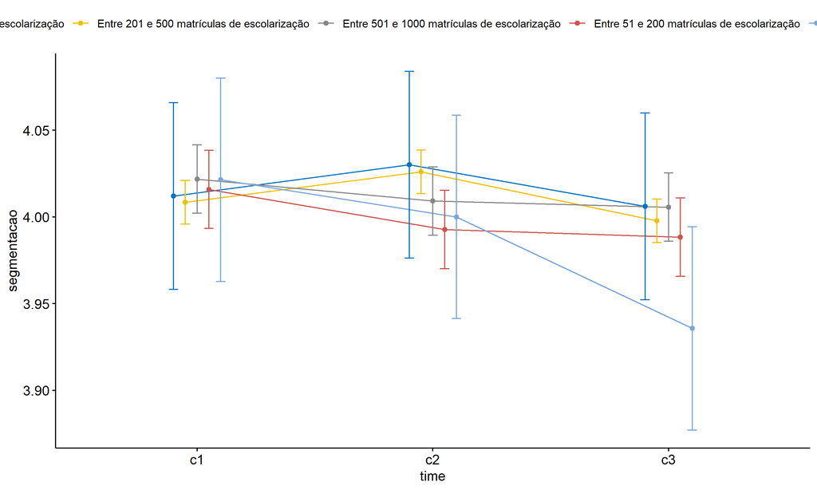

```r
pwc <- add_xy_position(pwc, x = "time", fun = "mean_se", dodge = 0.25)
pd <- position_dodge(width = 0.25)
ggline(emms, x = "time", y = "emmean", color = "porte",
       palette = c("#0073C2FF","#EFC000FF","#868686FF","#CD534CFF","#7AA6DCFF"),
       position = pd, ylab = "segmentacao") +
  geom_errorbar(aes(ymin = conf.low, ymax = conf.high, color = porte),
                position = pd, width = 0.2) +
  stat_pvalue_manual(pwc, hide.ns = T, tip.length = F, linetype = 1)
```

```r
(pwc <- ldat %>% group_by(porte) %>%
    emmeans_test(segmentacao ~ time, detailed = T, p.adjust.method = "bonferroni"))
```

```
## # A tibble: 15 × 15
##    porte   term  .y.   group1 group2 null.value estimate      se    df conf.low conf.high statistic       p   p.adj p.adj.signif
##  * <fct>   <chr> <chr> <chr>  <chr>       <dbl>    <dbl>   <dbl> <dbl>    <dbl>     <dbl>     <dbl>   <dbl>   <dbl> <chr>
##  1 Até 50… time  segm… c1     c2              0 -0.0181  0.0388   8304 -0.0942   0.0581      -0.465 0.642   1       ns
##  2 Até 50… time  segm… c1     c3              0  0.00602 0.0388   8304 -0.0701   0.0822       0.155 0.877   1       ns
##  3 Até 50… time  segm… c2     c3              0  0.0241  0.0388   8304 -0.0520   0.100        0.620 0.535   1       ns
##  4 Entre … time  segm… c1     c2              0 -0.0175  0.00905  8304 -0.0352   0.000245    -1.93  0.0532  0.160   ns
##  5 Entre … time  segm… c1     c3              0  0.0107  0.00905  8304 -0.00706  0.0284       1.18  0.238   0.714   ns
##  6 Entre … time  segm… c2     c3              0  0.0282  0.00905  8304  0.0104   0.0459       3.11  0.00185 0.00556 **
##  7 Entre … time  segm… c1     c2              0  0.0127  0.0142   8304 -0.0152   0.0406       0.890 0.373   1       ns
##  8 Entre … time  segm… c1     c3              0  0.0162  0.0142   8304 -0.0117   0.0441       1.14  0.256   0.767   ns
##  9 Entre … time  segm… c2     c3              0  0.00351 0.0142   8304 -0.0244   0.0314       0.246 0.805   1       ns
## 10 Entre … time  segm… c1     c2              0  0.0231  0.0163   8304 -0.00882  0.0550       1.42  0.156   0.468   ns
## 11 Entre … time  segm… c1     c3              0  0.0275  0.0163   8304 -0.00441  0.0594       1.69  0.0912  0.274   ns
## 12 Entre … time  segm… c2     c3              0  0.00440 0.0163   8304 -0.0275   0.0363       0.271 0.787   1       ns
## 13 Mais d… time  segm… c1     c2              0  0.0214  0.0423   8304 -0.0615   0.104        0.507 0.612   1       ns
## 14 Mais d… time  segm… c1     c3              0  0.0857  0.0423   8304  0.00280  0.169        2.03  0.0427  0.128   ns
## 15 Mais d… time  segm… c2     c3              0  0.0643  0.0423   8304 -0.0186   0.147        1.52  0.129   0.386   ns
```

| porte | term | .y. | group1 | group2 | null.value | estimate | se | df | conf.low | conf.high | statistic | p | p.adj | p.adj.signif |
| --- | --- | --- | --- | --- | --- | --- | --- | --- | --- | --- | --- | --- | --- | --- |
| Até 50 matrículas de escolarização | time | segmentacao | c1 | c2 | 0 | -0.018 | 0.039 | 8304 | -0.094 | 0.058 | -0.465 | 0.642 | 1.000 | ns |
| Até 50 matrículas de escolarização | time | segmentacao | c1 | c3 | 0 | 0.006 | 0.039 | 8304 | -0.070 | 0.082 | 0.155 | 0.877 | 1.000 | ns |
| Até 50 matrículas de escolarização | time | segmentacao | c2 | c3 | 0 | 0.024 | 0.039 | 8304 | -0.052 | 0.100 | 0.620 | 0.535 | 1.000 | ns |
| Entre 201 e 500 matrículas de escolarização | time | segmentacao | c1 | c2 | 0 | -0.017 | 0.009 | 8304 | -0.035 | 0.000 | -1.933 | 0.053 | 0.160 | ns |
| Entre 201 e 500 matrículas de escolarização | time | segmentacao | c1 | c3 | 0 | 0.011 | 0.009 | 8304 | -0.007 | 0.028 | 1.180 | 0.238 | 0.714 | ns |
| Entre 201 e 500 matrículas de escolarização | time | segmentacao | c2 | c3 | 0 | 0.028 | 0.009 | 8304 | 0.010 | 0.046 | 3.114 | 0.002 | 0.006 | ** |
| Entre 501 e 1000 matrículas de escolarização | time | segmentacao | c1 | c2 | 0 | 0.013 | 0.014 | 8304 | -0.015 | 0.041 | 0.890 | 0.373 | 1.000 | ns |
| Entre 501 e 1000 matrículas de escolarização | time | segmentacao | c1 | c3 | 0 | 0.016 | 0.014 | 8304 | -0.012 | 0.044 | 1.137 | 0.256 | 0.767 | ns |
| Entre 501 e 1000 matrículas de escolarização | time | segmentacao | c2 | c3 | 0 | 0.004 | 0.014 | 8304 | -0.024 | 0.031 | 0.246 | 0.805 | 1.000 | ns |
| Entre 51 e 200 matrículas de escolarização | time | segmentacao | c1 | c2 | 0 | 0.023 | 0.016 | 8304 | -0.009 | 0.055 | 1.418 | 0.156 | 0.468 | ns |
| Entre 51 e 200 matrículas de escolarização | time | segmentacao | c1 | c3 | 0 | 0.027 | 0.016 | 8304 | -0.004 | 0.059 | 1.689 | 0.091 | 0.274 | ns |
| Entre 51 e 200 matrículas de escolarização | time | segmentacao | c2 | c3 | 0 | 0.004 | 0.016 | 8304 | -0.027 | 0.036 | 0.271 | 0.787 | 1.000 | ns |
| Mais de 1000 matrículas de escolarização | time | segmentacao | c1 | c2 | 0 | 0.021 | 0.042 | 8304 | -0.061 | 0.104 | 0.507 | 0.612 | 1.000 | ns |
| Mais de 1000 matrículas de escolarização | time | segmentacao | c1 | c3 | 0 | 0.086 | 0.042 | 8304 | 0.003 | 0.169 | 2.027 | 0.043 | 0.128 | ns |
| Mais de 1000 matrículas de escolarização | time | segmentacao | c2 | c3 | 0 | 0.064 | 0.042 | 8304 | -0.019 | 0.147 | 1.520 | 0.129 | 0.386 | ns |

```r
(emms <- get_emmeans(pwc))
```

```
## # A tibble: 15 × 8
##    porte                                        time  emmean      se    df conf.low conf.high method
##    <fct>                                        <fct>  <dbl>   <dbl> <dbl>    <dbl>     <dbl> <chr>
##  1 Até 50 matrículas de escolarização           c1      4.01 0.0275   8304     3.96      4.07 Emmeans test
##  2 Até 50 matrículas de escolarização           c2      4.03 0.0275   8304     3.98      4.08 Emmeans test
##  3 Até 50 matrículas de escolarização           c3      4.01 0.0275   8304     3.95      4.06 Emmeans test
##  4 Entre 201 e 500 matrículas de escolarização  c1      4.01 0.00640  8304     4.00      4.02 Emmeans test
##  5 Entre 201 e 500 matrículas de escolarização  c2      4.03 0.00640  8304     4.01      4.04 Emmeans test
##  6 Entre 201 e 500 matrículas de escolarização  c3      4.00 0.00640  8304     3.99      4.01 Emmeans test
##  7 Entre 501 e 1000 matrículas de escolarização c1      4.02 0.0101   8304     4.00      4.04 Emmeans test
##  8 Entre 501 e 1000 matrículas de escolarização c2      4.01 0.0101   8304     3.99      4.03 Emmeans test
##  9 Entre 501 e 1000 matrículas de escolarização c3      4.01 0.0101   8304     3.99      4.03 Emmeans test
## 10 Entre 51 e 200 matrículas de escolarização   c1      4.02 0.0115   8304     3.99      4.04 Emmeans test
## 11 Entre 51 e 200 matrículas de escolarização   c2      3.99 0.0115   8304     3.97      4.02 Emmeans test
## 12 Entre 51 e 200 matrículas de escolarização   c3      3.99 0.0115   8304     3.97      4.01 Emmeans test
## 13 Mais de 1000 matrículas de escolarização     c1      4.02 0.0299   8304     3.96      4.08 Emmeans test
## 14 Mais de 1000 matrículas de escolarização     c2      4.00 0.0299   8304     3.94      4.06 Emmeans test
## 15 Mais de 1000 matrículas de escolarização     c3      3.94 0.0299   8304     3.88      3.99 Emmeans test
```

| porte | time | emmean | se | df | conf.low | conf.high | method |
| --- | --- | --- | --- | --- | --- | --- | --- |
| Até 50 matrículas de escolarização | c1 | 4.012 | 0.027 | 8304 | 3.958 | 4.066 | Emmeans test |
| Até 50 matrículas de escolarização | c2 | 4.030 | 0.027 | 8304 | 3.976 | 4.084 | Emmeans test |
| Até 50 matrículas de escolarização | c3 | 4.006 | 0.027 | 8304 | 3.952 | 4.060 | Emmeans test |
| Entre 201 e 500 matrículas de escolarização | c1 | 4.009 | 0.006 | 8304 | 3.996 | 4.021 | Emmeans test |
| Entre 201 e 500 matrículas de escolarização | c2 | 4.026 | 0.006 | 8304 | 4.013 | 4.039 | Emmeans test |
| Entre 201 e 500 matrículas de escolarização | c3 | 3.998 | 0.006 | 8304 | 3.985 | 4.010 | Emmeans test |
| Entre 501 e 1000 matrículas de escolarização | c1 | 4.022 | 0.010 | 8304 | 4.002 | 4.042 | Emmeans test |
| Entre 501 e 1000 matrículas de escolarização | c2 | 4.009 | 0.010 | 8304 | 3.989 | 4.029 | Emmeans test |
| Entre 501 e 1000 matrículas de escolarização | c3 | 4.006 | 0.010 | 8304 | 3.986 | 4.025 | Emmeans test |
| Entre 51 e 200 matrículas de escolarização | c1 | 4.016 | 0.012 | 8304 | 3.993 | 4.038 | Emmeans test |
| Entre 51 e 200 matrículas de escolarização | c2 | 3.993 | 0.012 | 8304 | 3.970 | 4.015 | Emmeans test |
| Entre 51 e 200 matrículas de escolarização | c3 | 3.988 | 0.012 | 8304 | 3.966 | 4.011 | Emmeans test |
| Mais de 1000 matrículas de escolarização | c1 | 4.021 | 0.030 | 8304 | 3.963 | 4.080 | Emmeans test |
| Mais de 1000 matrículas de escolarização | c2 | 4.000 | 0.030 | 8304 | 3.941 | 4.059 | Emmeans test |
| Mais de 1000 matrículas de escolarização | c3 | 3.936 | 0.030 | 8304 | 3.877 | 3.994 | Emmeans test |

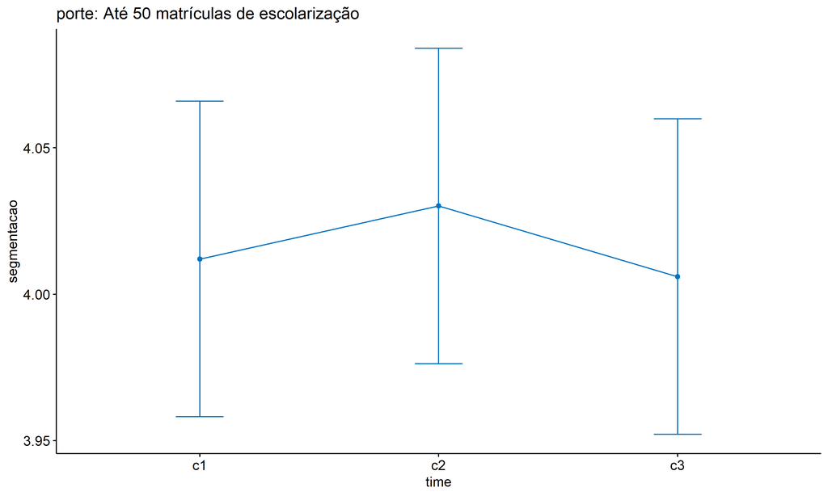

```r
emms.gg <- emms[which(emms$porte == "Até 50 matrículas de escolarização"),]
if (nrow(emms.gg) > 0)
  ggline(emms.gg, x = "time", y = "emmean", color = "#0073C2FF", ylab = "segmentacao") +
    geom_errorbar(aes(ymin = conf.low, ymax = conf.high),
                  width = 0.2, color = "#0073C2FF") +
    stat_pvalue_manual(
      add_xy_position(pwc[which(pwc$porte == "Até 50 matrículas de escolarização"),],
                      x = "time", fun = "mean_se"),
      hide.ns = T, color = "#0073C2FF", tip.length = F) +
    labs(title = "porte: Até 50 matrículas de escolarização")+
    theme(legend.text = element_blank())
```

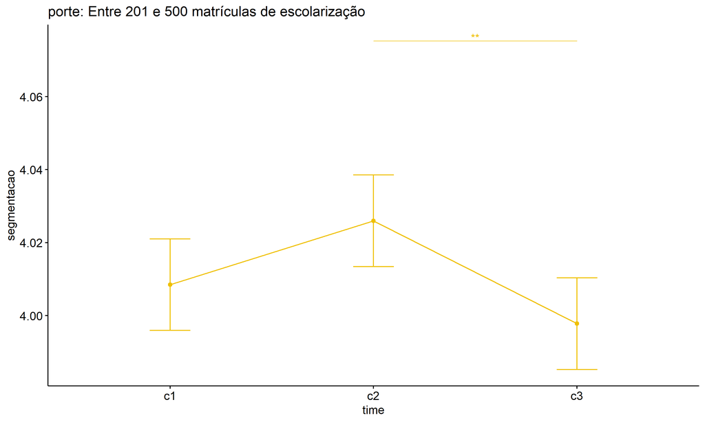

```r
emms.gg <- emms[which(emms$porte == "Entre 201 e 500 matrículas de escolarização"),]
if (nrow(emms.gg) > 0)
  ggline(emms.gg, x = "time", y = "emmean", color = "#EFC000FF", ylab = "segmentacao") +
    geom_errorbar(aes(ymin = conf.low, ymax = conf.high),
                  width = 0.2, color = "#EFC000FF") +
    stat_pvalue_manual(
      add_xy_position(pwc[which(pwc$porte == "Entre 201 e 500 matrículas de escolarização"),],
                      x = "time", fun = "mean_se"),
      hide.ns = T, color = "#EFC000FF", tip.length = F) +
    labs(title = "porte: Entre 201 e 500 matrículas de escolarização")+
    theme(legend.text = element_blank())
```

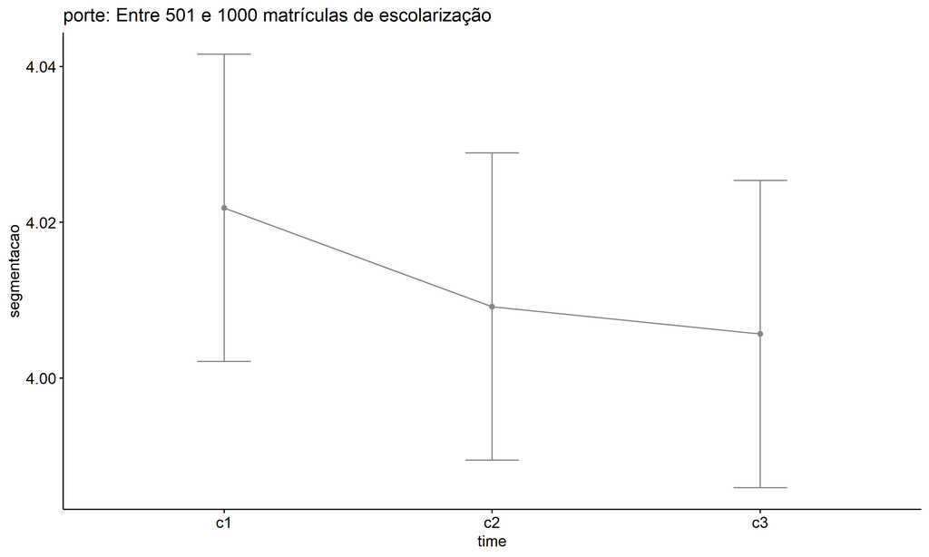

```r
emms.gg <- emms[which(emms$porte == "Entre 501 e 1000 matrículas de escolarização"),]
if (nrow(emms.gg) > 0)
  ggline(emms.gg, x = "time", y = "emmean", color = "#868686FF", ylab = "segmentacao") +
    geom_errorbar(aes(ymin = conf.low, ymax = conf.high),
                  width = 0.2, color = "#868686FF") +
    stat_pvalue_manual(
      add_xy_position(pwc[which(pwc$porte == "Entre 501 e 1000 matrículas de escolarização"),],
                      x = "time", fun = "mean_se"),
      hide.ns = T, color = "#868686FF", tip.length = F) +
    labs(title = "porte: Entre 501 e 1000 matrículas de escolarização")+
    theme(legend.text = element_blank())
```

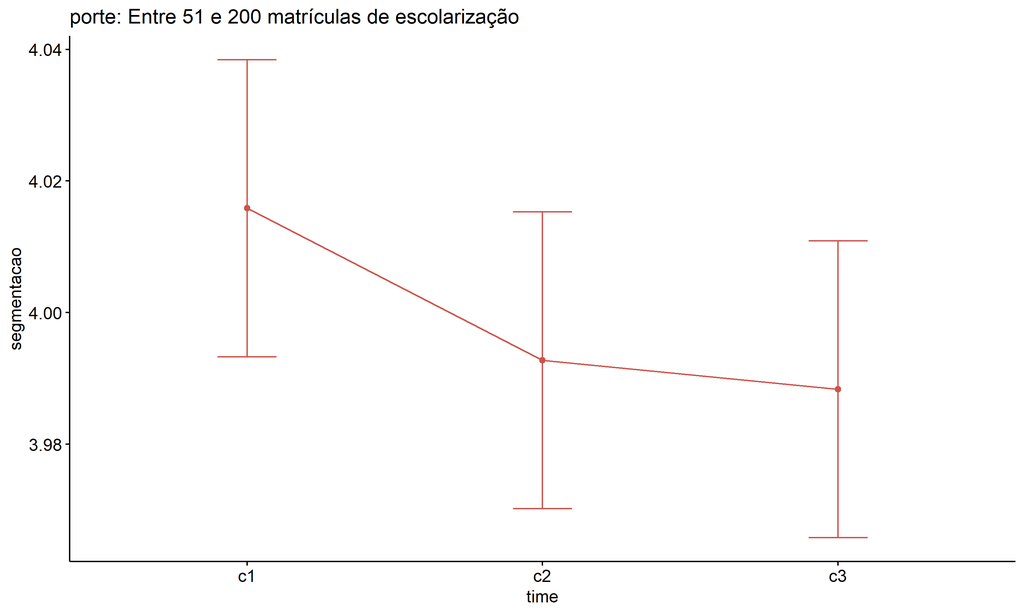

```r
emms.gg <- emms[which(emms$porte == "Entre 51 e 200 matrículas de escolarização"),]
if (nrow(emms.gg) > 0)
  ggline(emms.gg, x = "time", y = "emmean", color = "#CD534CFF", ylab = "segmentacao") +
    geom_errorbar(aes(ymin = conf.low, ymax = conf.high),
                  width = 0.2, color = "#CD534CFF") +
    stat_pvalue_manual(
      add_xy_position(pwc[which(pwc$porte == "Entre 51 e 200 matrículas de escolarização"),],
                      x = "time", fun = "mean_se"),
      hide.ns = T, color = "#CD534CFF", tip.length = F) +
    labs(title = "porte: Entre 51 e 200 matrículas de escolarização")+
    theme(legend.text = element_blank())
```

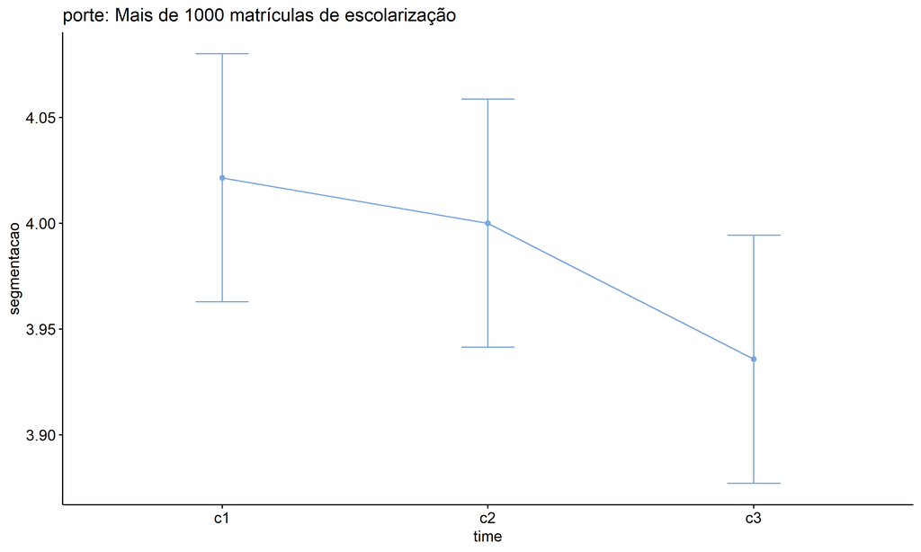

```r
emms.gg <- emms[which(emms$porte == "Mais de 1000 matrículas de escolarização"),]
if (nrow(emms.gg) > 0)
  ggline(emms.gg, x = "time", y = "emmean", color = "#7AA6DCFF", ylab = "segmentacao") +
    geom_errorbar(aes(ymin = conf.low, ymax = conf.high),
                  width = 0.2, color = "#7AA6DCFF") +
    stat_pvalue_manual(
      add_xy_position(pwc[which(pwc$porte == "Mais de 1000 matrículas de escolarização"),],
                      x = "time", fun = "mean_se"),
      hide.ns = T, color = "#7AA6DCFF", tip.length = F) +
    labs(title = "porte: Mais de 1000 matrículas de escolarização")+
    theme(legend.text = element_blank())
```

## PairWise Computation after removing non.normal data

```r
if (length(non.ids) > 0)
  (pwc2 <- ldat2 %>% group_by(time) %>%
     emmeans_test(segmentacao ~ porte, detailed = T, p.adjust.method = "bonferroni"))
```

```
## # A tibble: 30 × 15
##    time  term  .y.         group1  group2 null.value estimate     se    df conf.low conf.high statistic     p p.adj p.adj.signif
##  * <fct> <chr> <chr>       <chr>   <chr>       <dbl>    <dbl>  <dbl> <dbl>    <dbl>     <dbl>     <dbl> <dbl> <dbl> <chr>
##  1 c1    porte segmentacao Até 50… Entre…          0  0.00384 0.0284  8289  -0.0519   0.0595      0.135 0.892     1 ns
##  2 c1    porte segmentacao Até 50… Entre…          0 -0.00950 0.0294  8289  -0.0672   0.0482     -0.323 0.747     1 ns
##  3 c1    porte segmentacao Até 50… Entre…          0 -0.00351 0.0300  8289  -0.0623   0.0552     -0.117 0.907     1 ns
##  4 c1    porte segmentacao Até 50… Mais …          0 -0.0250  0.0412  8289  -0.106    0.0557     -0.607 0.544     1 ns
##  5 c1    porte segmentacao Entre … Entre…          0 -0.0133  0.0119  8289  -0.0366   0.00994    -1.12  0.261     1 ns
##  6 c1    porte segmentacao Entre … Entre…          0 -0.00735 0.0131  8289  -0.0331   0.0183     -0.561 0.575     1 ns
##  7 c1    porte segmentacao Entre … Mais …          0 -0.0288  0.0311  8289  -0.0898   0.0322     -0.926 0.354     1 ns
##  8 c1    porte segmentacao Entre … Entre…          0  0.00599 0.0152  8289  -0.0239   0.0358      0.393 0.694     1 ns
##  9 c1    porte segmentacao Entre … Mais …          0 -0.0155  0.0321  8289  -0.0783   0.0474     -0.483 0.629     1 ns
## 10 c1    porte segmentacao Entre … Mais …          0 -0.0215  0.0325  8289  -0.0852   0.0423     -0.660 0.510     1 ns
## # ℹ 20 more rows
```

| time | term | .y. | group1 | group2 | null.value | estimate | se | df | conf.low | conf.high | statistic | p | p.adj | p.adj.signif |
| --- | --- | --- | --- | --- | --- | --- | --- | --- | --- | --- | --- | --- | --- | --- |
| c1 | porte | segmentacao | Até 50 matrículas de escolarização | Entre 201 e 500 matrículas de escolarização | 0 | 0.004 | 0.028 | 8289 | -0.052 | 0.060 | 0.135 | 0.892 | 1.000 | ns |
| c1 | porte | segmentacao | Até 50 matrículas de escolarização | Entre 501 e 1000 matrículas de escolarização | 0 | -0.009 | 0.029 | 8289 | -0.067 | 0.048 | -0.323 | 0.747 | 1.000 | ns |
| c1 | porte | segmentacao | Até 50 matrículas de escolarização | Entre 51 e 200 matrículas de escolarização | 0 | -0.004 | 0.030 | 8289 | -0.062 | 0.055 | -0.117 | 0.907 | 1.000 | ns |
| c1 | porte | segmentacao | Até 50 matrículas de escolarização | Mais de 1000 matrículas de escolarização | 0 | -0.025 | 0.041 | 8289 | -0.106 | 0.056 | -0.607 | 0.544 | 1.000 | ns |
| c1 | porte | segmentacao | Entre 201 e 500 matrículas de escolarização | Entre 501 e 1000 matrículas de escolarização | 0 | -0.013 | 0.012 | 8289 | -0.037 | 0.010 | -1.123 | 0.261 | 1.000 | ns |
| c1 | porte | segmentacao | Entre 201 e 500 matrículas de escolarização | Entre 51 e 200 matrículas de escolarização | 0 | -0.007 | 0.013 | 8289 | -0.033 | 0.018 | -0.561 | 0.575 | 1.000 | ns |
| c1 | porte | segmentacao | Entre 201 e 500 matrículas de escolarização | Mais de 1000 matrículas de escolarização | 0 | -0.029 | 0.031 | 8289 | -0.090 | 0.032 | -0.926 | 0.354 | 1.000 | ns |
| c1 | porte | segmentacao | Entre 501 e 1000 matrículas de escolarização | Entre 51 e 200 matrículas de escolarização | 0 | 0.006 | 0.015 | 8289 | -0.024 | 0.036 | 0.393 | 0.694 | 1.000 | ns |
| c1 | porte | segmentacao | Entre 501 e 1000 matrículas de escolarização | Mais de 1000 matrículas de escolarização | 0 | -0.015 | 0.032 | 8289 | -0.078 | 0.047 | -0.483 | 0.629 | 1.000 | ns |
| c1 | porte | segmentacao | Entre 51 e 200 matrículas de escolarização | Mais de 1000 matrículas de escolarização | 0 | -0.021 | 0.033 | 8289 | -0.085 | 0.042 | -0.660 | 0.510 | 1.000 | ns |
| c2 | porte | segmentacao | Até 50 matrículas de escolarização | Entre 201 e 500 matrículas de escolarização | 0 | 0.017 | 0.028 | 8289 | -0.038 | 0.073 | 0.606 | 0.545 | 1.000 | ns |
| c2 | porte | segmentacao | Até 50 matrículas de escolarização | Entre 501 e 1000 matrículas de escolarização | 0 | 0.034 | 0.029 | 8289 | -0.024 | 0.092 | 1.156 | 0.248 | 1.000 | ns |
| c2 | porte | segmentacao | Até 50 matrículas de escolarização | Entre 51 e 200 matrículas de escolarização | 0 | 0.050 | 0.030 | 8289 | -0.008 | 0.109 | 1.683 | 0.092 | 0.924 | ns |
| c2 | porte | segmentacao | Até 50 matrículas de escolarização | Mais de 1000 matrículas de escolarização | 0 | 0.043 | 0.041 | 8289 | -0.037 | 0.124 | 1.050 | 0.294 | 1.000 | ns |
| c2 | porte | segmentacao | Entre 201 e 500 matrículas de escolarização | Entre 501 e 1000 matrículas de escolarização | 0 | 0.017 | 0.012 | 8289 | -0.006 | 0.040 | 1.417 | 0.157 | 1.000 | ns |
| c2 | porte | segmentacao | Entre 201 e 500 matrículas de escolarização | Entre 51 e 200 matrículas de escolarização | 0 | 0.033 | 0.013 | 8289 | 0.008 | 0.059 | 2.534 | 0.011 | 0.113 | ns |
| c2 | porte | segmentacao | Entre 201 e 500 matrículas de escolarização | Mais de 1000 matrículas de escolarização | 0 | 0.026 | 0.031 | 8289 | -0.035 | 0.087 | 0.836 | 0.403 | 1.000 | ns |
| c2 | porte | segmentacao | Entre 501 e 1000 matrículas de escolarização | Entre 51 e 200 matrículas de escolarização | 0 | 0.016 | 0.015 | 8289 | -0.013 | 0.046 | 1.077 | 0.282 | 1.000 | ns |
| c2 | porte | segmentacao | Entre 501 e 1000 matrículas de escolarização | Mais de 1000 matrículas de escolarização | 0 | 0.009 | 0.032 | 8289 | -0.054 | 0.072 | 0.286 | 0.775 | 1.000 | ns |
| c2 | porte | segmentacao | Entre 51 e 200 matrículas de escolarização | Mais de 1000 matrículas de escolarização | 0 | -0.007 | 0.033 | 8289 | -0.071 | 0.057 | -0.222 | 0.824 | 1.000 | ns |
| c3 | porte | segmentacao | Até 50 matrículas de escolarização | Entre 201 e 500 matrículas de escolarização | 0 | -0.004 | 0.028 | 8289 | -0.060 | 0.052 | -0.141 | 0.888 | 1.000 | ns |
| c3 | porte | segmentacao | Até 50 matrículas de escolarização | Entre 501 e 1000 matrículas de escolarização | 0 | -0.012 | 0.029 | 8289 | -0.070 | 0.046 | -0.402 | 0.688 | 1.000 | ns |
| c3 | porte | segmentacao | Até 50 matrículas de escolarização | Entre 51 e 200 matrículas de escolarização | 0 | 0.005 | 0.030 | 8289 | -0.053 | 0.064 | 0.182 | 0.856 | 1.000 | ns |
| c3 | porte | segmentacao | Até 50 matrículas de escolarização | Mais de 1000 matrículas de escolarização | 0 | 0.061 | 0.041 | 8289 | -0.020 | 0.142 | 1.482 | 0.138 | 1.000 | ns |
| c3 | porte | segmentacao | Entre 201 e 500 matrículas de escolarização | Entre 501 e 1000 matrículas de escolarização | 0 | -0.008 | 0.012 | 8289 | -0.031 | 0.015 | -0.660 | 0.509 | 1.000 | ns |
| c3 | porte | segmentacao | Entre 201 e 500 matrículas de escolarização | Entre 51 e 200 matrículas de escolarização | 0 | 0.009 | 0.013 | 8289 | -0.016 | 0.035 | 0.721 | 0.471 | 1.000 | ns |
| c3 | porte | segmentacao | Entre 201 e 500 matrículas de escolarização | Mais de 1000 matrículas de escolarização | 0 | 0.065 | 0.031 | 8289 | 0.004 | 0.126 | 2.089 | 0.037 | 0.367 | ns |
| c3 | porte | segmentacao | Entre 501 e 1000 matrículas de escolarização | Entre 51 e 200 matrículas de escolarização | 0 | 0.017 | 0.015 | 8289 | -0.013 | 0.047 | 1.136 | 0.256 | 1.000 | ns |
| c3 | porte | segmentacao | Entre 501 e 1000 matrículas de escolarização | Mais de 1000 matrículas de escolarização | 0 | 0.073 | 0.032 | 8289 | 0.010 | 0.136 | 2.272 | 0.023 | 0.231 | ns |
| c3 | porte | segmentacao | Entre 51 e 200 matrículas de escolarização | Mais de 1000 matrículas de escolarização | 0 | 0.056 | 0.033 | 8289 | -0.008 | 0.119 | 1.707 | 0.088 | 0.878 | ns |

```r
if (length(non.ids) > 0)
  (emms2 <- get_emmeans(pwc2))
```

```
## # A tibble: 15 × 8
##    time  porte                                        emmean      se    df conf.low conf.high method
##    <fct> <fct>                                         <dbl>   <dbl> <dbl>    <dbl>     <dbl> <chr>
##  1 c1    Até 50 matrículas de escolarização             4.01 0.0277   8289     3.96      4.07 Emmeans test
##  2 c1    Entre 201 e 500 matrículas de escolarização    4.01 0.00637  8289     4.00      4.02 Emmeans test
##  3 c1    Entre 501 e 1000 matrículas de escolarização   4.02 0.0100   8289     4.00      4.04 Emmeans test
##  4 c1    Entre 51 e 200 matrículas de escolarização     4.02 0.0115   8289     3.99      4.04 Emmeans test
##  5 c1    Mais de 1000 matrículas de escolarização       4.04 0.0304   8289     3.98      4.10 Emmeans test
##  6 c2    Até 50 matrículas de escolarização             4.04 0.0277   8289     3.99      4.10 Emmeans test
##  7 c2    Entre 201 e 500 matrículas de escolarização    4.03 0.00637  8289     4.01      4.04 Emmeans test
##  8 c2    Entre 501 e 1000 matrículas de escolarização   4.01 0.0100   8289     3.99      4.03 Emmeans test
##  9 c2    Entre 51 e 200 matrículas de escolarização     3.99 0.0115   8289     3.97      4.02 Emmeans test
## 10 c2    Mais de 1000 matrículas de escolarização       4.00 0.0304   8289     3.94      4.06 Emmeans test
## 11 c3    Até 50 matrículas de escolarização             3.99 0.0277   8289     3.94      4.05 Emmeans test
## 12 c3    Entre 201 e 500 matrículas de escolarização    4.00 0.00637  8289     3.99      4.01 Emmeans test
## 13 c3    Entre 501 e 1000 matrículas de escolarização   4.01 0.0100   8289     3.99      4.03 Emmeans test
## 14 c3    Entre 51 e 200 matrículas de escolarização     3.99 0.0115   8289     3.97      4.01 Emmeans test
## 15 c3    Mais de 1000 matrículas de escolarização       3.93 0.0304   8289     3.87      3.99 Emmeans test
```

| time | porte | emmean | se | df | conf.low | conf.high | method |
| --- | --- | --- | --- | --- | --- | --- | --- |
| c1 | Até 50 matrículas de escolarização | 4.012 | 0.028 | 8289 | 3.958 | 4.067 | Emmeans test |
| c1 | Entre 201 e 500 matrículas de escolarização | 4.009 | 0.006 | 8289 | 3.996 | 4.021 | Emmeans test |
| c1 | Entre 501 e 1000 matrículas de escolarização | 4.022 | 0.010 | 8289 | 4.002 | 4.041 | Emmeans test |
| c1 | Entre 51 e 200 matrículas de escolarização | 4.016 | 0.011 | 8289 | 3.993 | 4.038 | Emmeans test |
| c1 | Mais de 1000 matrículas de escolarização | 4.037 | 0.030 | 8289 | 3.978 | 4.097 | Emmeans test |
| c2 | Até 50 matrículas de escolarização | 4.043 | 0.028 | 8289 | 3.989 | 4.097 | Emmeans test |
| c2 | Entre 201 e 500 matrículas de escolarização | 4.026 | 0.006 | 8289 | 4.014 | 4.038 | Emmeans test |
| c2 | Entre 501 e 1000 matrículas de escolarização | 4.009 | 0.010 | 8289 | 3.990 | 4.029 | Emmeans test |
| c2 | Entre 51 e 200 matrículas de escolarização | 3.993 | 0.011 | 8289 | 3.970 | 4.015 | Emmeans test |
| c2 | Mais de 1000 matrículas de escolarização | 4.000 | 0.030 | 8289 | 3.940 | 4.060 | Emmeans test |
| c3 | Até 50 matrículas de escolarização | 3.994 | 0.028 | 8289 | 3.940 | 4.048 | Emmeans test |
| c3 | Entre 201 e 500 matrículas de escolarização | 3.998 | 0.006 | 8289 | 3.985 | 4.010 | Emmeans test |
| c3 | Entre 501 e 1000 matrículas de escolarização | 4.006 | 0.010 | 8289 | 3.986 | 4.025 | Emmeans test |
| c3 | Entre 51 e 200 matrículas de escolarização | 3.988 | 0.011 | 8289 | 3.966 | 4.011 | Emmeans test |
| c3 | Mais de 1000 matrículas de escolarização | 3.933 | 0.030 | 8289 | 3.873 | 3.993 | Emmeans test |

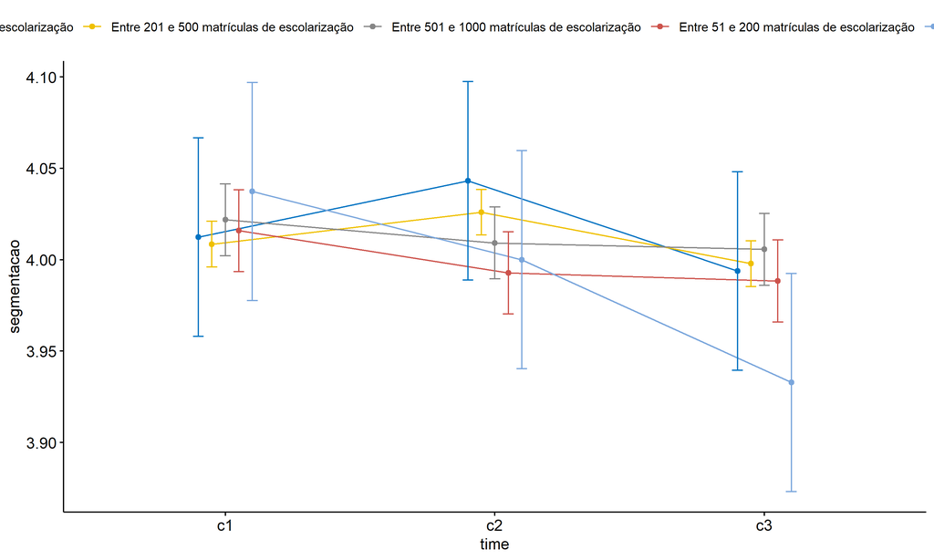

```r
if (length(non.ids) > 0) {
  pwc2 <- add_xy_position(pwc2, x = "time", fun = "mean_se", dodge = 0.25)
  pd2 <- position_dodge(width = 0.25)

  ggline(emms2, x = "time", y = "emmean", color = "porte",
         palette = c("#0073C2FF","#EFC000FF","#868686FF","#CD534CFF","#7AA6DCFF"),
         position = pd, ylab = "segmentacao") +
    geom_errorbar(aes(ymin = conf.low, ymax = conf.high, color = porte),
                position = pd, width = 0.2) +
    stat_pvalue_manual(pwc2, hide.ns = T, tip.length = F, linetype = 1)
}
```

```r
if (length(non.ids) > 0)
  (pwc2 <- ldat2 %>% group_by(porte) %>%
     emmeans_test(segmentacao ~ time, detailed = T, p.adjust.method = "bonferroni"))
```

```
## # A tibble: 15 × 15
##    porte   term  .y.   group1 group2 null.value estimate      se    df conf.low conf.high statistic       p   p.adj p.adj.signif
##  * <fct>   <chr> <chr> <chr>  <chr>       <dbl>    <dbl>   <dbl> <dbl>    <dbl>     <dbl>     <dbl>   <dbl>   <dbl> <chr>
##  1 Até 50… time  segm… c1     c2              0 -0.0309  0.0392   8289 -0.108    0.0459      -0.788 0.431   1       ns
##  2 Até 50… time  segm… c1     c3              0  0.0185  0.0392   8289 -0.0582   0.0953       0.473 0.636   1       ns
##  3 Até 50… time  segm… c2     c3              0  0.0494  0.0392   8289 -0.0274   0.126        1.26  0.207   0.622   ns
##  4 Entre … time  segm… c1     c2              0 -0.0175  0.00901  8289 -0.0352   0.000173    -1.94  0.0523  0.157   ns
##  5 Entre … time  segm… c1     c3              0  0.0107  0.00901  8289 -0.00699  0.0284       1.19  0.236   0.708   ns
##  6 Entre … time  segm… c2     c3              0  0.0282  0.00901  8289  0.0105   0.0458       3.13  0.00178 0.00533 **
##  7 Entre … time  segm… c1     c2              0  0.0127  0.0142   8289 -0.0151   0.0405       0.894 0.371   1       ns
##  8 Entre … time  segm… c1     c3              0  0.0162  0.0142   8289 -0.0116   0.0440       1.14  0.254   0.761   ns
##  9 Entre … time  segm… c2     c3              0  0.00351 0.0142   8289 -0.0243   0.0313       0.247 0.805   1       ns
## 10 Entre … time  segm… c1     c2              0  0.0231  0.0162   8289 -0.00869  0.0548       1.42  0.154   0.463   ns
## 11 Entre … time  segm… c1     c3              0  0.0275  0.0162   8289 -0.00428  0.0593       1.70  0.0899  0.270   ns
## 12 Entre … time  segm… c2     c3              0  0.00440 0.0162   8289 -0.0274   0.0362       0.272 0.786   1       ns
## 13 Mais d… time  segm… c1     c2              0  0.0373  0.0431   8289 -0.0471   0.122        0.867 0.386   1       ns
## 14 Mais d… time  segm… c1     c3              0  0.104   0.0431   8289  0.0201   0.189        2.43  0.0153  0.0458  *
## 15 Mais d… time  segm… c2     c3              0  0.0672  0.0431   8289 -0.0172   0.152        1.56  0.119   0.356   ns
```

| porte | term | .y. | group1 | group2 | null.value | estimate | se | df | conf.low | conf.high | statistic | p | p.adj | p.adj.signif |
| --- | --- | --- | --- | --- | --- | --- | --- | --- | --- | --- | --- | --- | --- | --- |
| Até 50 matrículas de escolarização | time | segmentacao | c1 | c2 | 0 | -0.031 | 0.039 | 8289 | -0.108 | 0.046 | -0.788 | 0.431 | 1.000 | ns |
| Até 50 matrículas de escolarização | time | segmentacao | c1 | c3 | 0 | 0.019 | 0.039 | 8289 | -0.058 | 0.095 | 0.473 | 0.636 | 1.000 | ns |
| Até 50 matrículas de escolarização | time | segmentacao | c2 | c3 | 0 | 0.049 | 0.039 | 8289 | -0.027 | 0.126 | 1.261 | 0.207 | 0.622 | ns |
| Entre 201 e 500 matrículas de escolarização | time | segmentacao | c1 | c2 | 0 | -0.017 | 0.009 | 8289 | -0.035 | 0.000 | -1.941 | 0.052 | 0.157 | ns |
| Entre 201 e 500 matrículas de escolarização | time | segmentacao | c1 | c3 | 0 | 0.011 | 0.009 | 8289 | -0.007 | 0.028 | 1.185 | 0.236 | 0.708 | ns |
| Entre 201 e 500 matrículas de escolarização | time | segmentacao | c2 | c3 | 0 | 0.028 | 0.009 | 8289 | 0.011 | 0.046 | 3.126 | 0.002 | 0.005 | ** |
| Entre 501 e 1000 matrículas de escolarização | time | segmentacao | c1 | c2 | 0 | 0.013 | 0.014 | 8289 | -0.015 | 0.040 | 0.894 | 0.371 | 1.000 | ns |
| Entre 501 e 1000 matrículas de escolarização | time | segmentacao | c1 | c3 | 0 | 0.016 | 0.014 | 8289 | -0.012 | 0.044 | 1.141 | 0.254 | 0.761 | ns |
| Entre 501 e 1000 matrículas de escolarização | time | segmentacao | c2 | c3 | 0 | 0.004 | 0.014 | 8289 | -0.024 | 0.031 | 0.247 | 0.805 | 1.000 | ns |
| Entre 51 e 200 matrículas de escolarização | time | segmentacao | c1 | c2 | 0 | 0.023 | 0.016 | 8289 | -0.009 | 0.055 | 1.424 | 0.154 | 0.463 | ns |
| Entre 51 e 200 matrículas de escolarização | time | segmentacao | c1 | c3 | 0 | 0.027 | 0.016 | 8289 | -0.004 | 0.059 | 1.696 | 0.090 | 0.270 | ns |
| Entre 51 e 200 matrículas de escolarização | time | segmentacao | c2 | c3 | 0 | 0.004 | 0.016 | 8289 | -0.027 | 0.036 | 0.272 | 0.786 | 1.000 | ns |
| Mais de 1000 matrículas de escolarização | time | segmentacao | c1 | c2 | 0 | 0.037 | 0.043 | 8289 | -0.047 | 0.122 | 0.867 | 0.386 | 1.000 | ns |
| Mais de 1000 matrículas de escolarização | time | segmentacao | c1 | c3 | 0 | 0.104 | 0.043 | 8289 | 0.020 | 0.189 | 2.426 | 0.015 | 0.046 | * |
| Mais de 1000 matrículas de escolarização | time | segmentacao | c2 | c3 | 0 | 0.067 | 0.043 | 8289 | -0.017 | 0.152 | 1.560 | 0.119 | 0.356 | ns |

```r
if (length(non.ids) > 0)
  (emms2 <- get_emmeans(pwc2))
```

```
## # A tibble: 15 × 8
##    porte                                        time  emmean      se    df conf.low conf.high method
##    <fct>                                        <fct>  <dbl>   <dbl> <dbl>    <dbl>     <dbl> <chr>
##  1 Até 50 matrículas de escolarização           c1      4.01 0.0277   8289     3.96      4.07 Emmeans test
##  2 Até 50 matrículas de escolarização           c2      4.04 0.0277   8289     3.99      4.10 Emmeans test
##  3 Até 50 matrículas de escolarização           c3      3.99 0.0277   8289     3.94      4.05 Emmeans test
##  4 Entre 201 e 500 matrículas de escolarização  c1      4.01 0.00637  8289     4.00      4.02 Emmeans test
##  5 Entre 201 e 500 matrículas de escolarização  c2      4.03 0.00637  8289     4.01      4.04 Emmeans test
##  6 Entre 201 e 500 matrículas de escolarização  c3      4.00 0.00637  8289     3.99      4.01 Emmeans test
##  7 Entre 501 e 1000 matrículas de escolarização c1      4.02 0.0100   8289     4.00      4.04 Emmeans test
##  8 Entre 501 e 1000 matrículas de escolarização c2      4.01 0.0100   8289     3.99      4.03 Emmeans test
##  9 Entre 501 e 1000 matrículas de escolarização c3      4.01 0.0100   8289     3.99      4.03 Emmeans test
## 10 Entre 51 e 200 matrículas de escolarização   c1      4.02 0.0115   8289     3.99      4.04 Emmeans test
## 11 Entre 51 e 200 matrículas de escolarização   c2      3.99 0.0115   8289     3.97      4.02 Emmeans test
## 12 Entre 51 e 200 matrículas de escolarização   c3      3.99 0.0115   8289     3.97      4.01 Emmeans test
## 13 Mais de 1000 matrículas de escolarização     c1      4.04 0.0304   8289     3.98      4.10 Emmeans test
## 14 Mais de 1000 matrículas de escolarização     c2      4.00 0.0304   8289     3.94      4.06 Emmeans test
## 15 Mais de 1000 matrículas de escolarização     c3      3.93 0.0304   8289     3.87      3.99 Emmeans test
```

| porte | time | emmean | se | df | conf.low | conf.high | method |
| --- | --- | --- | --- | --- | --- | --- | --- |
| Até 50 matrículas de escolarização | c1 | 4.012 | 0.028 | 8289 | 3.958 | 4.067 | Emmeans test |
| Até 50 matrículas de escolarização | c2 | 4.043 | 0.028 | 8289 | 3.989 | 4.097 | Emmeans test |
| Até 50 matrículas de escolarização | c3 | 3.994 | 0.028 | 8289 | 3.940 | 4.048 | Emmeans test |
| Entre 201 e 500 matrículas de escolarização | c1 | 4.009 | 0.006 | 8289 | 3.996 | 4.021 | Emmeans test |
| Entre 201 e 500 matrículas de escolarização | c2 | 4.026 | 0.006 | 8289 | 4.014 | 4.038 | Emmeans test |
| Entre 201 e 500 matrículas de escolarização | c3 | 3.998 | 0.006 | 8289 | 3.985 | 4.010 | Emmeans test |
| Entre 501 e 1000 matrículas de escolarização | c1 | 4.022 | 0.010 | 8289 | 4.002 | 4.041 | Emmeans test |
| Entre 501 e 1000 matrículas de escolarização | c2 | 4.009 | 0.010 | 8289 | 3.990 | 4.029 | Emmeans test |
| Entre 501 e 1000 matrículas de escolarização | c3 | 4.006 | 0.010 | 8289 | 3.986 | 4.025 | Emmeans test |
| Entre 51 e 200 matrículas de escolarização | c1 | 4.016 | 0.011 | 8289 | 3.993 | 4.038 | Emmeans test |
| Entre 51 e 200 matrículas de escolarização | c2 | 3.993 | 0.011 | 8289 | 3.970 | 4.015 | Emmeans test |
| Entre 51 e 200 matrículas de escolarização | c3 | 3.988 | 0.011 | 8289 | 3.966 | 4.011 | Emmeans test |
| Mais de 1000 matrículas de escolarização | c1 | 4.037 | 0.030 | 8289 | 3.978 | 4.097 | Emmeans test |
| Mais de 1000 matrículas de escolarização | c2 | 4.000 | 0.030 | 8289 | 3.940 | 4.060 | Emmeans test |
| Mais de 1000 matrículas de escolarização | c3 | 3.933 | 0.030 | 8289 | 3.873 | 3.993 | Emmeans test |

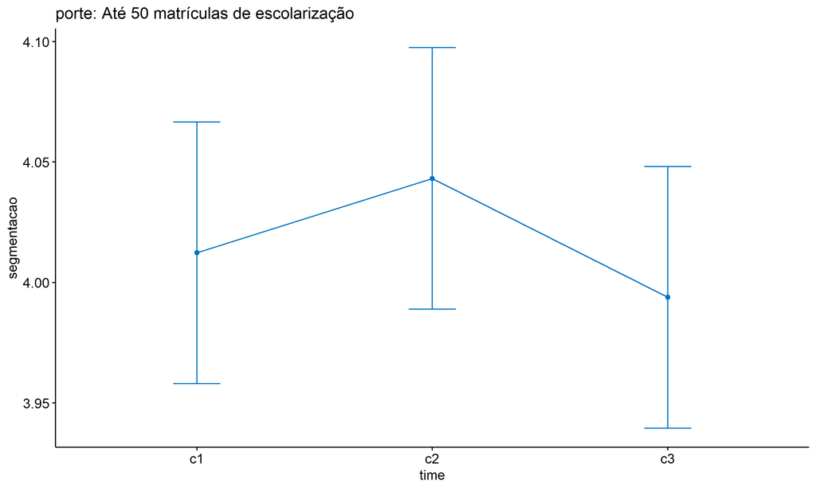

```r
if (length(non.ids) > 0) {
  emms.gg <- emms2[which(emms2$porte == "Até 50 matrículas de escolarização"),]
  if (nrow(emms.gg) > 0)
    ggline(emms.gg, x = "time", y = "emmean", color = "#0073C2FF", ylab = "segmentacao") +
    geom_errorbar(aes(ymin = conf.low, ymax = conf.high),
                  width = 0.2, color = "#0073C2FF") +
    stat_pvalue_manual(
      add_xy_position(pwc[which(pwc$porte == "Até 50 matrículas de escolarização"),],
                      x = "time", fun = "mean_se"),
      hide.ns = T, color = "#0073C2FF", tip.length = F) +
    labs(title = "porte: Até 50 matrículas de escolarização") +
    theme(legend.text = element_blank())
}
```

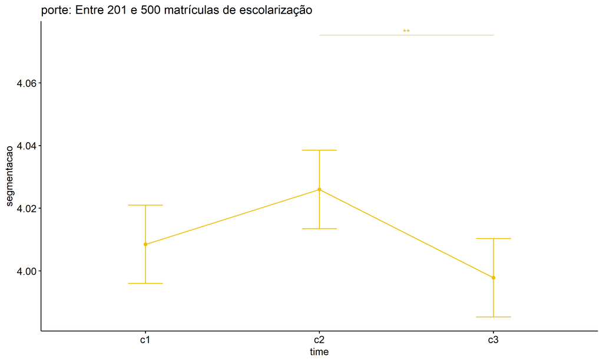

```r
if (length(non.ids) > 0) {
  emms.gg <- emms2[which(emms2$porte == "Entre 201 e 500 matrículas de escolarização"),]
  if (nrow(emms.gg) > 0)
    ggline(emms.gg, x = "time", y = "emmean", color = "#EFC000FF", ylab = "segmentacao") +
    geom_errorbar(aes(ymin = conf.low, ymax = conf.high),
                  width = 0.2, color = "#EFC000FF") +
    stat_pvalue_manual(
      add_xy_position(pwc[which(pwc$porte == "Entre 201 e 500 matrículas de escolarização"),],
                      x = "time", fun = "mean_se"),
      hide.ns = T, color = "#EFC000FF", tip.length = F) +
    labs(title = "porte: Entre 201 e 500 matrículas de escolarização") +
    theme(legend.text = element_blank())
}
```

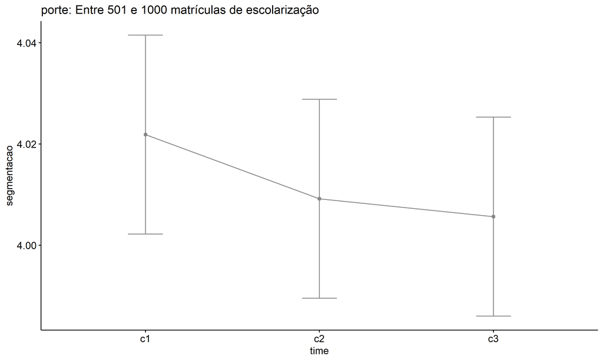

```r
if (length(non.ids) > 0) {
  emms.gg <- emms2[which(emms2$porte == "Entre 501 e 1000 matrículas de escolarização"),]
  if (nrow(emms.gg) > 0)
    ggline(emms.gg, x = "time", y = "emmean", color = "#868686FF", ylab = "segmentacao") +
    geom_errorbar(aes(ymin = conf.low, ymax = conf.high),
                  width = 0.2, color = "#868686FF") +
    stat_pvalue_manual(
      add_xy_position(pwc[which(pwc$porte == "Entre 501 e 1000 matrículas de escolarização"),],
                      x = "time", fun = "mean_se"),
      hide.ns = T, color = "#868686FF", tip.length = F) +
    labs(title = "porte: Entre 501 e 1000 matrículas de escolarização") +
    theme(legend.text = element_blank())
}
```

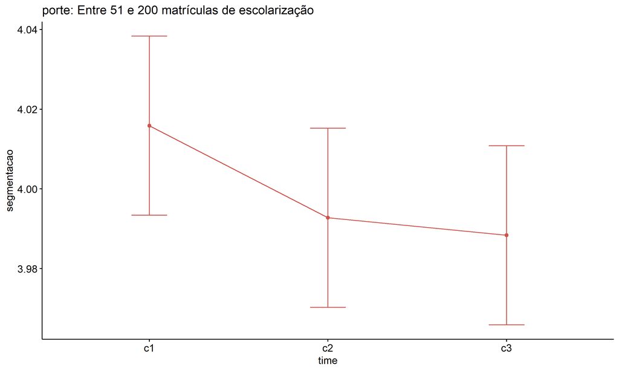

```r
if (length(non.ids) > 0) {
  emms.gg <- emms2[which(emms2$porte == "Entre 51 e 200 matrículas de escolarização"),]
  if (nrow(emms.gg) > 0)
    ggline(emms.gg, x = "time", y = "emmean", color = "#CD534CFF", ylab = "segmentacao") +
    geom_errorbar(aes(ymin = conf.low, ymax = conf.high),
                  width = 0.2, color = "#CD534CFF") +
    stat_pvalue_manual(
      add_xy_position(pwc[which(pwc$porte == "Entre 51 e 200 matrículas de escolarização"),],
                      x = "time", fun = "mean_se"),
      hide.ns = T, color = "#CD534CFF", tip.length = F) +
    labs(title = "porte: Entre 51 e 200 matrículas de escolarização") +
    theme(legend.text = element_blank())
}
```

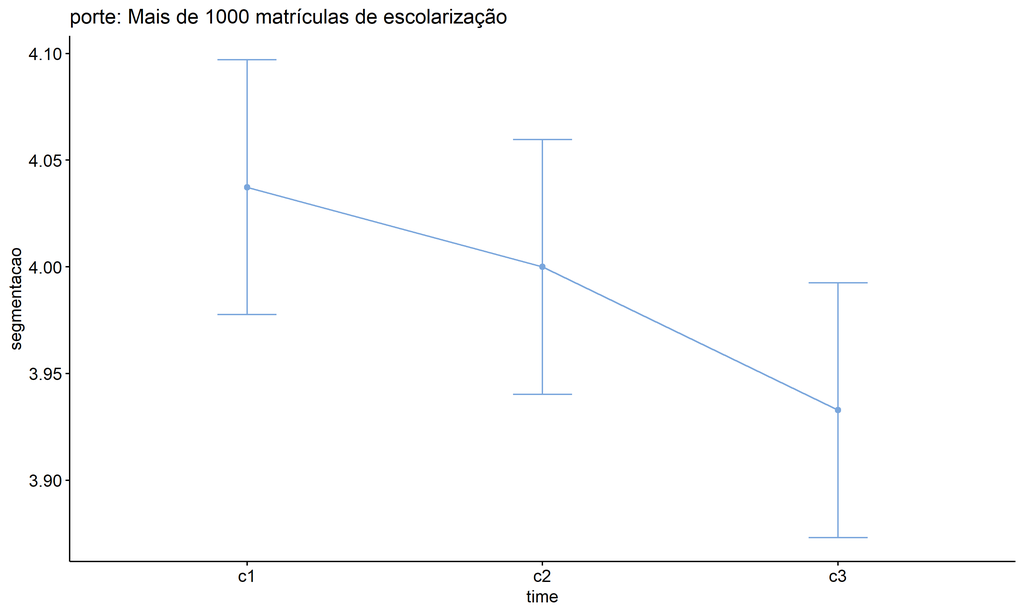

```r
if (length(non.ids) > 0) {
  emms.gg <- emms2[which(emms2$porte == "Mais de 1000 matrículas de escolarização"),]
  if (nrow(emms.gg) > 0)
    ggline(emms.gg, x = "time", y = "emmean", color = "#7AA6DCFF", ylab = "segmentacao") +
    geom_errorbar(aes(ymin = conf.low, ymax = conf.high),
                  width = 0.2, color = "#7AA6DCFF") +
    stat_pvalue_manual(
      add_xy_position(pwc[which(pwc$porte == "Mais de 1000 matrículas de escolarização"),],
                      x = "time", fun = "mean_se"),
      hide.ns = T, color = "#7AA6DCFF", tip.length = F) +
    labs(title = "porte: Mais de 1000 matrículas de escolarização") +
    theme(legend.text = element_blank())
}
```